# Classificação com Naive Bayes

Fellipe Gomes

31 de outubro de 2017

# Introdução

O trabalho proposto foi o seguinte:

Recebem-se diversos documentos em formato PDF que são chamados de ACORDAO. Em cada ACORDAO existe uma sequencia de frases onde cada uma dessas frases estão relacionadas a um desfecho.

Deseja-se avaliar um modelo de classificação com o algorítmo *Naive* Bayes com a finalidade de prever os desfechos de dados futuros.

Após diversos tratamentos da base de cados, pode-se observaro seguinte banco:

```r
dados <- read_csv("C:/Users/Fellipe/Dropbox/RPubs/Projeto Estagio/Apresentacao/classificado_classe_unica_prioridade.csv")
#Transformando a base para fator:
dados=dados[,-1]
dados$classes=as.factor(dados$classes)
dados$key=as.factor(dados$key)
dados$sentence=as.factor(dados$sentence)
dados=as.data.frame(dados)

#Comando para print da base de dados:
kable(dados, "html")%>%
  kable_styling()%>%
  scroll_box(width = "800px", height = "500px")
```

classes

key

sentence

M

ACORDAO-COMPLETO-22628

Pedido de Reexame, em processo de Representação, contra deliberação desta Corte que determinou ao Ministério da Saúde a adoção das medidas necessárias à anulação de Concorrência realizada pelo órgão, devido à quebra de sigilo das propostas de preço.

F

ACORDAO-COMPLETO-22628

Não-apresentação, pela interessada, de elementos suficientes para infirmar os fundamentos da deliberação recorrida.

A

ACORDAO-COMPLETO-22628

Conhecimento.

D

ACORDAO-COMPLETO-22628

Não-provimento.

M

ACORDAO-COMPLETO-1260994

CONCORRÊNCIA Nº 09/2012-00.

O

ACORDAO-COMPLETO-1260994

SERVIÇO DE CONSERVAÇÃO/RECUPERAÇÃO DA RODOVIA BR-290.

P

ACORDAO-COMPLETO-1260994

DESCLASSIFICAÇÃO DE LICITANTE POR FALHAS NAS COMPOSIÇÕES DE CUSTO UNITÁRIO.

T

ACORDAO-COMPLETO-1260994

REPRESENTAÇÃO COM PEDIDO DE MEDIDA CAUTELAR.

E

ACORDAO-COMPLETO-1260994

AGRAVO CONTRA DECISÃO MONOCRÁTICA QUE DETERMINOU A OITIVA.

F

ACORDAO-COMPLETO-1260994

INTEMPESTIVIDADE.

A

ACORDAO-COMPLETO-1260994

NÃO CONHECIMENTO.

R

ACORDAO-COMPLETO-1260994

PROVIDÊNCIAS INTERNAS.

T

ACORDAO-COMPLETO-36561

REPRESENTAÇÃO.

O

ACORDAO-COMPLETO-36561

EDITAL DE CONCORRÊNCIA PARA OBRAS DE ADEQUAÇÃO DA RODOVIA BR-230/PB.

P

ACORDAO-COMPLETO-36561

REGRA RESTRITIVA À COMPETITIVIDADE DO CERTAME.

P

ACORDAO-COMPLETO-36561

DESCUMPRIMENTO DE DELIBERAÇÃO DO TRIBUNAL DE CONTAS DA UNIÃO.

R

ACORDAO-COMPLETO-36561

MULTA.

R

ACORDAO-COMPLETO-36561

DETERMINAÇÃO AO DNIT.

T

ACORDAO-COMPLETO-1261362

DESESTATIZAÇÃO.

O

ACORDAO-COMPLETO-1261362

TERCEIRO E QUARTO ESTÁGIOS DA PRIMEIRA RODADA DE CONCORRÊNCIAS PARA A CONTRATAÇÃO DE INSTALAÇÃO E OPERAÇÃO DE AGÊNCIAS DE CORREIOS FRANQUEADAS (AGFs), SOB O REGIME DE FRANQUIA POSTAL.

P

ACORDAO-COMPLETO-1261362

DESCUMPRIMENTO DO PRAZO PREVISTO NO ART. 9º, PARÁGRAFO ÚNICO, DA IN-TCU 27/1998.

D

ACORDAO-COMPLETO-1261362

APROVAÇÃO DO TERCEIRO ESTÁGIO.

D

ACORDAO-COMPLETO-1261362

APROVAÇÃO COM RESSALVA DO QUARTO ESTÁGIO.

R

ACORDAO-COMPLETO-1261362

CIÊNCIA À ENTIDADE.

R

ACORDAO-COMPLETO-1261362

ENVIO DE CÓPIAS.

R

ACORDAO-COMPLETO-1261362

ARQUIVAMENTO.

0

ACORDAO-COMPLETO-1335718

EMBARGOS DE DECLARAÇÃO.

T

ACORDAO-COMPLETO-1335718

REPRESENTAÇÃO.

M

ACORDAO-COMPLETO-1335718

CONCORRÊNCIA.

P

ACORDAO-COMPLETO-1335718

PRAZO PARA RECEBIMENTO DE PROPOSTAS INFERIOR AO EXIGIDO NA LEI DE LICITAÇÕES.

D

ACORDAO-COMPLETO-1335718

REJEIÇÃO DAS RAZÕES DE JUSTIFICATIVA.

R

ACORDAO-COMPLETO-1335718

MULTA.

F

ACORDAO-COMPLETO-1335718

AUSÊNCIA DE OMISSÃO, OBSCURIDADE E CONTRADIÇÃO.

R

ACORDAO-COMPLETO-1335718

CONHECIMENTO.

R

ACORDAO-COMPLETO-1335718

REJEIÇÃO.

R

ACORDAO-COMPLETO-1335718

CIÊNCIA.

T

ACORDAO-COMPLETO-1211564

REPRESENTAÇÃO ENCAMINHADA PELA OUVIDORIA DO TCU.

P

ACORDAO-COMPLETO-1211564

DISPENSA DE LICITAÇÃO PARA PERMUTA DE IMÓVEL.

P

ACORDAO-COMPLETO-1211564

VIABILIDADE DE COMPETIÇÃO ENTRE PARTICULARES.

D

ACORDAO-COMPLETO-1211564

PROCEDÊNCIA.

R

ACORDAO-COMPLETO-1211564

FIXAÇÃO DE PRAZO PARA ANULAÇÃO DO ATO.

F

ACORDAO-COMPLETO-1211564

1. A dispensa de licitação com base na alínea c do inciso I do art. 17 da Lei n. 8.666/1993 pressupõe que as especificidades do imóvel adquirido sejam essenciais para atingir a finalidade pública à qual ele será destinado, condicionando a sua escolha.

F

ACORDAO-COMPLETO-1211564

2. A permuta de terreno pertencente à entidade da Administração Pública por unidades imobiliárias a serem nele construídas futuramente não se insere na hipótese de dispensa de licitação acima mencionada, devendo ser precedida de procedimento licitatório na modalidade concorrência, uma vez que em tal situação não há falar em imóvel específico que atenda as necessidades do contratante, existindo, portanto, viabilidade de competição entre particulares.

T

ACORDAO-COMPLETO-1187596

REPRESENTAÇÃO.

P

ACORDAO-COMPLETO-1187596

SUPOSTAS IRREGULARIDADES NA CONCORRÊNCIA PÚBLICA 002/2011.

0

ACORDAO-COMPLETO-1187596

SUSPENSÃO DO PROCEDIMENTO LICITATÓRIO.

D

ACORDAO-COMPLETO-1187596

PROCEDÊNCIA DOS FATOS APONTADOS.

0

ACORDAO-COMPLETO-1187596

SOLUÇÃO DE QUASE TODAS AS OCORRÊNCIAS CONSTATADAS.

R

ACORDAO-COMPLETO-1187596

DETERMINAÇÃO.

R

ACORDAO-COMPLETO-1187596

COMUNICAÇÃO.

R

ACORDAO-COMPLETO-1187596

APENSAMENTO DOS AUTOS AO PROCESSO DE MONITORAMENTE QUE VIER A SER CONSTITUÍDO.

S

ACORDAO-COMPLETO-1513581

PEDIDO DE REEXAME.

T

ACORDAO-COMPLETO-1513581

REPRESENTAÇÃO DO MINISTÉRIO PÚBLICO FEDERAL - PROCURADORIA DA REPÚBLICA EM GOIÁS - 2º OFÍCIO DO NÚCLEO DE COMBATE À CORRUPÇÃO.

P

ACORDAO-COMPLETO-1513581

INDÍCIOS DE IRREGULARIDADES NA CONCORRÊNCIA PÚBLICA OBJETO DO EDITAL 785/2009-12 DNIT-GO.

A

ACORDAO-COMPLETO-1513581

CONHECIMENTO DA REPRESENTAÇÃO.

D

ACORDAO-COMPLETO-1513581

PROCEDÊNCIA PARCIAL.

R

ACORDAO-COMPLETO-1513581

CIÊNCIA À CGU PARA VERIFICAR AS IRREGULARIDADES E COMUNICAR AO TCU SOBRE OS RESULTADOS.

0

ACORDAO-COMPLETO-1513581

ACÓRDÃO 1.859/2015 - 1ª CÂMARA.

A

ACORDAO-COMPLETO-1513581

CONHECIMENTO DO RECURSO.

D

ACORDAO-COMPLETO-1513581

PROVIMENTO.

R

ACORDAO-COMPLETO-1513581

ENCAMINHAMENTO DOS AUTOS À SECEX/GO PARA APURAR EVENTUAIS RESPONSABILIDADES DOS SERVIDORES DO DNIT E DAS EMPRESAS ENVOLVIDAS NO CERTAME.

T

ACORDAO-COMPLETO-15460

Denúncia.

P

ACORDAO-COMPLETO-15460

Possíveis irregularidades na Concorrência nº 4/2001 da Empresa de Trens Urbanos de Porto Alegre S.A. - Trensurb.

E

ACORDAO-COMPLETO-15460

Inspeção determinada por decisão anterior.

P

ACORDAO-COMPLETO-15460

Irregularidades decorrentes de restrições ao caráter competitivo do certame, preços orçados superiores aos de mercado e inadequação do orçamento relativo ao fornecimento de sistemas.

R

ACORDAO-COMPLETO-15460

Fixação de prazo para o exato cumprimento da lei, com a anulação da concorrência.

R

ACORDAO-COMPLETO-15460

Determinações.

D

ACORDAO-COMPLETO-15460

Indeferimento de petições.

R

ACORDAO-COMPLETO-15460

Ciência aos Ministros de Estado das Cidades e dos Transportes, à entidade, aos consórcios participantes da licitação, à empresa Andrade Gutierrez S.A., aos Presidentes do Senado Federal, da Câmara dos Deputados, da Comissão Mista de Planos, Orçamentos Públicos e Fiscalização do Congresso Nacional, da Comissão de Fiscalização Financeira e Controle da Câmara dos Deputados e à Procuradoria da República no Rio Grande do Sul.

T

ACORDAO-COMPLETO-1243863

REPRESENTAÇÃO.

P

ACORDAO-COMPLETO-1243863

IRREGULARIDADES VERIFICADAS NA CONCORRÊNCIA Nº 2/2012, CONDUZIDA PELA PREFEITURA MUNICIPAL DE EMBU DAS ARTES (SP).

A

ACORDAO-COMPLETO-1243863

CONHECIMENTO.

E

ACORDAO-COMPLETO-1243863

OITIVA.

D

ACORDAO-COMPLETO-1243863

PROCEDÊNCIA.

R

ACORDAO-COMPLETO-1243863

SUSPENSÃO DO CERTAME.

R

ACORDAO-COMPLETO-1243863

CIÊNCIA AOS INTERESSADOS.

T

ACORDAO-COMPLETO-30793

TOMADA DE CONTAS ESPECIAL.

P

ACORDAO-COMPLETO-30793

FRAUDE À LICITAÇÃO.

P

ACORDAO-COMPLETO-30793

EXPEDIÇÃO DE CONVITES A EMPRESAS SEM EXISTÊNCIA FÍSICA E/OU SEM CAPACIDADE ADMINISTRATIVA E OPERACIONAL.

P

ACORDAO-COMPLETO-30793

QUEBRA DO SIGILO DAS PROPOSTAS.

D

ACORDAO-COMPLETO-30793

ILEGALIDADE.

R

ACORDAO-COMPLETO-30793

MULTA.

R

ACORDAO-COMPLETO-30793

INABILITAÇÃO PARA O EXERCÍCIO DE CARGO EM COMISSÃO OU FUNÇÃO DE CONFIANÇA.

R

ACORDAO-COMPLETO-30793

DECLARAÇÃO DE INIDONEIDADE DOS LICITANTES FRAUDADORES.

T

ACORDAO-COMPLETO-1245543

TOMADA DE CONTAS ESPECIAL CONVERTIDA DE AUDITORIA.

0

ACORDAO-COMPLETO-1245543

VERIFICAÇÃO DA EXECUÇÃO DE CONVÊNIOS E DE PROCEDIMENTOS RELATIVOS A LICITAÇÕES E CONTRATOS.

P

ACORDAO-COMPLETO-1245543

PAGAMENTOS POR MATERIAIS NÃO FORNECIDOS.

P

ACORDAO-COMPLETO-1245543

CONTRATAÇÕES DIRETAS SEM AMPARO LEGAL.

P

ACORDAO-COMPLETO-1245543

AQUISIÇÃO DE PRODUTOS A PREÇOS EXCESSIVAMENTE SUPERIORES AOS DE MERCADO.

P

ACORDAO-COMPLETO-1245543

INOBSERVÂNCIA DE NÚMERO MÍNIMO DE PROPOSTAS VÁLIDAS NAS LICITAÇÕES NA MODALIDADE DE CONVITE.

P

ACORDAO-COMPLETO-1245543

RECEBIMENTO DE MATERIAIS COM DEFEITOS.

D

ACORDAO-COMPLETO-1245543

CONTAS IRREGULARES.

R

ACORDAO-COMPLETO-1245543

DÉBITO.

R

ACORDAO-COMPLETO-1245543

MULTA.

S

ACORDAO-COMPLETO-1245543

RECURSOS DE RECONSIDERAÇÃO.

F

ACORDAO-COMPLETO-1245543

INTEMPESTIVIDADE DE UM DOS PEDIDOS.

F

ACORDAO-COMPLETO-1245543

AUSÊNCIA DE FATOS NOVOS.

A

ACORDAO-COMPLETO-1245543

NÃO CONHECIMENTO.

D

ACORDAO-COMPLETO-1245543

ACOLHIMENTO DAS RAZÕES RECURSAIS DE UMA RECORRENTE.

F

ACORDAO-COMPLETO-1245543

AUSÊNCIA DE ELEMENTOS PARA JUSTIFICAR SUA CONDENAÇÃO.

A

ACORDAO-COMPLETO-1245543

CONHECIMENTO.

D

ACORDAO-COMPLETO-1245543

PROVIMENTO.

F

ACORDAO-COMPLETO-1245543

INSUFICIÊNCIA DE ARGUMENTOS PARA ALTERAR O ACÓRDÃO RECORRIDO.

A

ACORDAO-COMPLETO-1245543

CONHECIMENTO.

D

ACORDAO-COMPLETO-1245543

NEGATIVA DE PROVIMENTO.

T

ACORDAO-COMPLETO-31905

REPRESENTAÇÃO.

N

ACORDAO-COMPLETO-31905

CASA DA MOEDA DO BRASIL.

P

ACORDAO-COMPLETO-31905

DIRECIONAMENTO DE CONVITE.

P

ACORDAO-COMPLETO-31905

FRAUDE À LICITAÇÃO.

P

ACORDAO-COMPLETO-31905

REALIZAÇÃO DE DILIGÊNCIA INDEVIDA EM TOMADA DE PREÇOS.

P

ACORDAO-COMPLETO-31905

PRÁTICA DE PREÇOS EXCESSIVOS.

D

ACORDAO-COMPLETO-31905

DÉBITO.

R

ACORDAO-COMPLETO-31905

CONVERSÃO EM TCE.

F

ACORDAO-COMPLETO-31905

CONTRATO AINDA EM ANDAMENTO.

R

ACORDAO-COMPLETO-31905

CONCESSÃO DE MEDIDA CAUTELAR.

R

ACORDAO-COMPLETO-31905

OITIVA DAS EMPRESAS QUE PARTICIPARAM DO CONVITE, PARA FINS DE DECLARAÇÃO DE INIDONEIDADE.

T

ACORDAO-COMPLETO-1702726

TOMADA DE CONTAS ESPECIAL.

0

ACORDAO-COMPLETO-1702726

CONVÊNIO.

O

ACORDAO-COMPLETO-1702726

IRREGULARIDADES NA AQUISIÇÃO DE ÔNIBUS ESCOLAR NO ÂMBITO DO PNTE.

P

ACORDAO-COMPLETO-1702726

AFASTAMENTO DO DÉBITO.

P

ACORDAO-COMPLETO-1702726

OCORRÊNCIA DE FRAUDE NO PROCEDIMENTO LICITATÓRIO.

P

ACORDAO-COMPLETO-1702726

CONTAS IRREGULARES DO EX-PREFEITO.

R

ACORDAO-COMPLETO-1702726

MULTA.

S

ACORDAO-COMPLETO-1702726

RECURSO DE RECONSIDERAÇÃO.

A

ACORDAO-COMPLETO-1702726

CONHECIMENTO.

F

ACORDAO-COMPLETO-1702726

ELEMENTOS INCAPAZES DE MODIFICAR O JUÍZO FORMADO.

D

ACORDAO-COMPLETO-1702726

NÃO PROVIMENTO.

F

ACORDAO-COMPLETO-1702726

A presença de sócios comuns em licitações, especialmente na modalidade convite, afronta o art. 3º da Lei 8.666/1993, pois impede a livre concorrência, comprometendo, ainda, o sigilo das propostas, e, consequentemente, o interesse maior da licitação: a busca da proposta mais vantajosa para a Administração.

T

ACORDAO-COMPLETO-1567578

TOMADA DE CONTAS ESPECIAL.

0

ACORDAO-COMPLETO-1567578

CONVÊNIO.

P

ACORDAO-COMPLETO-1567578

EXECUÇÃO PARCIAL DO OBJETO.

P

ACORDAO-COMPLETO-1567578

AUSÊNCIA DE PROVA DE QUE HOUVE APENAS DESVIO DE OBJETO.

P

ACORDAO-COMPLETO-1567578

IRREGULARIDADE DAS CONTAS, DÉBITO E MULTA AO RESPONSÁVEL.

S

ACORDAO-COMPLETO-1567578

RECURSOS DE RECONSIDERAÇÃO.

A

ACORDAO-COMPLETO-1567578

CONHECIMENTO.

D

ACORDAO-COMPLETO-1567578

PROVIMENTO NEGADO.

M

ACORDAO-COMPLETO-1567578

ILEGALIDADE DO CONVITE PARA CONTRATAÇÃO DA EMPRESA RESPONSÁVEL PELA EXECUÇÃO DO OBJETO.

R

ACORDAO-COMPLETO-1567578

MULTA AOS RESPONSÁVEIS PELO CONVITE.

A

ACORDAO-COMPLETO-1567578

CONHECIMENTO DO RECURSO.

0

ACORDAO-COMPLETO-1567578

FATO ISOLADO NA CONDUÇÃO IRREGULAR DO CONVITE.

0

ACORDAO-COMPLETO-1567578

PRESCRIÇÃO DA MULTA.

D

ACORDAO-COMPLETO-1567578

PROVIMENTO.

T

ACORDAO-COMPLETO-1642662

TOMADA DE CONTAS ESPECIAL.

D

ACORDAO-COMPLETO-1642662

DÉBITO.

R

ACORDAO-COMPLETO-1642662

MULTA.

S

ACORDAO-COMPLETO-1642662

RECURSO DE RECONSIDERAÇÃO.

F

ACORDAO-COMPLETO-1642662

ORDENAR A REALIZAÇÃO DE PROCEDIMENTO LICITATÓRIO OU DISPENSÁ-LO É ATO PRÓPRIO DE COMPETÊNCIA DO ORDENADOR DE DESPESAS E NÃO DA CPL.

F

ACORDAO-COMPLETO-1642662

A AUSÊNCIA DE DANOS MATERIAIS NÃO AFASTA A ILICITUDE DA SIMULAÇÃO DE PROCEDIMENTO LICITATÓRIO.

F

ACORDAO-COMPLETO-1642662

MERAS IRREGULARIDADES FORMAIS NÃO RETIRAM DO DOCUMENTO FISCAL A SUA CAPACIDADE DE COMPROVAR A REGULARIDADE DA DESPESA.

F

ACORDAO-COMPLETO-1642662

A AUSÊNCIA DE DESCONTOS PREVIDENCIÁRIOS E DO IMPOSTO DE RENDA POR PARTE DOS MUNICÍPIOS NÃO JUSTIFICA, POR SI, A ATUAÇÃO DO TCU.

F

ACORDAO-COMPLETO-1642662

TODO DESEMBOLSO DEVE CORRESPONDER A UMA DESPESA EFETIVA.

F

ACORDAO-COMPLETO-1642662

CONTRATAÇÃO DE FIRMA FISICAMENTE INEXISTENTE, POR MEIO DE CONVITE, CONSTITUI IRREGULARIDADE GRAVE.

D

ACORDAO-COMPLETO-1642662

PROVIMENTO PARCIAL.

R

ACORDAO-COMPLETO-1642662

REDUÇÃO DO DÉBITO E DA MULTA.

T

ACORDAO-COMPLETO-1182096

TOMADA DE CONTAS ESPECIAL.

0

ACORDAO-COMPLETO-1182096

CONVÊNIO.

P

ACORDAO-COMPLETO-1182096

FRAUDE EM PROCEDIMENTO LICITATÓRIO.

P

ACORDAO-COMPLETO-1182096

EMPRESAS PARTICIPANTES DE CONVITE GERIDAS POR UM MESMO PROCURADOR.

P

ACORDAO-COMPLETO-1182096

PARENTE CONSANGUÍNEO DO EXPREFEITO.

P

ACORDAO-COMPLETO-1182096

PARTICIPAÇÃO DE EMPRESAS SEM EXISTÊNCIA FÁTICA.

P

ACORDAO-COMPLETO-1182096

INEXECUÇÃO DO OBJETO PREVISTO NO CONVÊNIO.

R

ACORDAO-COMPLETO-1182096

DECLARAÇÃO DE INIDONEIDADE.

R

ACORDAO-COMPLETO-1182096

INABILITAÇÃO.

D

ACORDAO-COMPLETO-1182096

CONTAS IRREGULARES.

R

ACORDAO-COMPLETO-1182096

DÉBITO E MULTA.

F

ACORDAO-COMPLETO-1182096

1. Considera-se fraude em licitação quando não comprovada a existência fática da empresa vencedora do certame e de sua concorrente, o que leva à declaração de inidoneidade.

F

ACORDAO-COMPLETO-1182096

2. É também evidente a comprovação de fraude à licitação quando se constata que duas das três licitantes são representadas por um mesmo procurador, com mandato de poderes ilimitados, sendo esse parente consanguíneo do gestor municipal.

T

ACORDAO-COMPLETO-30831

TOMADA DE CONTAS ESPECIAL.

P

ACORDAO-COMPLETO-30831

FRAUDE À LICITAÇÃO.

P

ACORDAO-COMPLETO-30831

EXPEDIÇÃO DE CONVITES A EMPRESAS SEM EXISTÊNCIA FÍSICA E/OU SEM CAPACIDADE ADMINISTRATIVA E OPERACIONAL.

P

ACORDAO-COMPLETO-30831

QUEBRA DO SIGILO DAS PROPOSTAS.

D

ACORDAO-COMPLETO-30831

ILEGALIDADE.

R

ACORDAO-COMPLETO-30831

MULTA.

R

ACORDAO-COMPLETO-30831

DÉBITO.

R

ACORDAO-COMPLETO-30831

INABILITAÇÃO PARA O EXERCÍCIO DE CARGO EM COMISSÃO OU FUNÇÃO DE CONFIANÇA.

R

ACORDAO-COMPLETO-30831

DECLARAÇÃO DE INIDONEIDADE DOS LICITANTES FRAUDADORES.

T

ACORDAO-COMPLETO-1171272

REPRESENTAÇÃO.

N

ACORDAO-COMPLETO-1171272

MUNICÍPIO DE ITABI/SE.

E

ACORDAO-COMPLETO-1171272

REALIZAÇÃO DE DILIGÊNCIAS.

P

ACORDAO-COMPLETO-1171272

ATOS PRATICADOS EM INOBSERVÂNCIA A NORMAS DE DIREITO ADMINISTRATIVO.

0

ACORDAO-COMPLETO-1171272

RESPONSABILIDADE DO EX-PREFEITO.

E

ACORDAO-COMPLETO-1171272

AUDIÊNCIA.

F

ACORDAO-COMPLETO-1171272

RAZÕES DE JUSTIFICATIVA INSUFICIENTES PARA ELIDIR A TOTALIDADE DAS OCORRÊNCIAS.

D

ACORDAO-COMPLETO-1171272

PROCEDÊNCIA PARCIAL.

R

ACORDAO-COMPLETO-1171272

APLICAÇÃO DE MULTA.

R

ACORDAO-COMPLETO-1171272

ARQUIVAMENTO.

F

ACORDAO-COMPLETO-1171272

1. A subcontratação é regra de exceção, somente admitida quando não se mostrar viável sob a ótica técnica e/ou econômica a execução integral do objeto por parte da contratada, e desde que mediante autorização formal do ente contratante.

F

ACORDAO-COMPLETO-1171272

2. A subcontratação do objeto em sua inteireza não encontra amparo nas normas que disciplinam os contratos administrativos.

F

ACORDAO-COMPLETO-1171272

3. O parcelamento é um instrumento de que se deve valer o ente contratante para trazer à competição empresas dos segmentos de mercado aptos a operar com cada uma das parcelas que compõem o objeto licitado.

F

ACORDAO-COMPLETO-1171272

4. Nas situações em que o objeto abarca um único segmento de mercado, a finalidade do parcelamento é permitir que empresas desse segmento, conquanto não tenham condições de fazer frente ao objeto em toda a sua integralidade, possam atender a demandas menores, resultantes da sua divisão em parcelas.

F

ACORDAO-COMPLETO-1171272

5. Por interpretação analógica, e em homenagem aos princípios da publicidade, da isonomia, da impessoalidade e da economicidade, o orçamento elaborado pelo ente contratante deve ser divulgado como anexo do convite.

T

ACORDAO-COMPLETO-1131657

TOMADA DE CONTAS ESPECIAL.

0

ACORDAO-COMPLETO-1131657

CONVÊNIO.

P

ACORDAO-COMPLETO-1131657

FRAUDE EM PROCEDIMENTO LICITATÓRIO.

P

ACORDAO-COMPLETO-1131657

EMPRESAS PARTICIPANTES DE CONVITE GERIDAS POR UM MESMO PROCURADOR.

P

ACORDAO-COMPLETO-1131657

PARENTE CONSANGUÍNEO DO EX-PREFEITO.

P

ACORDAO-COMPLETO-1131657

PARTICIPAÇÃO DE EMPRESAS SEM EXISTÊNCIA FÁTICA.

P

ACORDAO-COMPLETO-1131657

NOTAS FISCAIS INIDÔNEAS.

D

ACORDAO-COMPLETO-1131657

CONTAS IRREGULARES.

R

ACORDAO-COMPLETO-1131657

DÉBITO E MULTA.

F

ACORDAO-COMPLETO-1131657

Julgam-se irregulares as contas, com condenação solidária entre prefeito e empresa supostamente executora do objeto previsto em contrato de repasse quando comprovada a inexistência fática da empresa, presentes ainda notas fiscais inidôneas e indícios de fraude em procedimento licitatório.

T

ACORDAO-COMPLETO-1319806

REPRESENTAÇÃO DO § 1º DO ART. 113 DA LEI 8.666/1993.

A

ACORDAO-COMPLETO-1319806

CONHECIMENTO.

P

ACORDAO-COMPLETO-1319806

SUPOSTA VIOLAÇÃO AO ART. 3º DO DECRETO 7.174/2010.

P

ACORDAO-COMPLETO-1319806

NORMA QUE EXTRAPOLA DO PODER REGULAMENTAR E CRIA REQUISITO DE HABILITAÇÃO AO ARREPIO DA LEI 8.666/1993.

P

ACORDAO-COMPLETO-1319806

ILEGALIDADE DA REGRA EDITALÍCIA QUE ESTABELECEU A EXIGÊNCIA DE APRESENTAÇÃO DE CERTIFICAÇÕES COM BASE NO MENCIONADO DISPOSITIVO REGULAMENTAR.

P

ACORDAO-COMPLETO-1319806

NULIDADE DO PREGÃO ELETRÔNICO REALIZADO PELA ECT.

D

ACORDAO-COMPLETO-1319806

PROCEDÊNCIA PARCIAL.

T

ACORDAO-COMPLETO-1274046

REPRESENTAÇÃO.

M

ACORDAO-COMPLETO-1274046

PREGÃO ELETRÔNICO.

O

ACORDAO-COMPLETO-1274046

PRESTAÇÃO DE SERVIÇOS DE VIGILÂNCIA.

A

ACORDAO-COMPLETO-1274046

CONHECIMENTO.

D

ACORDAO-COMPLETO-1274046

INDEFERIMENTO DE MEDIDA CAUTELAR.

D

ACORDAO-COMPLETO-1274046

IMPROCEDÊNCIA.

R

ACORDAO-COMPLETO-1274046

CIÊNCIA AOS INTERESSADOS.

R

ACORDAO-COMPLETO-1274046

ARQUIVAMENTO.

T

ACORDAO-COMPLETO-1206924

REPRESENTAÇÃO.

M

ACORDAO-COMPLETO-1206924

PREGÃO ELETRÔNICO.

P

ACORDAO-COMPLETO-1206924

DIVERSAS FALHAS.

P

ACORDAO-COMPLETO-1206924

INFORMAÇÕES CONTRADITÓRIAS NOS DOCUMENTOS QUE INTEGRAM O EDITAL.

P

ACORDAO-COMPLETO-1206924

RESTRIÇÃO AO CARÁTER COMPETITIVO.

P

ACORDAO-COMPLETO-1206924

POSSÍVEL DIRECIONAMENTO DO CERTAME.

A

ACORDAO-COMPLETO-1206924

CONHECIMENTO.

D

ACORDAO-COMPLETO-1206924

ADOÇÃO DE MEDIDA CAUTELAR.

R

ACORDAO-COMPLETO-1206924

PREGÃO SUSPENSO.

E

ACORDAO-COMPLETO-1206924

OITIVA.

D

ACORDAO-COMPLETO-1206924

PROCEDÊNCIA.

R

ACORDAO-COMPLETO-1206924

DETERMINAÇÃO PARA ANULAÇÃO DO CERTAME E PARA REALIZAÇÃO DE AUDIÊNCIA DOS RESPONSÁVEIS QUANTO AOS INDÍCIOS DE DIRECIONAMENTO DA LICITAÇÃO.

R

ACORDAO-COMPLETO-1206924

CIÊNCIA.

T

ACORDAO-COMPLETO-33882

REPRESENTAÇÃO.

0

ACORDAO-COMPLETO-33882

LICITAÇÃO.

P

ACORDAO-COMPLETO-33882

INOBSERVÂNCIA DO DISPOSTO NO ART. 1º DA LEI Nº 10.520/2002, BEM COMO DO ART. 2º DO DECRETO Nº 3.931/2001 QUE REGULAMENTA O SISTEMA DE REGISTRO DE PREÇOS.

D

ACORDAO-COMPLETO-33882

ANULAÇÃO DO PREGÃO.

T

ACORDAO-COMPLETO-32718

REPRESENTAÇÃO.

M

ACORDAO-COMPLETO-32718

PREGÃO ELETRÔNICO.

P

ACORDAO-COMPLETO-32718

RECEBIMENTO DE LANCE VIA FAX.

P

ACORDAO-COMPLETO-32718

FALHA FORMAL.

D

ACORDAO-COMPLETO-32718

PROCEDÊNCIA.

R

ACORDAO-COMPLETO-32718

DETERMINAÇÕES.

T

ACORDAO-COMPLETO-1191522

REPRESENTAÇÃO.

S

ACORDAO-COMPLETO-1191522

PEDIDO DE REEXAME.

M

ACORDAO-COMPLETO-1191522

PREGÃO.

P

ACORDAO-COMPLETO-1191522

EXIGÊNCIAS ATINENTES À HABILITAÇÃO E QUALIFICAÇÃO TÉCNICA.

P

ACORDAO-COMPLETO-1191522

MULTA APLICADA AO PREGOEIRO.

P

ACORDAO-COMPLETO-1191522

AUSÊNCIA DE RESTRIÇÃO AO CARÁTER COMPETITIVO DO CERTAME.

P

ACORDAO-COMPLETO-1191522

ATUAÇÃO COM VISTAS AO ATENDIMENTO DO INTERESSE PÚBLICO.

P

ACORDAO-COMPLETO-1191522

BOA-FÉ.

A

ACORDAO-COMPLETO-1191522

CONHECIMENTO.

D

ACORDAO-COMPLETO-1191522

PROVIMENTO.

P

ACORDAO-COMPLETO-1264446

SUPOSTAS IRREGULARIDADES EM PREGÃO ELETRÔNICO REALIZADO PELO NÚCLEO ESTADUAL DO MINISTÉRIO DA SAÚDE.

A

ACORDAO-COMPLETO-1264446

CONHECIMENTO.

D

ACORDAO-COMPLETO-1264446

IMPROCEDÊNCIA.

R

ACORDAO-COMPLETO-1264446

CIÊNCIA À REPRESENTANTE.

R

ACORDAO-COMPLETO-1264446

ARQUIVAMENTO.

T

ACORDAO-COMPLETO-1322182

REPRESENTAÇÃO COM PEDIDO DE CAUTELAR.

P

ACORDAO-COMPLETO-1322182

SUPOSTAS IRREGULARIDADES EM PREGÃO ELETRÔNICO.

P

ACORDAO-COMPLETO-1322182

ADJUDICAÇÃO A LICITANTE QUE APRESENTOU MENOR PREÇO GLOBAL POR LOTES.

A

ACORDAO-COMPLETO-1322182

CONHECIMENTO.

E

ACORDAO-COMPLETO-1322182

OITIVA PRÉVIA.

D

ACORDAO-COMPLETO-1322182

PROCEDÊNCIA PARCIAL DA REPRESENTAÇÃO.

0

ACORDAO-COMPLETO-1322182

CONSIDERAÇÕES SOBRE O CRITÉRIO DE JULGAMENTO ADOTADO - MENOR PREÇO GLOBAL, COM ADJUDICAÇÃO POR LOTE.

0

ACORDAO-COMPLETO-1322182

EXCEÇÃO.

0

ACORDAO-COMPLETO-1322182

NECESSIDADE DE JUSTIFICATIVA CIRCUNSTANCIADA.

R

ACORDAO-COMPLETO-1322182

PERMISSÃO PARA AQUISIÇÃO DOS ITENS DA LICITANTE VENCEDORA PELA POLÍCIA FEDERAL E PARTICIPANTES.

R

ACORDAO-COMPLETO-1322182

DETERMINAÇÃO.

R

ACORDAO-COMPLETO-1322182

NÃO AUTORIZAÇÃO DE ADESÕES POR ITENS ESPECÍFICOS, A MENOS QUE O ADERENTE VENHA A CONTRATAR O LOTE TOTAL.

R

ACORDAO-COMPLETO-1322182

ARQUIVAMENTO.

T

ACORDAO-COMPLETO-1134857

TOMADA DE CONTAS ESPECIAL.

N

ACORDAO-COMPLETO-1134857

EMPRESA BRASILEIRA DE CORREIOS E TELÉGRAFOS - ECT.

M

ACORDAO-COMPLETO-1134857

PREGÃO 26/2002.

O

ACORDAO-COMPLETO-1134857

AQUISIÇÃO DE COFRES.

P

ACORDAO-COMPLETO-1134857

CARACTERÍSTICAS DO PRODUTO FORNECIDO DIFEREM DO ESTABELECIDO NO EDITAL E NO CONTRATO.

P

ACORDAO-COMPLETO-1134857

VÍCIO OCULTO.

E

ACORDAO-COMPLETO-1134857

PERÍCIA.

F

ACORDAO-COMPLETO-1134857

DIFERENÇA DE VALOR.

D

ACORDAO-COMPLETO-1134857

DÉBITO.

E

ACORDAO-COMPLETO-1134857

CITAÇÃO.

D

ACORDAO-COMPLETO-1134857

REJEIÇÃO DAS ALEGAÇÕES DE DEFESA.

D

ACORDAO-COMPLETO-1134857

CONTAS IRREGULARES.

R

ACORDAO-COMPLETO-1134857

DÉBITO.

R

ACORDAO-COMPLETO-1134857

MULTA.

F

ACORDAO-COMPLETO-1134857

1. O recebimento (provisório ou definitivo) não elimina o dever de o particular responder pela integridade da coisa.

F

ACORDAO-COMPLETO-1134857

Mesmo que o vício se revele em momento posterior ao recebimento (sendo impossível sua detecção na ocasião), o particular deverá responder por ele.

F

ACORDAO-COMPLETO-1134857

2. Não há necessidade de comprovar que o agente público tenha agido com dolo, ou auferido benefício, para ser condenado a ressarcir o dano causado ao Erário, bastando a caracterização da culpa.

T

ACORDAO-COMPLETO-1301203

REPRESENTAÇÃO.

M

ACORDAO-COMPLETO-1301203

PREGÃO ELETRÔNICO.

E

ACORDAO-COMPLETO-1301203

CONCESSÃO DE MEDIDA CAUTELAR.

E

ACORDAO-COMPLETO-1301203

OITIVA.

P

ACORDAO-COMPLETO-1301203

INOBSERVÂNCIA DO DISPOSTO NO ART. 15, IV, E ART. 23, § 1º, DA LEI 8.666/1993.

P

ACORDAO-COMPLETO-1301203

EXIGÊNCIAS RESTRITIVAS AO CARÁTER COMPETITIVO DA LICITAÇÃO.

P

ACORDAO-COMPLETO-1301203

NULIDADE DO CERTAME.

D

ACORDAO-COMPLETO-1301203

PROCEDÊNCIA PARCIAL.

T

ACORDAO-COMPLETO-1162428

REPRESENTAÇÃO.

P

ACORDAO-COMPLETO-1162428

INDÍCIOS DE FRAUDE À LICITAÇÃO E SUPERFATURAMENTO.

D

ACORDAO-COMPLETO-1162428

CONHECIMENTO E PROVIMENTO.

R

ACORDAO-COMPLETO-1162428

CONVERSÃO DOS AUTOS EM TCE.

F

ACORDAO-COMPLETO-1162428

Converte-se em Tomada de Contas Especial processo de Representação em que se constatam indícios de superfaturamento em contrato decorrente de Tomada de Preços realizada por órgão público federal.

M

ACORDAO-COMPLETO-70598

Representação formulada por empresa licitante, noticiando possível ilegalidade em Tomada de Preços.

P

ACORDAO-COMPLETO-70598

Exigência, no Edital, segundo a representante, de data de entrega de mercadorias impossível de ser satisfeita pelos concorrentes, restringindo o caráter competitivo do certame e gerando a desclassificação da empresa que ofereceu o menor preço.

P

ACORDAO-COMPLETO-70598

Constatação, em Inspeção, de outras falhas no processo licitatório e na execução do contrato: início da Tomada de Preços sem crédito orçamentário disponível, emissão de nota de empenho posterior ao prazo de entrega de mercadorias previsto no edital, prorrogação injustificada do contrato, descumprimento do contrato pela empresa vencedora, sem que houvesse a devida repreensão da Administração.

E

ACORDAO-COMPLETO-70598

Audiência.

F

ACORDAO-COMPLETO-70598

Ausência de provas suficientes quanto à alegação da representante, mas confirmação das outras falhas verificadas na Inspeção.

A

ACORDAO-COMPLETO-70598

Conhecimento.

D

ACORDAO-COMPLETO-70598

Improcedência.

R

ACORDAO-COMPLETO-70598

Determinações e juntada às contas do órgão realizador do certame.

T

ACORDAO-COMPLETO-69482

Representação.

P

ACORDAO-COMPLETO-69482

Possíveis irregularidades em tomada de preços realizada pela CODESA.

F

ACORDAO-COMPLETO-69482

Não houve restrição ao caráter competitivo da licitação.

F

ACORDAO-COMPLETO-69482

Ocorrência de falha formal.

A

ACORDAO-COMPLETO-69482

Conhecimento.

D

ACORDAO-COMPLETO-69482

Procedência parcial.

R

ACORDAO-COMPLETO-69482

Determinação à CODESA.

R

ACORDAO-COMPLETO-69482

Arquivamento dos autos.

R

ACORDAO-COMPLETO-69482

Ciência ao interessado e à empresa.

N

ACORDAO-COMPLETO-1273044

INSTITUTO BRASILEIRO DO MEIO AMBIENTE E DOS RECURSOS NATURAIS RENOVÁVEIS - IBAMA.

T

ACORDAO-COMPLETO-1273044

PRESTAÇÃO DE CONTAS.

0

ACORDAO-COMPLETO-1273044

EXERCÍCIO DE 2000.

M

ACORDAO-COMPLETO-1273044

TOMADA DE PREÇOS.

0

ACORDAO-COMPLETO-1273044

EDITAL E CONTRATO.

0

ACORDAO-COMPLETO-1273044

PREVISÃO E EFETIVAÇÃO DE PAGAMENTO ANTECIPADO.

0

ACORDAO-COMPLETO-1273044

SIMULAÇÃO DE LIQUIDAÇÃO DE DESPESA.

P

ACORDAO-COMPLETO-1273044

DANO AO ERÁRIO EM APURAÇÃO NA PRESTAÇÃO DE CONTAS DO EXERCÍCIO DE 2001.

S

ACORDAO-COMPLETO-1273044

RECURSO DE REVISÃO DO MP/TCU.

E

ACORDAO-COMPLETO-1273044

IDENTIFICAÇÃO E QUALIFICAÇÃO DOS RESPONSÁVEIS PELO ATO ADMINISTRATIVO IMPUGNADO.

E

ACORDAO-COMPLETO-1273044

INDIVIDUALIZAÇÃO DA RESPONSABILIDADE.

S

ACORDAO-COMPLETO-1273044

APRESENTAÇÃO DE CONTRARRAZÕES.

D

ACORDAO-COMPLETO-1273044

REJEIÇÃO.

A

ACORDAO-COMPLETO-1273044

CONHECIMENTO.

D

ACORDAO-COMPLETO-1273044

PROVIMENTO.

D

ACORDAO-COMPLETO-1273044

CONTAS IRREGULARES.

R

ACORDAO-COMPLETO-1273044

MULTA.

E

ACORDAO-COMPLETO-1273044

ACÓRDÃO 3.134/2012 - PLENÁRIO.

0

ACORDAO-COMPLETO-1273044

EMBARGOS DE DECLARAÇÃO.

A

ACORDAO-COMPLETO-1273044

CONHECER.

F

ACORDAO-COMPLETO-1273044

AUSÊNCIA DE OMISSÃO, OBSCURIDADE OU CONTRADIÇÃO.

D

ACORDAO-COMPLETO-1273044

REJEIÇÃO.

O

ACORDAO-COMPLETO-73225

Representação formulada por licitante apontando irregularidades na Tomada de Preços n.º 001/2000, realizada pelo IBAMA/AM, destinada à contratação de serviços de conservação e limpeza.

A

ACORDAO-COMPLETO-73225

Conhecimento.

D

ACORDAO-COMPLETO-73225

Parcialmente procedente.

R

ACORDAO-COMPLETO-73225

Determinações.

R

ACORDAO-COMPLETO-73225

Ciência à interessada.

R

ACORDAO-COMPLETO-73225

Juntada às contas da Unidade exercício de 2000.

T

ACORDAO-COMPLETO-1686929

REPRESENTAÇÃO, COM PEDIDO DE MEDIDA CAUTELAR.

O

ACORDAO-COMPLETO-1686929

CONTRATAÇÃO DE EMPRESA PARA EXECUÇÃO DE OBRAS E SERVIÇOS DE CONSTRUÇÃO DE CRECHE NO MUNICÍPIO DE IGACI/AL.

N

ACORDAO-COMPLETO-1686929

RECURSOS DO FNDE.

P

ACORDAO-COMPLETO-1686929

INABILITAÇÃO INDEVIDA DE LICITANTE POR NÃO SE ENQUADRAR COMO EMPRESA DE PEQUENO PORTE - EPP.

P

ACORDAO-COMPLETO-1686929

RISCO DE ILEGALIDADE NA TOMADA DE PREÇOS 08/2015, QUE ORIGINOU O CONTRATO 124/2016.

P

ACORDAO-COMPLETO-1686929

NÃO ATENDIMENTO À DILIGÊNCIA DO TRIBUNAL.

R

ACORDAO-COMPLETO-1686929

MULTA AO PREFEITO.

F

ACORDAO-COMPLETO-1686929

PRESENÇA DOS PRESSUPOSTOS PARA A CONCESSÃO DE MEDIDA CAUTELAR.

R

ACORDAO-COMPLETO-1686929

SUSPENSÃO DA EXECUÇÃO DO CONTRATO.

R

ACORDAO-COMPLETO-1686929

OITIVAS.

R

ACORDAO-COMPLETO-1686929

DILIGÊNCIA.

S

ACORDAO-COMPLETO-1326402

RECURSO DE REVISÃO INTERPOSTO PELO MP/TCU.

T

ACORDAO-COMPLETO-1326402

PRESTAÇÃO DE CONTAS DO EXERCÍCIO DE 2000.

M

ACORDAO-COMPLETO-1326402

TOMADA DE PREÇOS.

0

ACORDAO-COMPLETO-1326402

EDITAL E CONTRATO.

0

ACORDAO-COMPLETO-1326402

PREVISÃO DE PAGAMENTO ANTECIPADO.

E

ACORDAO-COMPLETO-1326402

EMISSÃO DE PARECER JURÍDICO IRREGULAR.

E

ACORDAO-COMPLETO-1326402

MULTA.

0

ACORDAO-COMPLETO-1326402

EMBARGOS DE DECLARAÇÃO.

D

ACORDAO-COMPLETO-1326402

REJEIÇÃO.

S

ACORDAO-COMPLETO-1326402

RECURSO DE RECONSIDERAÇÃO.

A

ACORDAO-COMPLETO-1326402

CONHECIMENTO.

D

ACORDAO-COMPLETO-1326402

PROVIMENTO PARCIAL.

0

ACORDAO-COMPLETO-36089

RECURSO DE REVISÃO PARA REABERTURA DA PRESTAÇÃO DE CONTAS DA FUFAM, EXERCÍCIO DE 2003, JULGADA REGULAR COM RESSALVA, QUITAÇÃO AOS RESPONSÁVEIS E DETERMINAÇÕES.

A

ACORDAO-COMPLETO-36089

CONHECER.

D

ACORDAO-COMPLETO-36089

NEGAR PROVIMENTO.

R

ACORDAO-COMPLETO-36089

MANTER A DELIBERAÇÃO ANTERIOR.

R

ACORDAO-COMPLETO-36089

CIÊNCIA.

T

ACORDAO-COMPLETO-1227224

REPRESENTAÇÃO.

O

ACORDAO-COMPLETO-1227224

IRREGULARIDADES EM TOMADA DE PREÇOS PARA CONTRATAÇÃO DE EMPRESA DE ENGENHARIA COM VISTA À CONSTRUÇÃO DE ESCOLA MUNICIPAL.

E

ACORDAO-COMPLETO-1227224

APLICAÇÃO DE MULTAS.

E

ACORDAO-COMPLETO-1227224

PEDIDOS DE REEXAME.

A

ACORDAO-COMPLETO-1227224

CONHECIMENTO.

D

ACORDAO-COMPLETO-1227224

IMPROVIMENTO.

D

ACORDAO-COMPLETO-1227224

EMBARGOS DE DECLARAÇÃO.

A

ACORDAO-COMPLETO-1227224

NÃO CONHECIMENTO DE UM.

A

ACORDAO-COMPLETO-1227224

CONHECIMENTO DO OUTRO.

D

ACORDAO-COMPLETO-1227224

REJEIÇÃO.

O

ACORDAO-COMPLETO-14752

Representação acerca de irregularidades na aplicação de recursos transferidos ao município por meio de contrato de repasse firmado no âmbito do Programa Morar Melhor visando à execução de obras de saneamento.

O

ACORDAO-COMPLETO-14752

Realização de licitações distintas para a contratação das obras e para a aquisição do material hidráulico nas modalidades convite e tomada de preços respectivamente, ao invés de se promover os certames observando a modalidade tomada de preços.

P

ACORDAO-COMPLETO-14752

Infração ao art. 23, § 2°, da Lei n° 8.666/93.

A

ACORDAO-COMPLETO-14752

Conhecimento.

D

ACORDAO-COMPLETO-14752

Procedência.

R

ACORDAO-COMPLETO-14752

Determinação.

R

ACORDAO-COMPLETO-14752

Ciência aos interessados.

R

ACORDAO-COMPLETO-14752

Arquivamento.

T

ACORDAO-COMPLETO-1269494

DESESTATIZAÇÃO.

0

ACORDAO-COMPLETO-1269494

PRIMEIRO ESTÁGIO DE FISCALIZAÇÃO.

M

ACORDAO-COMPLETO-1269494

LEILÃO ANEEL Nº 1/2013.

D

ACORDAO-COMPLETO-1269494

APROVAÇÃO COM RESSALVAS.

R

ACORDAO-COMPLETO-1269494

RESTITUIÇÃO DOS AUTOS À UNIDADE TÉCNICA PARA ACOMPANHAMENTO DOS DEMAIS ESTÁGIOS.

T

ACORDAO-COMPLETO-1197074

ACOMPANHAMENTO.

M

ACORDAO-COMPLETO-1197074

LEILÃO ANEEL Nº 001/2010.

O

ACORDAO-COMPLETO-1197074

OUTORGA DE CONCESSÃO PARA PRESTAÇÃO DE SERVIÇOS DE TRANSMISSÃO DE ENERGIA ELÉTRICA.

0

ACORDAO-COMPLETO-1197074

ANÁLISE DO 1º, 2º, 3º e 4º ESTÁGIOS.

D

ACORDAO-COMPLETO-1197074

APROVAÇÃO COM RESSALVA DO 1º E SEM RESSALVA DOS DEMAIS ESTÁGIOS.

R

ACORDAO-COMPLETO-1197074

ARQUIVAMENTO.

O

ACORDAO-COMPLETO-1165364

ACOMPANHAMENTO DO SEGUNDO E DO TERCEIRO ESTÁGIOS DE FISCALIZAÇÃO DO LEILÃO PARA CONTRATAÇÃO DE ENERGIA PROVENIENTE DE NOVOS EMPREENDIMENTOS DE GERAÇÃO, NO AMBIENTE DE CONTRATAÇÃO REGULADA (A5).

0

ACORDAO-COMPLETO-1165364

APROVEITAMENTOS HIDRELÉTRICOS DE GARIBALDI, FERREIRA GOMES E COLÍDER.

D

ACORDAO-COMPLETO-1165364

APROVAÇÃO.

O

ACORDAO-COMPLETO-1599071

LEILÃO PARA CONTRATAÇÃO DE ENERGIA NOVA.

N

ACORDAO-COMPLETO-1599071

UHE DE BELO MONTE.

T

ACORDAO-COMPLETO-1599071

ACOMPANHAMENTO DO 1º ESTÁGIO.

E

ACORDAO-COMPLETO-1599071

ANÁLISE PRELIMINAR.

E

ACORDAO-COMPLETO-1599071

ANÁLISE DOS ESTUDOS ECONÔMICO-FINANCEIROS, DOS ESTUDOS DE IMPACTO E LICENCIAMENTO AMBIENTAL E DE ASPECTOS RELACIONADOS A PROJETO E CUSTOS DAS OBRAS.

O

ACORDAO-COMPLETO-1360997

AVALIAÇÃO DO SEGUNDO, TERCEIRO E QUARTO ESTÁGIOS DO ACOMPANHAMENTO DO LEILÃO ANEEL 11/2013, QUE TEM POR OBJETO A CONCESSÃO DA PRESTAÇÃO DE SERVIÇO PÚBLICO DE TRANSMISSÃO DE ENERGIA ELÉTRICA, PRECEDIDA DE OBRA PÚBLICA, INCLUINDO CONSTRUÇÃO, OPERAÇÃO E MANUTENÇÃO DE LINHAS DE TRANSMISSÃO, SUBESTAÇÕES E DEMAIS INSTALAÇÕES A SEREM INTEGRADAS À REDE BÁSICA DO SISTEMA INTERLIGADO NACIONAL (SIN).

D

ACORDAO-COMPLETO-1360997

INEXISTÊNCIA DE VÍCIOS RELEVANTES NAS MINUTAS DE CONTRATO, NA EXECUÇÃO DO LEILÃO, NO CONTRATO, NOS RELATÓRIOS DE HABILITAÇÃO E DE RESULTADO E NO ATO DE OUTORGA.

R

ACORDAO-COMPLETO-1360997

EXPEDIÇÃO DE DETERMINAÇÃO E RECOMENDAÇÃO À ANEEL, COM O INTUITO DE BALIZAR FUTUROS CERTAMES VISANDO A CONCESSÃO DE PRESTAÇÃO DE SERVIÇO PÚBLICO SOB SUA CONDUÇÃO.

T

ACORDAO-COMPLETO-30681

ACOMPANHAMENTO.

M

ACORDAO-COMPLETO-30681

1º, 2º E 3º ESTÁGIOS DO LEILÃO N. 002/2005-ANEEL.

O

ACORDAO-COMPLETO-30681

OBJETO: CONTRATAÇÃO DE ENERGIA PROVENIENTE DE NOVOS EMPREENDIMENTOS E DAQUELES ENQUADRADOS NO ART. 17 DA LEI N. 10.848, DE 2004, PARA O SISTEMA INTERLIGADO NACIONAL, NO AMBIENTE DE CONTRATAÇÃO REGULADA.

D

ACORDAO-COMPLETO-30681

APROVAÇÃO, COM RESSALVAS DO 1º ESTÁGIO.

D

ACORDAO-COMPLETO-30681

APROVAÇÃO DO 2º E 3º ESTÁGIOS.

F

ACORDAO-COMPLETO-30681

ESTUDOS DE VIABILIDADE PRECÁRIOS.

F

ACORDAO-COMPLETO-30681

IMPROPRIEDADES FORMAIS.

R

ACORDAO-COMPLETO-30681

DETERMINAÇÕES.

R

ACORDAO-COMPLETO-30681

RECOMENDAÇÕES.

R

ACORDAO-COMPLETO-30681

COMUNICAÇÕES.

R

ACORDAO-COMPLETO-30681

RESTITUIÇÃO À SEFID PARA ACOMPANHAR O 4º ESTÁGIO.

O

ACORDAO-COMPLETO-38675

LEILÃO PARA CONTRATAÇÃO DE ENERGIA NOVA, UHE DE SANTO ANTÔNIO (COMPLEXO DO RIO MADEIRA).

T

ACORDAO-COMPLETO-38675

ACOMPANHAMENTO DO 1º ESTÁGIO.

E

ACORDAO-COMPLETO-38675

APRECIAÇÃO DOS ESTUDOS DESTINADOS AO ESTABELECIMENTO DO PREÇO MÁXIMO DO LEILÃO.

D

ACORDAO-COMPLETO-38675

VERIFICADAS IMPROPRIEDADES METODOLÓGICAS NOS ESTUDOS, RESULTANTES EM AUMENTO NO PREÇO MÁXIMO A SER DEFINIDO.

F

ACORDAO-COMPLETO-38675

POSSIBILIDADE DE COMPROMETIMENTO DA MODICIDADE TARIFÁRIA.

F

ACORDAO-COMPLETO-38675

LIMITES DA COMPETÊNCIA DO TCU, NA FISCALIZAÇÃO DAS ATIVIDADES REGULATÓRIAS.

R

ACORDAO-COMPLETO-38675

DETERMINAÇÕES.

R

ACORDAO-COMPLETO-38675

COMUNICAÇÕES.

T

ACORDAO-COMPLETO-10301

Acompanhamento do processo de privatização do Banco do Estado do Piauí - BEP.

D

ACORDAO-COMPLETO-10301

Aprovação dos dois primeiros estágios de que trata a IN TCU nº 27/1998.

E

ACORDAO-COMPLETO-10301

Exame dos relatórios de avaliação econômica encaminhados pelo Banco Central do Brasil.

D

ACORDAO-COMPLETO-10301

Necessidade de nova avaliação caso o período compreendido entre a avaliação realizada e a data em que deverá ser realizado o leilão supere um ano.

R

ACORDAO-COMPLETO-10301

Determinações ao Bacen.

R

ACORDAO-COMPLETO-10301

Autorização de inspeção na sede do BEP.

R

ACORDAO-COMPLETO-10301

Remessa de cópias da Decisão, bem como do Relatório e Voto que a fundamentaram, ao Ministro da Fazenda e aos Presidentes do Conselho Monetário Nacional, do Conselho Nacional de Desestatização, da Comissão de Fiscalização Financeira e Controle da Câmara dos Deputados e da Comissão de Fiscalização e Controle do Senado Federal.

T

ACORDAO-COMPLETO-1299257

DESESTATIZAÇÃO.

O

ACORDAO-COMPLETO-1299257

LEILÃO ANEEL 11/2013 - TRANSMISSÃO DE ENERGIA ELÉTRICA.

E

ACORDAO-COMPLETO-1299257

ACOMPANHAMENTO DO PRIMEIRO ESTÁGIO.

E

ACORDAO-COMPLETO-1299257

REMESSA AO TRIBUNAL DOS ESTUDOS DE IMPACTO E DE LICENCIAMENTO AMBIENTAL E DE CUSTOS SOCIOAMBIENTAIS, ASSIM COMO DOS ESTUDOS ACERCA DA VIABILIDADE TÉCNICA E ECONÔMICA DO EMPREENDIMENTO.

E

ACORDAO-COMPLETO-1299257

APRESENTAÇÃO DE TAXA DE RETORNO (WACC) PROVISÓRIA.

D

ACORDAO-COMPLETO-1299257

NECESSIDADE DE AVALIÇÃO DA TAXA QUE SERÁ EFETIVAMENTE ADOTADA.

F

ACORDAO-COMPLETO-1299257

POSSIBILIDADE DE APRIMORAMENTO DA METODOLOGIA ADOTADA PARA A ESTIMAÇÃO DOS CUSTOS SOCIOAMBIENTAIS DE PROJETOS DE SISTEMA DE TRANSMISSÃO DE ENERGIA ELÉTRICA.

R

ACORDAO-COMPLETO-1299257

DETERMINAÇÃO À ANEEL, NO SENTIDO DE QUE SE ABSTENHA DE PUBLICAR O EDITAL DA LICITAÇÃO ANTES DE TRANSCORRIDO O PRAZO DE CINCO DIAS ÚTEIS APÓS O COMPROVADO ENVIO AO TRIBUNAL DO CÁLCULO DA TAXA DE RETORNO DEFINITIVA.

R

ACORDAO-COMPLETO-1299257

RECOMENDAÇÕES VISANDO O APRIMORAMENTO DA ACIMA REFERIDA METODOLOGIA.

S

ACORDAO-COMPLETO-2052510

PEDIDO DE REEXAME.

T

ACORDAO-COMPLETO-2052510

DESESTATIZAÇÃO.

M

ACORDAO-COMPLETO-2052510

PRIMEIRO ESTÁGIO DO LEILÃO 13/2015-ANEEL.

P

ACORDAO-COMPLETO-2052510

COMPETÊNCIA DO TCU PARA DETERMINAR A ADOÇÃO DE PROVIDÊNCIAS PELAS AGÊNCIAS REGULADORAS.

P

ACORDAO-COMPLETO-2052510

ADOÇÃO DE PARÂMETRO INCONSISTENTE.

P

ACORDAO-COMPLETO-2052510

OFENSA AO PRINCÍPIO DA MODICIDADE TARIFÁRIA.

P

ACORDAO-COMPLETO-2052510

DISCRICIONARIEDADE DA AGÊNCIA PARA OPTAR ENTRE ALTERNATIVAS TÉCNICA E JURIDICAMENTE VÁLIDAS.

A

ACORDAO-COMPLETO-2052510

CONHECIMENTO.

D

ACORDAO-COMPLETO-2052510

PROVIMENTO PARCIAL.

R

ACORDAO-COMPLETO-2052510

CONVERSÃO DE DETERMINAÇÃO EM RECOMENDAÇÃO.

T

ACORDAO-COMPLETO-30872

REPRESENTAÇÃO.

M

ACORDAO-COMPLETO-30872

CONCURSO PÚBLICO.

P

ACORDAO-COMPLETO-30872

ALTERAÇÃO INTEMPESTIVA DE GABARITO.

P

ACORDAO-COMPLETO-30872

CRITÉRIOS SUPOSTAMENTE INADEQUADOS PARA AVALIAR TÍTULOS.

R

ACORDAO-COMPLETO-30872

DETERMINAÇÕES CORRETIVAS.

0

ACORDAO-COMPLETO-2242901

PESSOAL.

0

ACORDAO-COMPLETO-2242901

ADMISSÃO.

E

ACORDAO-COMPLETO-2242901

VALIDADE DO CONCURSO PRORROGADA JUDICIALMENTE POR TEMPO INDETERMINADO.

P

ACORDAO-COMPLETO-2242901

NEGATIVA DE REGISTRO.

P

ACORDAO-COMPLETO-2242901

POSSIBILIDADE DE SUBSISTÊNCIA DAS ADMISSÕES ENQUANTO MANTIDA A DECISÃO JUDICIAL.

R

ACORDAO-COMPLETO-2242901

DETERMINAÇÕES.

S

ACORDAO-COMPLETO-17946

Pedido de reexame de Decisão proferida em Relação pela 1ª Câmara.

P

ACORDAO-COMPLETO-17946

Aproveitamento de servidores sem concurso público.

P

ACORDAO-COMPLETO-17946

Recebimento de salários dos órgãos cedentes e do cessionário.

E

ACORDAO-COMPLETO-17946

Determinação do TCU para que fossem apurados os montantes pagos indevidamente.

S

ACORDAO-COMPLETO-17946

Pedido de reexame interposto pelo então Presidente do TRE/GO já apreciado, por meio do Acórdão 158/2001 - Primeira Câmara.

A

ACORDAO-COMPLETO-17946

Conhecimento.

D

ACORDAO-COMPLETO-17946

Não-provimento.

R

ACORDAO-COMPLETO-17946

Ciência ao recorrente.

E

ACORDAO-COMPLETO-1286653

EMBARGOS DE DECLARAÇÃO.

0

ACORDAO-COMPLETO-1286653

ADMISSÃO.

P

ACORDAO-COMPLETO-1286653

CONTRATAÇÃO DE TERCEIRIZADOS SEM CONCURSO PÚBLICO, EM DESOBEDIÊNCIA AO ART. 37, INCISO II, DA CONSTITUIÇÃO FEDERAL DE 1988.

P

ACORDAO-COMPLETO-1286653

SUPERVENIÊNCIA DE ACORDOS JUDICIAIS, HOMOLOGADOS PELO SUPREMO TRIBUNAL FEDERAL, QUE GARANTIRAM A PERMANÊNCIA DOS ADMITIDOS ATÉ 21/12/1993 E SUBSTITUIÇÃO GRADATIVA DOS DEMAIS POR EMPREGADOS CONCURSADOS.

D

ACORDAO-COMPLETO-1286653

EMBARGOS ACOLHIDOS.

F

ACORDAO-COMPLETO-1286653

LEGALIDADE DAS ADMISSÕES.

T

ACORDAO-COMPLETO-15813

Prestação de Contas do exercício de 2000.

P

ACORDAO-COMPLETO-15813

Irregularidades.

P

ACORDAO-COMPLETO-15813

Contratação sem concurso público.

E

ACORDAO-COMPLETO-15813

Audiência de um dos responsáveis.

D

ACORDAO-COMPLETO-15813

Rejeição parcial das razões de justificativa.

F

ACORDAO-COMPLETO-15813

Entendimento no sentido de que somente a partir da publicação da decisão do STF em sede do MS nº 21.797-7 é que se pode exigir dos Conselhos de Fiscalização Profissional a observância da orientação ali contida.

F

ACORDAO-COMPLETO-15813

Contas regulares com ressalva.

R

ACORDAO-COMPLETO-15813

Determinações.

R

ACORDAO-COMPLETO-15813

Ciência ao Conselho Federal de Farmácia.

T

ACORDAO-COMPLETO-1130789

DENÚNCIA.

P

ACORDAO-COMPLETO-1130789

PERMUTA DE CARGOS DA MESMA NATUREZA VIABILIZADA PELO INSTITUTO DA REDISTRIBUIÇÃO (ART. 37 DA LEI 8.112/1990), COM O OBJETIVO DE REMOVER SERVIDOR PARA A LOCALIDADE DE RESIDÊNCIA DE SEUS FAMILIARES.

P

ACORDAO-COMPLETO-1130789

POSSÍVEL PREJUÍZO A CANDIDATO APROVADO EM CONCURSO EM VIGOR.

E

ACORDAO-COMPLETO-1130789

DESISTÊNCIA DA AÇÃO POR PARTE DO CANDIDATO SUPOSTAMENTE PREJUDICADO PELA REDISTRIBUIÇÃO.

E

ACORDAO-COMPLETO-1130789

EDIÇÃO DE LEI PERMITINDO A REMOÇÃO DE SERVIDORES DO QUADRO DA JUSTIÇA FEDERAL.

A

ACORDAO-COMPLETO-1130789

CONHECIMENTO DA DENÚNCIA.

D

ACORDAO-COMPLETO-1130789

IMPROCEDÊNCIA.

R

ACORDAO-COMPLETO-1130789

COMUNICAÇÃO.

F

ACORDAO-COMPLETO-1130789

1. A aprovação em concurso público confere ao candidato apenas a expectativa de direito à nomeação e não ao direito propriamente dito.

F

ACORDAO-COMPLETO-1130789

Por isso, a simples existência de candidatos aprovados em concursos, ainda não nomeados, não impede a administração de praticar os atos normais de gestão e movimentação de seu pessoal, ainda que tais atos frustrem momentaneamente a expectativa dos candidatos.

F

ACORDAO-COMPLETO-1130789

2. A edição da Lei 11.416/2006 que, em seu art. 20, permitiu a remoção de servidores da Justiça Federal, inclusive entre os quadros de pessoal dos diversos órgãos, tem o condão de convalidar os atos que, materialmente de remoção, tomaram a forma de redistribuição, desde que isentos dos vícios de abuso ou excesso de poder.

T

ACORDAO-COMPLETO-33850

ADMINISTRATIVO.

S

ACORDAO-COMPLETO-33850

RECURSO AO PLENÁRIO.

0

ACORDAO-COMPLETO-33850

CONCURSO PÚBLICO PARA PROVIMENTO DE CARGOS DE ACE/CE.

P

ACORDAO-COMPLETO-33850

PRORROGAÇÃO.

P

ACORDAO-COMPLETO-33850

DISCRICIONARIEDADE DA ADMINISTRAÇÃO.

D

ACORDAO-COMPLETO-33850

NEGADO PROVIMENTO.

P

ACORDAO-COMPLETO-16891

Pedido de Reexame contra a Decisão nº 469/2002 - Primeira Câmara - TCU que julgou ilegal ato de admissão realizada após o vencimento do concurso público.

A

ACORDAO-COMPLETO-16891

Recurso conhecido.

D

ACORDAO-COMPLETO-16891

Negado provimento.

R

ACORDAO-COMPLETO-16891

Manutenção do aresto atacado nos seus exatos termos.

R

ACORDAO-COMPLETO-16891

Ciência ao recorrente e à interessada.

0

ACORDAO-COMPLETO-1337256

EMBARGOS DE DECLARAÇÃO EM PROCESSO ORIGINÁRIO DE ADMISSÃO DE PESSOAL.

P

ACORDAO-COMPLETO-1337256

NEGATIVA DE REGISTRO DOS ATOS EM FACE DA EXTRAPOLAÇÃO DO PRAZO REGULAMENTAR DE VALIDADE DO RESPECTIVO CONCURSO PÚBLICO, ESTABELECIDA JUDICIALMENTE.

P

ACORDAO-COMPLETO-1337256

DETERMINAÇÃO PARA DESLIGAMENTO DOS INTERESSADOS, NA HIPÓTESE DE DESCONSTITUIÇÃO DA DECISÃO JUDICIAL.

P

ACORDAO-COMPLETO-1337256

ARGUIÇÃO DE SUPOSTA OMISSÃO NA DELIBERAÇÃO DA CORTE DE CONTAS.

A

ACORDAO-COMPLETO-1337256

CONHECIMENTO.

D

ACORDAO-COMPLETO-1337256

REJEIÇÃO.

T

ACORDAO-COMPLETO-1284561

ACOMPANHAMENTO.

P

ACORDAO-COMPLETO-1284561

POSSÍVEIS IRREGULARIDADES EM CONVÊNIOS.

P

ACORDAO-COMPLETO-1284561

IDENTIFICAÇÃO DE DOIS CONVÊNIOS FIRMADOS ENTRE A PREFEITURA MUNICIPAL DE MACAPÁ/AP E O MINISTÉRIO DA INTEGRAÇÃO NACIONAL PARA CANALIZAÇÃO DO CANAL JANDIÁ.

P

ACORDAO-COMPLETO-1284561

UTILIZAÇÃO DE PROJETO BÁSICO INCOMPLETO NA LICITAÇÃO.

P

ACORDAO-COMPLETO-1284561

NÃO ATENDIMENTO DE DILIGÊNCIA PELO EX-PREFEITO.

R

ACORDAO-COMPLETO-1284561

MULTAS.

0

ACORDAO-COMPLETO-1284561

EXECUÇÃO PARCIAL E SITUAÇÃO DE PARALISAÇÃO DO CONTRATO.

R

ACORDAO-COMPLETO-1284561

OITIVA DA PREFEITURA E DO CONSÓRCIO.

R

ACORDAO-COMPLETO-1284561

DETERMINAÇÃO.

O

ACORDAO-COMPLETO-1125657

ACOMPANHAMENTO DE LEILÃO PARA CONTRATAÇÃO DE ENERGIA.

N

ACORDAO-COMPLETO-1125657

USINA HIDROELÉTRICA DE JIRAU.

D

ACORDAO-COMPLETO-1125657

APROVAÇÃO COM RESSALVAS DO PRIMEIRO ESTÁGIO.

D

ACORDAO-COMPLETO-1125657

APROVAÇÃO PLENA DOS DEMAIS ESTÁGIOS.

R

ACORDAO-COMPLETO-1125657

ARQUIVAMENTO.

T

ACORDAO-COMPLETO-37017

ACOMPANHAMENTO.

M

ACORDAO-COMPLETO-37017

PARCERIA PÚBLICO-PRIVADA (PPP), NA MODALIDADE CONCESSÃO PATROCINADA.

0

ACORDAO-COMPLETO-37017

PROJETO DE IRRIGAÇÃO PONTAL.

P

ACORDAO-COMPLETO-37017

NECESSIDADE DE OBTENÇÃO DE LICENCIAMENTO AMBIENTAL PRÉVIO ANTES DO LANÇAMENTO DO EDITAL DA LICITAÇÃO.

P

ACORDAO-COMPLETO-37017

COMPETÊNCIA LEGAL DA SECRETARIA DO TESOURO NACIONAL (STN) PARA NORMATIZAR A CONTABILIZAÇÃO DAS PPP.

P

ACORDAO-COMPLETO-37017

1º ESTÁGIO.

D

ACORDAO-COMPLETO-37017

APROVAÇÃO COM RESSALVAS.

R

ACORDAO-COMPLETO-37017

DETERMINAÇÕES E RECOMENDAÇÃO.

O

ACORDAO-COMPLETO-43212

LEILÃO PARA CONTRATAÇÃO DE ENERGIA NOVA, UHE DE JIRAU (COMPLEXO DO RIO MADEIRA).

T

ACORDAO-COMPLETO-43212

ACOMPANHAMENTO DO 1º ESTÁGIO.

E

ACORDAO-COMPLETO-43212

APRECIAÇÃO DOS ESTUDOS DESTINADOS AO ESTABELECIMENTO DO PREÇO MÁXIMO DO LEILÃO.

D

ACORDAO-COMPLETO-43212

IDENTIFICAÇÃO DE ITENS ORÇAMENTÁRIOS PASSÍVEIS DE REDUÇÃO.

0

ACORDAO-COMPLETO-43212

LIMITES DA COMPETÊNCIA DO TCU, NA FISCALIZAÇÃO DAS ATIVIDADES REGULATÓRIAS.

R

ACORDAO-COMPLETO-43212

RECOMENDAÇÕES.

R

ACORDAO-COMPLETO-43212

COMUNICAÇÕES.

M

ACORDAO-COMPLETO-17397

Representação formulada pelo Exmo Sr. Procurador Regional da República Dr. Luis Cláudio Pereira Leivas, requerendo a suspensão liminar de processo licitatório na modalidade de leilão que seria realizado pela RFFSA em liquidação, tendo em vista a prática de irregularidades.

E

ACORDAO-COMPLETO-17397

Cautelar concedida por este Tribunal.

F

ACORDAO-COMPLETO-17397

Leilões podem ser realizados, desde que se atenda rigorosamente à legislação pertinente ao tema.

P

ACORDAO-COMPLETO-17397

Inadequação de se realizar leilão de material inservível, classificado como sucata, em conjunto com vagões ainda recuperáveis.

P

ACORDAO-COMPLETO-17397

Não deve a RFFSA em liquidação insistir na prática de fracionamento dos Leilões contrariando a legislação.

D

ACORDAO-COMPLETO-17397

Procedência parcial da Representação.

R

ACORDAO-COMPLETO-17397

Conversão deste processo em Acompanhamento.

R

ACORDAO-COMPLETO-17397

Determinação à Segecex para inclusão no Plano de Fiscalização do Primeiro Semestre de 2005 de Auditoria Operacional na RFFSA em liquidação, tendo em vista irregularidades constatadas no processo de liquidação, em função da Representação ora formulada.

F

ACORDAO-COMPLETO-17397

Descontrole do patrimônio da empresa.

F

ACORDAO-COMPLETO-17397

Fortes indícios de favorecimento a empresa potencial compradora de bens alienáveis.

R

ACORDAO-COMPLETO-17397

Determinações à RFFSA em liquidação.

R

ACORDAO-COMPLETO-17397

Comunicações a autoridades competentes.

T

ACORDAO-COMPLETO-16066

Representação.

O

ACORDAO-COMPLETO-16066

Irregularidades em procedimento seletivo, promovido por concessionária, visando à contratação de Produtor Individual de Energia Elétrica.

P

ACORDAO-COMPLETO-16066

A previsão legal da possibilidade de dispensa de licitação não exclui a necessidade de indicação das razões da escolha e a justificativa do preço.

P

ACORDAO-COMPLETO-16066

Impossibilidade de a ora representante se beneficiar do fato de possuir equipamentos já instalados no terreno da concessionária Manaus Energia, em detrimento das demais licitantes.

P

ACORDAO-COMPLETO-16066

Possibilidade de aplicação do instituto da reversão.

D

ACORDAO-COMPLETO-16066

Improcedência das alegações.

R

ACORDAO-COMPLETO-16066

Determinação de acompanhamento do procedimento.

T

ACORDAO-COMPLETO-11604

Acompanhamento de dispensa de licitação.

E

ACORDAO-COMPLETO-11604

Audiência do responsável.

0

ACORDAO-COMPLETO-11604

Fatos relacionados a outras contratações de mesma natureza.

E

ACORDAO-COMPLETO-11604

Nova audiência.

D

ACORDAO-COMPLETO-11604

Rejeição das razões de justificativa.

R

ACORDAO-COMPLETO-11604

Multa.

R

ACORDAO-COMPLETO-11604

Considerações sobre a contratação terceirizada de serviços por empresas públicas e empresas estatais.

R

ACORDAO-COMPLETO-11604

Recomendação.

R

ACORDAO-COMPLETO-11604

Ciência à Secretaria Federal de Controle Interno.

R

ACORDAO-COMPLETO-11604

Apensamento.

T

ACORDAO-COMPLETO-1129787

REPRESENTAÇÃO.

N

ACORDAO-COMPLETO-1129787

PORTO DE SANTOS.

O

ACORDAO-COMPLETO-1129787

CONTRATO DE ARRENDAMENTO DE ÁREA PARA CONSTRUÇÃO E OPERAÇÃO DE TERMINAL TURÍSTICO DE PASSAGEIROS.

P

ACORDAO-COMPLETO-1129787

TROCA DA ÁREA INICIALMENTE PREVISTA CONFIGURANDO ALTERAÇÃO DE OBJETO.

P

ACORDAO-COMPLETO-1129787

NECESSIDADE DE REALIZAÇÃO DE NOVA LICITAÇÃO.

P

ACORDAO-COMPLETO-1129787

INEXISTÊNCIA DE CONSULTA PRÉVIA À RECEITA FEDERAL SOBRE A CONCESSÃO DE ALFANDEGAMENTO AO PROJETO.

F

ACORDAO-COMPLETO-1129787

DESCARACTERIZAÇÃO DE IRREGULARIDADES.

A

ACORDAO-COMPLETO-1129787

CONHECIMENTO.

D

ACORDAO-COMPLETO-1129787

IMPROCEDÊNCIA.

R

ACORDAO-COMPLETO-1129787

ARQUIVAMENTO.

F

ACORDAO-COMPLETO-1129787

A mera mudança de área para instalação de terminal de passageiros dentro dos limites do porto, provocada por restrições opostas pela Receita Federal e por deficiências na infra-estrutura circundante, não caracteriza a mudança do objeto do arrendamento inicial, não obrigando à realização de nova licitação.

T

ACORDAO-COMPLETO-33980

REPRESENTAÇÃO.

P

ACORDAO-COMPLETO-33980

COMPROMETIMENTO DO CARÁTER COMPETITIVO.

D

ACORDAO-COMPLETO-33980

IMPROCEDÊNCIA.

R

ACORDAO-COMPLETO-33980

ARQUIVAMENTO.

T

ACORDAO-COMPLETO-1307121

DENÚNCIA.

P

ACORDAO-COMPLETO-1307121

POSSÍVEIS IRREGULARIDADES NO EDITAL DO LEILÃO 02/2014 DA ANEEL.

S

ACORDAO-COMPLETO-1307121

PEDIDO DE MEDIDA CAUTELAR.

F

ACORDAO-COMPLETO-1307121

AUSÊNCIA DE PRESSUPOSTOS PARA O PROVIMENTO ACAUTELATÓRIO.

F

ACORDAO-COMPLETO-1307121

LICITAÇÃO JÁ REALIZADA.

D

ACORDAO-COMPLETO-1307121

DENÚNCIA PREJUDICADA.

F

ACORDAO-COMPLETO-1307121

PERDA DE OBJETO.

R

ACORDAO-COMPLETO-1307121

OPORTUNIDADE PARA SE EXPEDIR DETERMINAÇÃO AO MME.

R

ACORDAO-COMPLETO-1307121

ARQUIVAMENTO.

T

ACORDAO-COMPLETO-17381

Denúncia.

O

ACORDAO-COMPLETO-17381

Possíveis irregularidades praticadas na condução de Convite para a contratação de serviços de tradução.

E

ACORDAO-COMPLETO-17381

Audiência dos responsáveis.

D

ACORDAO-COMPLETO-17381

Acatamento das razões de justificativa.

0

ACORDAO-COMPLETO-17381

Considerações sobre a prova indiciária.

D

ACORDAO-COMPLETO-17381

Conhecimento e improcedência.

R

ACORDAO-COMPLETO-17381

Arquivamento.

T

ACORDAO-COMPLETO-11386

Relatório de Inspeção.

P

ACORDAO-COMPLETO-11386

Irregularidades.

P

ACORDAO-COMPLETO-11386

Audiência não sanou os vícios nos procedimentos de dispensa de licitação.

P

ACORDAO-COMPLETO-11386

Não caracterizada a situação de emergência.

P

ACORDAO-COMPLETO-11386

Falta de Projeto Básico adequado.

E

ACORDAO-COMPLETO-11386

Multa aos responsáveis.

P

ACORDAO-COMPLETO-11386

Reincidência de prática de atos irregulares.

P

ACORDAO-COMPLETO-11386

Descumprimento de Decisão do TCU.

P

ACORDAO-COMPLETO-11386

Inabilitação dos responsáveis conforme previsto no art. 60 da Lei Orgânica.

E

ACORDAO-COMPLETO-11386

Instauração de Tomada de Contas Especial pela CISET do Ministério dos Transportes.

E

ACORDAO-COMPLETO-11386

Determinações ao DNER.

S

ACORDAO-COMPLETO-11386

Interposição de Pedidos de Reexame por parte do órgão e dos responsáveis.

A

ACORDAO-COMPLETO-11386

Conhecimento.

D

ACORDAO-COMPLETO-11386

Provimento negado.

F

ACORDAO-COMPLETO-11386

Habilitação de terceiro prejudicado.

S

ACORDAO-COMPLETO-11386

Interposição de Pedido de Reexame.

A

ACORDAO-COMPLETO-11386

Não-conhecimento.

R

ACORDAO-COMPLETO-11386

Ciência aos recorrentes.

O

ACORDAO-COMPLETO-22195

Acompanhamento de processo de outorga de Serviço Telefônico Fixo Comutado destinado ao Uso Público em Geral - STFC.

P

ACORDAO-COMPLETO-22195

Autorizações concedidas sem licitação para prestação do serviço em regime privado.

P

ACORDAO-COMPLETO-22195

Desnecessidade de observância aos estágios definidos na IN/TCU 27/98.

P

ACORDAO-COMPLETO-22195

Necessidade de observância ao disposto no art. 10 da mesma IN.

P

ACORDAO-COMPLETO-22195

Inclusão de cláusula contemplando a obrigatoriedade de a autorizada fazer cumprir o artigo 90, inciso IX, do Regulamento de Licitação para Concessão, Permissão e Autorização de Serviço de Telecomunicações e de uso de Radiofrequência.

R

ACORDAO-COMPLETO-22195

Determinações.

R

ACORDAO-COMPLETO-22195

Arquivamento.

O

ACORDAO-COMPLETO-28930

Monitoramento de licitação promovida com o objetivo de contratar a prestação de serviços de suporte técnico a usuários da rede corporativa do MDIC.

P

ACORDAO-COMPLETO-28930

Indícios de irregularidades na formulação do edital.

E

ACORDAO-COMPLETO-28930

Suspensão cautelar do certame.

E

ACORDAO-COMPLETO-28930

Oitiva dos responsáveis.

E

ACORDAO-COMPLETO-28930

Análise das justificativas.

D

ACORDAO-COMPLETO-28930

Necessidade de proceder-se a correções no edital.

R

ACORDAO-COMPLETO-28930

Determinações.

T

ACORDAO-COMPLETO-2202114

AUDITORIA.

0

ACORDAO-COMPLETO-2202114

FISCALIZAÇÃO DA ATUAÇÃO DAS ESTATAIS INTEGRANTES DA SPE NORTE ENERGIA S/A, CONCESSIONÁRIA DA USINA HIDRELÉTRICA DE BELO MONTE, SOBRE OS INVESTIMENTOS E CONTRATOS DE EXECUÇÃO DO EMPREENDIMENTO.

P

ACORDAO-COMPLETO-2202114

MODELAGEM DO LEILÃO.

P

ACORDAO-COMPLETO-2202114

POSSÍVEL PERDA DA CONCORRÊNCIA.

P

ACORDAO-COMPLETO-2202114

CONFLITO DE INTERESSES NA ADMISSÃO DOS PRIMEIROS CONSULTORES COMO APTOS A EMPREENDEDORES DA CONCESSÃO.

P

ACORDAO-COMPLETO-2202114

DIVISÃO DOS CONTRATOS DA SPE ENTRE OS GRANDES EMPREITEIROS E PROJETISTAS.

P

ACORDAO-COMPLETO-2202114

CONSTITUIÇÃO DA SPE.

P

ACORDAO-COMPLETO-2202114

INDÍCIOS DO EXERCÍCIO DO PODER DE CONTROLE DA GESTÃO PELO GRUPO ELETROBRAS.

P

ACORDAO-COMPLETO-2202114

APONTAMENTO DE EXPRESSIVO SOBREPREÇO NO CONTRATO DE EXECUÇÃO DAS OBRAS CIVIS DA USINA.

P

ACORDAO-COMPLETO-2202114

OBSTRUÇÃO À FISCALIZAÇÃO DA EQUIPE DO TRIBUNAL, MEDIANTE A NEGATIVA DE FORNECIMENTO DE DOCUMENTOS.

R

ACORDAO-COMPLETO-2202114

OITIVAS.

T

ACORDAO-COMPLETO-2081299

RELATÓRIO DE AUDITORIA.

N

ACORDAO-COMPLETO-2081299

COMPANHIA HIDRO ELÉTRICA DO SÃO FRANCISCO - Chesf.

O

ACORDAO-COMPLETO-2081299

VERIFICAÇÃO DA REGULARIDADE DOS PRÉ-CONTRATOS E CONTRATOS RELATIVOS ÀS OBRAS DAS LINHAS DE TRANSMISSÃO MOSSORÓ IV/MOSSORÓ II, CEARÁ MIRIM II/TOUROS E RUSSAS/BANABUIÚ (OBRAS DECORRENTES DO LEILÃO 3/2012 - Aneel - LOTE B).

0

ACORDAO-COMPLETO-2081299

AUSÊNCIA DE ESTIMATIVA DE CUSTOS ELABORADO PARA BALIZAR AS PROPOSTAS COMERCIAIS DAS EMPRESAS PARTICIPANTES DO PROCESSO DE DISPENSA DE LICITAÇÃO E DA DOCUMENTAÇÃO DE QUALIFICAÇÃO TÉCNICA E ECONÔMICO-FINANCEIRA.

0

ACORDAO-COMPLETO-2081299

INEXISTÊNCIA, NOS AUTOS, DE INDÍCIOS DA OCORRÊNCIA DE SOBREPREÇO.

R

ACORDAO-COMPLETO-2081299

CIÊNCIA À ESTATAL.

0

ACORDAO-COMPLETO-1257276

AUDITORIA.

0

ACORDAO-COMPLETO-1257276

CONVÊNIO.

O

ACORDAO-COMPLETO-1257276

OBRAS DE CONSTRUÇÃO DE HOSPITAL.

P

ACORDAO-COMPLETO-1257276

OBRA PARALISADA POR FALTA DE RECURSOS.

P

ACORDAO-COMPLETO-1257276

INDÍCIOS DE IRREGULARIDADES NA APROVAÇÃO DO PROJETO.

P

ACORDAO-COMPLETO-1257276

LICITAÇÃO E CONTRATAÇÃO SEM PROJETO BÁSICO HÁBIL.

P

ACORDAO-COMPLETO-1257276

CONTINUIDADE DA OBRA SEM DISPONIBILIDADE DE RECURSOS.

E

ACORDAO-COMPLETO-1257276

AUDIÊNCIA DOS GESTORES DO MINISTÉRIO DA SAÚDE E DOS EXPREFEITOS.

E

ACORDAO-COMPLETO-1257276

APRESENTAÇÃO DE JUSTIFICATIVAS PELOS GESTORES DO MINISTÉRIO.

E

ACORDAO-COMPLETO-1257276

REVELIA DOS EXPREFEITOS.

D

ACORDAO-COMPLETO-1257276

ACOLHIMENTO DAS JUSTIFICATIVAS DOS SERVIDORES DO MINISTÉRIO.

F

ACORDAO-COMPLETO-1257276

EXECUÇÃO DE PROJETO NÃO APROVADO PELO MINISTÉRIO.

R

ACORDAO-COMPLETO-1257276

MULTA AOS EXPREFEITOS.

T

ACORDAO-COMPLETO-2268388

REPRESENTAÇÃO.

P

ACORDAO-COMPLETO-2268388

IRREGULARIDADES EM LICITAÇÕES.

P

ACORDAO-COMPLETO-2268388

POSSÍVEL INCLUSÃO INDEVIDA DE ITENS EM EDITAL DE LICITAÇÃO.

P

ACORDAO-COMPLETO-2268388

POSSÍVEL ADESÃO INADEQUADA À ATA DE REGISTRO DE PREÇOS.

P

ACORDAO-COMPLETO-2268388

DEFICIÊNCIAS NA ELABORAÇÃO DO PLANEJAMENTO DA CONTRATAÇÃO.

E

ACORDAO-COMPLETO-2268388

AUDIÊNCIA DOS RESPONSÁVEIS.

E

ACORDAO-COMPLETO-2268388

PROPOSTA PARA A REJEIÇÃO PARCIAL DAS RAZÕES DE JUSTIFICATIVA.

E

ACORDAO-COMPLETO-2268388

APRESENTAÇÃO DE MEMORIAIS.

0

ACORDAO-COMPLETO-2268388

POSSÍVEL REALIZAÇÃO DE INSPEÇÃO.

D

ACORDAO-COMPLETO-2268388

MANUTENÇÃO DA PROPOSTA ORIGINAL.

A

ACORDAO-COMPLETO-2268388

CONHECIMENTO.

D

ACORDAO-COMPLETO-2268388

PROCEDÊNCIA PARCIAL.

R

ACORDAO-COMPLETO-2268388

DETERMINAÇÕES.

R

ACORDAO-COMPLETO-2268388

ACOMPANHAMENTO.

T

ACORDAO-COMPLETO-2267548

REPRESENTAÇÃO.

M

ACORDAO-COMPLETO-2267548

PREGÃO ELETRÔNICO.

O

ACORDAO-COMPLETO-2267548

SOLUÇÃO DE SEGURANÇA DA INFORMAÇÃO.

A

ACORDAO-COMPLETO-2267548

CONHECIMENTO.

P

ACORDAO-COMPLETO-2267548

DESCLASSIFICAÇÃO DE LICITANTE SEM REALIZAÇÃO DE TESTE DE CONFORMIDADE PREVISTO EM EDITAL.

P

ACORDAO-COMPLETO-2267548

TESTE DEFINIDO COMO FACULTATIVO.

D

ACORDAO-COMPLETO-2267548

PROCEDÊNCIA PARCIAL.

F

ACORDAO-COMPLETO-2267548

EQUIPAMENTO DA REPRESENTANTE REPROVADO EM TESTE DE BANCADA REALIZADO PELO SENADO FEDERAL.

F

ACORDAO-COMPLETO-2267548

PERIGO DA DEMORA REVERSO.

D

ACORDAO-COMPLETO-2267548

INDEFERIMENTO DE MEDIDA CAUTELAR.

R

ACORDAO-COMPLETO-2267548

CIÊNCIA.

R

ACORDAO-COMPLETO-2267548

ARQUIVAMENTO.

F

ACORDAO-COMPLETO-2267548

Os testes de conformidade ou assemelhados, previstos nos editais dos certames licitatórios promovidos por órgãos e entidades da administração pública federal para aferição da adequação das propostas ofertadas aos requisitos de habilitação, devem ser previstos como procedimentos obrigatórios, inaplicáveis apenas nas situações objetivamente definidas no instrumento convocatório, sob pena de afronta aos princípios da igualdade e do julgamento objetivo, insculpidos no art. 3º, caput, e no art. 44, § 1º, da Lei 8.666/1993.

T

ACORDAO-COMPLETO-2270711

REPRESENTAÇÃO COM PEDIDO DE CAUTELAR SUSPENSIVA.

O

ACORDAO-COMPLETO-2270711

PREGÃO PRESENCIAL PARA A AQUISIÇÃO DE TUBOS PARA A EXECUÇÃO DE OBRAS DE ADUTORA NO ESTADO DE SANTA CATARINA.

P

ACORDAO-COMPLETO-2270711

CONTROVÉRSIA SOBRE O MATERIAL ADMITIDO NO CERTAME LICITATÓRIO.

E

ACORDAO-COMPLETO-2270711

OITIVA PRÉVIA.

E

ACORDAO-COMPLETO-2270711

CONCESSÃO DA CAUTELAR SUSPENSIVA.

E

ACORDAO-COMPLETO-2270711

NOVA OITIVA.

E

ACORDAO-COMPLETO-2270711

ESCLARECIMENTOS, POR PARTE DA ENTIDADE LICITANTE, NO SENTIDO DE QUE A ACEITAÇÃO DE MAIS DE UM TIPO DE MATERIAL TERIA RESULTADO EM AMPLIAÇÃO DA COMPETITIVIDADE COM POSSÍVEL REDUÇÃO DOS PREÇOS OFERTADOS NO CERTAME.

P

ACORDAO-COMPLETO-2270711

AUSÊNCIA DE ESTUDOS PRÉVIOS SOBRE A VANTAJOSIDADE DA OPÇÃO DE UM OU OUTRO MATERIAL.

A

ACORDAO-COMPLETO-2270711

Conhecimento.

D

ACORDAO-COMPLETO-2270711

PROCEDÊNCIA PARCIAL.

R

ACORDAO-COMPLETO-2270711

REVOGAÇÃO DA CAUTELAR APÓS A APRESENTAÇÃO DOS REFERIDOS ESTUDOS.

R

ACORDAO-COMPLETO-2270711

DETERMINAÇÃO.

R

ACORDAO-COMPLETO-2270711

ACOMPANHAMENTO DO EMPREENDIMENTO E MONITORAMENTO DA DETERMINAÇÃO PELA SEINFRACOM.

T

ACORDAO-COMPLETO-2269186

REPRESENTAÇÃO.

S

ACORDAO-COMPLETO-2269186

PEDIDO DE CAUTELAR SUPENSIVA.

O

ACORDAO-COMPLETO-2269186

SUPOSTA IRREGULARIDADE NA ACEITAÇÃO DA PROPOSTA DA VENCEDORA DO PREGÃO ELETRÔNICO PARA A CONTRATAÇÃO DE SERVIÇOS DE IMPRESSÃO E DE REPROGRAFIA.

P

ACORDAO-COMPLETO-2269186

MERO PATROCÍNIO DE INTERESSE PARTICULAR.

F

ACORDAO-COMPLETO-2269186

QUESTÃO ESTRANHA ÀS ATRIBUIÇÕES DO TCU.

F

ACORDAO-COMPLETO-2269186

AUSÊNCIA DOS REQUISITOS DE ADMISSIBILIDADE.

A

ACORDAO-COMPLETO-2269186

NÃO CONHECIMENTO.

D

ACORDAO-COMPLETO-2269186

PREJUÍZO À CONCESSÃO DA CAUTELAR.

R

ACORDAO-COMPLETO-2269186

CIÊNCIA.

0

ACORDAO-COMPLETO-2269186

.

T

ACORDAO-COMPLETO-2268249

Representação.

O

ACORDAO-COMPLETO-2268249

contratação de transporte escolar.

P

ACORDAO-COMPLETO-2268249

Irregularidades no EDITAL DE pregão presencial.

A

ACORDAO-COMPLETO-2268249

conhecimento.

D

ACORDAO-COMPLETO-2268249

procedência PARCIAL.

R

ACORDAO-COMPLETO-2268249

determinações para não renovação do contrato e não repetição das irregularidades em certames futuros.

R

ACORDAO-COMPLETO-2268249

COMUNICAÇÕES.

R

ACORDAO-COMPLETO-2268249

ARQUIVAMENTO.

O

ACORDAO-COMPLETO-2269713

REPRESENTAÇÃO ACERCA DE POSSÍVEIS IRREGULARIDADES NO EDITAL DE PREGÃO ELETRÔNICO 168/2016, DO DNIT, CUJO OBJETO É A CONTRATAÇÃO DE SERVIÇOS DE DISPONIBILIZAÇÃO, INSTALAÇÃO, OPERAÇÃO E MANUTENÇÃO DE EQUIPAMENTOS ELETRÔNICOS DE CONTROLE DE TRÁFEGO.

E

ACORDAO-COMPLETO-2269713

CONCESSÃO DE MEDIDA CAUTELAR PARA SUSPENSÃO DO CERTAME.

0

ACORDAO-COMPLETO-2269713

MÉRITO.

D

ACORDAO-COMPLETO-2269713

REPRESENTAÇÃO PARCIALMENTE PROCEDENTE.

F

ACORDAO-COMPLETO-2269713

IRREGULARIDADES ESCLARECIDAS E RISCOS ATENUADOS.

R

ACORDAO-COMPLETO-2269713

REVOGAÇÃO DA CAUTELAR.

R

ACORDAO-COMPLETO-2269713

CIÊNCIA.

T

ACORDAO-COMPLETO-2247035

REPRESENTAÇÃO COM PEDIDO DE CAUTELAR.

O

ACORDAO-COMPLETO-2247035

PREGÃO ELETRÔNICO PARA PRESTAÇÃO DE SERVIÇOS DE TECNOLOGIA DA INFORMAÇÃO EM REGIME DE FÁBRICA DE SOFTWARE.

O

ACORDAO-COMPLETO-2247035

BARRAMENTO DE SERVIÇOS E BUSINESS INTELIGENCE (BI).

P

ACORDAO-COMPLETO-2247035

EXIGÊNCIAS EDITALÍCIAS RESTRITIVAS À COMPETITIVIDADE DO CERTAME.

A

ACORDAO-COMPLETO-2247035

CONHECIMENTO.

E

ACORDAO-COMPLETO-2247035

OITIVAS.

E

ACORDAO-COMPLETO-2247035

DILIGÊNCIAS.

F

ACORDAO-COMPLETO-2247035

EXIGÊNCIAS DE CREDENCIAMENTO DEVIDAMENTE MOTIVADAS.

D

ACORDAO-COMPLETO-2247035

PROCEDÊNCIA PARCIAL.

D

ACORDAO-COMPLETO-2247035

INDEFERIMENTO DE CAUTELAR.

D

ACORDAO-COMPLETO-2247035

INDEFERIMENTO DE INGRESSO COMO PARTE INTERESSADA.

R

ACORDAO-COMPLETO-2247035

RECOMENDAÇÕES.

R

ACORDAO-COMPLETO-2247035

ARQUIVAMENTO.

F

ACORDAO-COMPLETO-2247035

Não se confundem os requisitos atinentes ao acervo técnico das empresas, conhecidos como “qualificação técnica profissional” com aqueles associados à qualidade da empresa como unidade jurídica e econômica, chamada de “capacitação técnico-operacional”, adquirida principalmente pela experiência na entrega de bens e serviços ao longo de sua existência.

F

ACORDAO-COMPLETO-2247035

Exigências de qualificação técnica cuja natureza se assemelhem à necessidade de credenciamento de empresas junto a fabricantes inserem-se no conceito de capacitação técnico-operacional, de modo que sua presença no edital não pressupõe, a priori, ofensa ao caráter competitivo das licitações públicas, devendo ser devidamente motivadas pelo órgão ou pela entidade promotora.

T

ACORDAO-COMPLETO-2254128

REPRESENTAÇÃO.

O

ACORDAO-COMPLETO-2254128

PREGÃO ELETRÔNICO PARA CONTRATAÇÃO DE SERVIÇO DE SOLUÇÃO DE IMPRESSÃO.

O

ACORDAO-COMPLETO-2254128

OUTSOURCING.

A

ACORDAO-COMPLETO-2254128

CONHECIMENTO.

E

ACORDAO-COMPLETO-2254128

OITIVA PRÉVIA.

E

ACORDAO-COMPLETO-2254128

ADOÇÃO DE MEDIDA CAUTELAR.

E

ACORDAO-COMPLETO-2254128

OITIVA E AUDIÊNCIAS.

F

ACORDAO-COMPLETO-2254128

AUSÊNCIA DE ELEMENTOS QUE COMPROVEM OS INDÍCIOS DE SUPERDIMENSIONAMENTO DE EQUIPAMENTOS, EXCESSO DE PADRONIZAÇÃO E SOBREPREÇO.

D

ACORDAO-COMPLETO-2254128

IMPROCEDÊNCIA.

F

ACORDAO-COMPLETO-2254128

IMPROPRIEDADES QUE NÃO INVALIDAM O CERTAME.

R

ACORDAO-COMPLETO-2254128

REVOGAÇÃO DA DECISÃO CAUTELAR.

R

ACORDAO-COMPLETO-2254128

CIÊNCIA.

R

ACORDAO-COMPLETO-2254128

DETERMINAÇÃO.

T

ACORDAO-COMPLETO-2256941

REPRESENTAÇÃO.

0

ACORDAO-COMPLETO-2256941

LICITAÇÃO PARA CONCESSÃO DO TERMINAL STM05 NO PORTO ORGANIZADO DE SANTARÉM.

P

ACORDAO-COMPLETO-2256941

SUPOSTAS ILEGALIDADES NO LEILÃO 8/2016-ANTAQ.

P

ACORDAO-COMPLETO-2256941

NÃO COMPROVAÇÃO DAS FALHAS NOS ESTUDOS DE VIABILIDADE E NO FLUXO DE CAIXA DA CONCESSÃO.

P

ACORDAO-COMPLETO-2256941

AUSÊNCIA DE ELEMENTOS QUE PERMITAM A HABILITAÇÃO DA REPRESENTANTE COMO PARTE NOS AUTOS.

D

ACORDAO-COMPLETO-2256941

NÃO ACOLHIMENTO DA PRETENSÃO DE SUSPENSÃO CAUTELAR.

D

ACORDAO-COMPLETO-2256941

IMPROCEDÊNCIA DA REPRESENTAÇÃO.

R

ACORDAO-COMPLETO-2256941

DETERMINAÇÃO À ANTAQ E AO MTPA.

R

ACORDAO-COMPLETO-2256941

CIÊNCIA.

R

ACORDAO-COMPLETO-2256941

ARQUIVAMENTO.

T

ACORDAO-COMPLETO-2245650

REPRESENTAÇÃO.

O

ACORDAO-COMPLETO-2245650

PREGÃO ELETRÔNICO PARA AQUISIÇÃO DE MATERIAIS DE INFORMÁTICA.

P

ACORDAO-COMPLETO-2245650

IRREGULARIDADE NA DESCLASSIFICAÇÃO DE EMPRESAS.

P

ACORDAO-COMPLETO-2245650

INEXISTÊNCIA DE INTERESSE PÚBLICO A TUTELAR.

A

ACORDAO-COMPLETO-2245650

CONHECIMENTO.

D

ACORDAO-COMPLETO-2245650

INDEFERIMENTO DA CAUTELAR PLEITEADA.

D

ACORDAO-COMPLETO-2245650

PROCEDÊNCIA PARCIAL.

R

ACORDAO-COMPLETO-2245650

DETERMINAÇÃO.

R

ACORDAO-COMPLETO-2245650

ARQUIVAMENTO.

T

ACORDAO-COMPLETO-2103134

REPRESENTAÇÃO.

P

ACORDAO-COMPLETO-2103134

POSSÍVEIS IRREGULARIDADES NA CONDUÇÃO DE CONVITE.

O

ACORDAO-COMPLETO-2103134

AQUISIÇÃO DE MATERIAIS DE EXPEDIENTE.

0

ACORDAO-COMPLETO-2103134

RECURSOS ORIUNDOS DO MINISTÉRIO DE DESENVOLVIMENTO SOCIAL E COMBATE À FOME.

E

ACORDAO-COMPLETO-2103134

AUDIÊNCIAS.

E

ACORDAO-COMPLETO-2103134

REVELIA DE ALGUNS RESPONSÁVEIS.

D

ACORDAO-COMPLETO-2103134

REJEIÇÃO DAS RAZÕES DE JUSTIFICATIVA DE OUTROS.

D

ACORDAO-COMPLETO-2103134

PROCEDÊNCIA.

R

ACORDAO-COMPLETO-2103134

MULTAS.

R

ACORDAO-COMPLETO-2103134

DECLARAÇÃO DE INIDONEIDADE DAS EMPRESAS ENVOLVIDAS.

R

ACORDAO-COMPLETO-2103134

CIÊNCIA.

T

ACORDAO-COMPLETO-2055560

REPRESENTAÇÃO.

M

ACORDAO-COMPLETO-2055560

PREGÃO ELETRÔNICO.

O

ACORDAO-COMPLETO-2055560

CONTRATAÇÃO DE SERVIÇOS DE VIGILÂNCIA CONTÍNUA EM EDIFÍCIO SEDE DA SUPERINTENDÊNCIA DO IBAMA EM SÃO LUÍS/MA.

P

ACORDAO-COMPLETO-2055560

SUPOSTAS IRREGULARIDADES NA INABILITAÇÃO DE EMPRESA LICITANTE.

E

ACORDAO-COMPLETO-2055560

OITIVA DA ENTIDADE LICITANTE.

F

ACORDAO-COMPLETO-2055560

INSUBSISTÊNCIA DAS IRREGULARIDADES SUSCITADAS PELA REPRESENTANTE.

A

ACORDAO-COMPLETO-2055560

CONHECIMENTO.

D

ACORDAO-COMPLETO-2055560

IMPROCEDÊNCIA.

R

ACORDAO-COMPLETO-2055560

ARQUIVAMENTO.

T

ACORDAO-COMPLETO-1562258

REPRESENTAÇÃO.

N

ACORDAO-COMPLETO-1562258

MUNICÍPIO DE MIRANTE DA SERRA/RO.

M

ACORDAO-COMPLETO-1562258

CONCORRÊNCIA 1/2015.

O

ACORDAO-COMPLETO-1562258

IMPLANTAÇÃO DE SISTEMA DE ESGOTAMENTO SANITÁRIO DO MUNICÍPIO.

0

ACORDAO-COMPLETO-1562258

RECURSOS ORIUNDOS DA FUNDAÇÃO NACIONAL DE SAÚDE (FUNASA), TRANSFERIDOS POR MEIO DE TERMO DE COMPROMISSO.

P

ACORDAO-COMPLETO-1562258

EXIGÊNCIAS EDITALÍCIAS DESCONFORMES COM A LEGISLAÇÃO E A JURISPRUDÊNCIA APLICADA.

E

ACORDAO-COMPLETO-1562258

SUSPENSÃO CAUTELAR DA CONCORRÊNCIA.

E

ACORDAO-COMPLETO-1562258

OITIVAS.

D

ACORDAO-COMPLETO-1562258

PROCEDÊNCIA DA REPRESENTAÇÃO.

R

ACORDAO-COMPLETO-1562258

DETERMINAÇÃO PARA ANULAÇÃO DO CERTAME.

R

ACORDAO-COMPLETO-1562258

COMUNICAÇÕES.

R

ACORDAO-COMPLETO-1562258

ARQUIVAMENTO.

T

ACORDAO-COMPLETO-1336576

REPRESENTAÇÃO.

M

ACORDAO-COMPLETO-1336576

CONCORRÊNCIA.

O

ACORDAO-COMPLETO-1336576

OBRAS DE CONSTRUÇÃO DA NOVA SEDE DO TRIBUNAL REGIONAL DO TRABALHO DA 24ª REGIÃO/MS.

E

ACORDAO-COMPLETO-1336576

AUDIÊNCIA DOS GESTORES E TÉCNICOS DO TRT-24/MS EM RELAÇÃO A IRREGULARIDADES NO ORÇAMENTO-BASE DA LICITAÇÃO.

F

ACORDAO-COMPLETO-1336576

DEMONSTRAÇÃO, POR PARTE DOS ENVOLVIDOS, DE QUE AGIRAM COM CAUTELA.

F

ACORDAO-COMPLETO-1336576

SOBREPREÇO IDENTIFICADO ANTERIORMENTE JÁ FOI OBJETO DE REPACTUAÇÃO.

F

ACORDAO-COMPLETO-1336576

FALHAS REMANESCENTES DE MENOR PODER OFENSIVO.

D

ACORDAO-COMPLETO-1336576

ACOLHIMENTO PARCIAL DAS RAZÕES DE JUSTIFICATIVA.

R

ACORDAO-COMPLETO-1336576

CIÊNCIA AO ÓRGÃO DAS NÃO CONFORMIDADES DETECTADAS PARA ADOÇÃO DAS MEDIDAS CORRETIVAS NECESSÁRIAS.

T

ACORDAO-COMPLETO-1335210

REPRESENTAÇÃO.

M

ACORDAO-COMPLETO-1335210

TOMADA DE PREÇOS.

N

ACORDAO-COMPLETO-1335210

INB.

O

ACORDAO-COMPLETO-1335210

CONTRATAÇÃO DE SERVIÇOS DE ENGENHARIA CONSULTIVA.

P

ACORDAO-COMPLETO-1335210

ALEGAÇÃO DE EXIGÊNCIA INDEVIDA DE EXPERIÊNCIA ANTERIOR NA EXECUÇÃO DE OBJETO IDÊNTICO AO LICITADO.

P

ACORDAO-COMPLETO-1335210

SUPOSTO CERCEAMENTO À COMPETITIVIDADE.

S

ACORDAO-COMPLETO-1335210

PEDIDO DE SUSPENSÃO CAUTELAR.

F

ACORDAO-COMPLETO-1335210

AUSÊNCIA DE RESTRIÇÃO AO CARÁTER COMPETITIVO DO CERTAME.

F

ACORDAO-COMPLETO-1335210

EXIGÊNCIAS DE QUALIFICAÇÃO TÉCNICA E ECONÔMICA INDISPENSÁVEIS À GARANTIA DO CUMPRIMENTO DAS OBRIGAÇÕES CONTRATUAIS DERIVADAS DA LICITAÇÃO.

A

ACORDAO-COMPLETO-1335210

CONHECIMENTO.

D

ACORDAO-COMPLETO-1335210

IMPROCEDÊNCIA.

D

ACORDAO-COMPLETO-1335210

PEDIDO DE MEDIDA CAUTELAR PREJUDICADO.

R

ACORDAO-COMPLETO-1335210

CIÊNCIA.

R

ACORDAO-COMPLETO-1335210

ARQUIVAMENTO.

F

ACORDAO-COMPLETO-1335210

1. De acordo com o art. 37, inciso XXI, da Constituição de 1988, a licitação pública deve sempre assegurar igualdade de condições a todos os concorrentes, mas pode permitir exigências de qualificação técnica e econômica consideradas indispensáveis à garantia do cumprimento das obrigações.

F

ACORDAO-COMPLETO-1335210

2. Para a comprovação da capacidade técnico-operacional das licitantes, e desde que limitada, simultaneamente, às parcelas de maior relevância e valor significativo do objeto a ser contratado, é legal a exigência de comprovação da execução de quantitativos mínimos em obras ou serviços com características semelhantes, devendo essa exigência guardar proporção com a dimensão e a complexidade do objeto a ser executado (Súmula TCU 263).

T

ACORDAO-COMPLETO-1330288

representação.

N

ACORDAO-COMPLETO-1330288

Ministério Público do Estado de São Paulo - Promotoria de Justiça de Várzea Paulista/SP.

P

ACORDAO-COMPLETO-1330288

POSSÍVEIS IRREGULARIDADES NO CONCURSO DE PROJETOS Nº 1/2011 E CORRESPONDENTE Termo de parceria Nº 1/2011, firmado entre o Município de Várzea Paulista/SP e o Instituto Brasileiro de Saúde, Tecnologia e Cidadania (Ibrastec).

E

ACORDAO-COMPLETO-1330288

DILIGÊNCIA.

E

ACORDAO-COMPLETO-1330288

OITIVA.

E

ACORDAO-COMPLETO-1330288

AUDIÊNCIAS.

E

ACORDAO-COMPLETO-1330288

REVELIA DE ALGUNS RESPONSÁVEIS.

D

ACORDAO-COMPLETO-1330288

ACOLHIMENTO DAS RAZÕES DE JUSTIFICATIVA DE OUTROS.

A

ACORDAO-COMPLETO-1330288

CONHECIMENTO.

D

ACORDAO-COMPLETO-1330288

PROCEDÊNCIA PARCIAL.

R

ACORDAO-COMPLETO-1330288

CIÊNCIA.

T

ACORDAO-COMPLETO-1320876

REPRESENTAÇÃO COM PEDIDO DE CAUTELAR.

M

ACORDAO-COMPLETO-1320876

CONCORRÊNCIA.

O

ACORDAO-COMPLETO-1320876

REFORMA DE HOSPITAL.

P

ACORDAO-COMPLETO-1320876

INABILITAÇÃO DE LICITANTE.

P

ACORDAO-COMPLETO-1320876

EXIGÊNCIA DE APRESENTAÇÃO DE PROCURAÇÃO, MESMO ESTANDO PRESENTE O SÓCIO DA EMPRESA.

P

ACORDAO-COMPLETO-1320876

PREVISÃO, NO EDITAL, DE QUE OS ATESTADOS TÉCNICOS TENHAM SIDO EMITIDOS EM DETERMINADO PRAZO, EM CONFRONTO COM OS TERMOS DA LEI.

E

ACORDAO-COMPLETO-1320876

SUSPENSÃO CAUTELAR DOS PROCEDIMENTOS.

E

ACORDAO-COMPLETO-1320876

POSTERIOR REVOGAÇÃO DA CAUTELAR EM FACE DA ASSINATURA DO CONTRATO.

E

ACORDAO-COMPLETO-1320876

AUDIÊNCIA DOS ENVOLVIDOS.

F

ACORDAO-COMPLETO-1320876

INEXISTÊNCIA DE DOLO.

D

ACORDAO-COMPLETO-1320876

ACATAMENTO DAS RAZÕES DE JUSTIFICATIVAS.

R

ACORDAO-COMPLETO-1320876

CIÊNCIA À ENTIDADE DAS IMPROPRIEDADES COMETIDAS PARA CORREÇÃO.

R

ACORDAO-COMPLETO-1320876

ARQUIVAMENTO.

T

ACORDAO-COMPLETO-1320354

Representação com pedido de medida cautelar.

M

ACORDAO-COMPLETO-1320354

Concorrência.

O

ACORDAO-COMPLETO-1320354

Obras e serviços de engenharia.

A

ACORDAO-COMPLETO-1320354

Conhecimento.

P

ACORDAO-COMPLETO-1320354

Indícios de irregularidade.

P

ACORDAO-COMPLETO-1320354

Cláusulas restritivas à competitividade do certame.

F

ACORDAO-COMPLETO-1320354

Presença dos pressupostos para a concessão da cautelar.

D

ACORDAO-COMPLETO-1320354

Deferimento.

E

ACORDAO-COMPLETO-1320354

Oitiva.

E

ACORDAO-COMPLETO-1320354

Diligência.

F

ACORDAO-COMPLETO-1320354

obras em andamento.

F

ACORDAO-COMPLETO-1320354

Perigo da demora reverso.

D

ACORDAO-COMPLETO-1320354

Revogação da cautelar.

F

ACORDAO-COMPLETO-1320354

Justificativas não convincentes para as irregularidades encontradas na licitação.

R

ACORDAO-COMPLETO-1320354

Audiência.

T

ACORDAO-COMPLETO-1310820

REPRESENTAÇÃO DO MINISTÉRIO PÚBLICO DA PARAÍBA.

O

ACORDAO-COMPLETO-1310820

INDÍCIOS DE IRREGULARIDADES OCORRIDAS NO ÂMBITO DO CONVITE 4/2005, SOB RESPONSABILIDADE DA PREFEITURA MUNICIPAL DE PRINCESA ISABEL/PB, CUJO OBJETO É A AQUISIÇÃO DE MATERIAL ODONTOLÓGICO, A CUSTAS DE TRANSFERÊNCIAS DO FUNDO NACIONAL DE SAÚDE (FNS).

P

ACORDAO-COMPLETO-1310820

EMPRESAS PARTICIPANTES DO CERTAME LICITATÓRIO COM MESMO SÓCIO MAJORITÁRIO E MESMO PROCURADOR.

F

ACORDAO-COMPLETO-1310820

ELEMENTOS NOS AUTOS CORROBORAM A FRUSTRAÇÃO DO CARÁCTER COMPETITIVO DA LICITAÇÃO.

F

ACORDAO-COMPLETO-1310820

FRAUDE À LICITAÇÃO.

E

ACORDAO-COMPLETO-1310820

AUDIÊNCIA DOS RESPONSÁVEIS.

F

ACORDAO-COMPLETO-1310820

RAZÕES DE JUSTIFICATIVA NÃO SUFICIENTES PARA A ELISÃO DAS IRREGULARIDADES.

R

ACORDAO-COMPLETO-1310820

MULTA.

R

ACORDAO-COMPLETO-1310820

DECLARAÇÃO DE INIDONEIDADE DAS EMPRESAS SAÚDE DENTAL COMÉRCIO E REPRESENTAÇÃO LTDA E SAÚDE MÉDICA COMÉRCIO LTDA PARA PARTICIPAR DE LICITAÇÕES NO ÂMBITO DA ADMINISTRAÇÃO PÚBLICA FEDERAL, NA FORMA ESTABELECIDA NO ART. 46, INCISO III, DA LEI 8.443/92.

T

ACORDAO-COMPLETO-1294214

REPRESENTAÇÃO.

O

ACORDAO-COMPLETO-1294214

SUPOSTAS IRREGULARIDADES NO EDITAL DE CONCORRÊNCIA PÚBLICA DESTINADA À CONTRATAÇÃO DE EMPRESA PARA CONSTRUÇÃO DO SISTEMA DE ESGOTAMENTO SANITÁRIO NO MUNICÍPIO COM RECURSOS FEDERAIS.

P

ACORDAO-COMPLETO-1294214

EXIGÊNCIAS DE QUALIFICAÇÃO TÉCNICA OPERACIONAL E PROFISSIONAL INADEQUADAS.

E

ACORDAO-COMPLETO-1294214

CONCEDIDA CAUTELAR PARA DETERMINAR À PREFEITURA DE BOM JESUS DO NORTE QUE SE ABSTIVESSE DE PRATICAR ATOS TENDENTES À FINALIZAÇÃO DA CONCORRÊNCIA ATÉ QUE O TRIBUAL DELIBERASSE A RESPEITO DO MÉRITO DA REPRESENTAÇÃO.

E

ACORDAO-COMPLETO-1294214

OITIVA DO MUNICÍPIO.

E

ACORDAO-COMPLETO-1294214

SUPENSÃO PROCESSO PELA ATUAL GESTÃO MUNICIPAL ATÉ QUE O TRIBUNAL DELIBERE A RESPEITO.

D

ACORDAO-COMPLETO-1294214

ILEGALIDADE DOS PROCEDIMENTOS ADOTADOS NA CONDUÇÃO DO PROCESSO LICITATÓRIO.

R

ACORDAO-COMPLETO-1294214

FIXAÇÃO DE PRAZO PARA QUE A PREFEITURA MUNICIPAL ADOTE AS MEDIDAS NECESSÁRIAS AO EXATO CUMPRIMENTO DA LEI.

R

ACORDAO-COMPLETO-1294214

DETERMINADA A AUDIÊNCIA DOS RESPONSAVEIS.

T

ACORDAO-COMPLETO-1280931

REPRESENTAÇÃO.

O

ACORDAO-COMPLETO-1280931

SUPOSTAS IRREGULARIDADES NA CONDUÇÃO DE TOMADA DE PREÇOS REALIZADA PELA UNIVERSIDADE FEDERAL DE CIÊNCIAS DA SAÚDE DE PORTO ALEGRE - UFCSPA PARA CONTRATAÇÃO DE EMPRESA, COM FINALIDADE DE CRIAÇÃO, EDITORAÇÃO, FINALIZAÇÃO E SUPERVISÃO DA PRODUÇÃO DE TRÊS MATERIAIS GRÁFICOS.

E

ACORDAO-COMPLETO-1280931

AUDIÊNCIA DE RESPONSÁVEIS.

E

ACORDAO-COMPLETO-1280931

APRESENTAÇÃO DE RAZÕES DE JUSTIFICATIVA.

D

ACORDAO-COMPLETO-1280931

ACATAMENTO PARCIAL DAS RAZÕES DE JUSTIFICATIVA.

F

ACORDAO-COMPLETO-1280931

SUBSISTÊNCIA DE IMPROPRIEDADE NA PONTUAÇÃO DE PROPOSTA TÉCNICA DE UMA DAS LICITANTES.

F

ACORDAO-COMPLETO-1280931

VERIFICAÇÃO DE QUE TAL FALHA NÃO FOI DECISIVA PARA A SOLUÇÃO DO CERTAME.

R

ACORDAO-COMPLETO-1280931

NÃO APLICAÇÃO DE MULTA ÀS AGENTES OUVIDAS EM AUDIÊNCIA.

R

ACORDAO-COMPLETO-1280931

CIÊNCIA À ENTIDADE ACERCA DA IMPROPRIEDADE APURADA.

R

ACORDAO-COMPLETO-1280931

ARQUIVAMENTO.

T

ACORDAO-COMPLETO-1270954

REPRESENTAÇÃO.

A

ACORDAO-COMPLETO-1270954

CONHECIMENTO.

P

ACORDAO-COMPLETO-1270954

POSSÍVEIS IRREGULARIDADES OCORRIDAS NO ÂMBITO DE CONVITE ELETRÔNICO PROMOVIDO PELA PETROBRAS.

O

ACORDAO-COMPLETO-1270954

AUDITORIA INTERNA E EXTERNA EM SERVIÇOS DE SAÚDE.

P

ACORDAO-COMPLETO-1270954

DESCLASSIFICAÇÃO DE PROPOSTAS CONSIDERADAS INEXEQUÍVEIS.

S

ACORDAO-COMPLETO-1270954

PEDIDO DE ADOÇÃO DE MEDIDA CAUTELAR.

0

ACORDAO-COMPLETO-1270954

PRESENÇA DO PERICULUM IN MORA REVERSO.

E

ACORDAO-COMPLETO-1270954

OITIVAS.

E

ACORDAO-COMPLETO-1270954

DILIGÊNCIAS.

E

ACORDAO-COMPLETO-1270954

INSPEÇÃO.

D

ACORDAO-COMPLETO-1270954

PROCEDÊNCIA PARCIAL.

F

ACORDAO-COMPLETO-1270954

MEDIDAS CORRETIVAS JÁ RECOMENDADAS PELO TRIBUNAL POR MEIO DO ACÓRDÃO Nº 2.528/2012 - PLENÁRIO.

R

ACORDAO-COMPLETO-1270954

DETERMINAÇÃO.

R

ACORDAO-COMPLETO-1270954

CIÊNCIA AOS INTERESSADOS.

R

ACORDAO-COMPLETO-1270954

ARQUIVAMENTO.

T

ACORDAO-COMPLETO-1260974

REPRESENTAÇÃO.

M

ACORDAO-COMPLETO-1260974

TOMADA DE PREÇOS.

O

ACORDAO-COMPLETO-1260974

CONTRATAÇÃO DA EXECUÇÃO DAS OBRAS DE ADEQUAÇÃO E REFORMA DA ADMINISTRAÇÃO E DIREITORIA DO IFSP.

P

ACORDAO-COMPLETO-1260974

INDÍCIOS DE IRREGULARIDADES NO INSTRUMENTO CONVOCATÓRIO.

E

ACORDAO-COMPLETO-1260974

CONCESSÃO DE MEDIDA CAUTELAR.

E

ACORDAO-COMPLETO-1260974

SUSPENSÃO DO CERTAME.

E

ACORDAO-COMPLETO-1260974

OITIVA DA ENTIDADE.

F

ACORDAO-COMPLETO-1260974

ESCLARECIMENTOS INCAPAZES DE AFASTAR AS IRREGULARIDADES APURADAS.

F

ACORDAO-COMPLETO-1260974

AUSÊNCIA DE DETALHAMENTO DE CUSTOS UNITÁRIOS.

F

ACORDAO-COMPLETO-1260974

AUSÊNCIA DE FIXAÇÃO DOS CRITÉRIOS DE ACEITABILIDADE DOS PREÇOS UNITÁRIOS E SEUS VALORES MÁXIMOS.

F

ACORDAO-COMPLETO-1260974

OUTRAS IRREGULARIDADES.

A

ACORDAO-COMPLETO-1260974

CONHECIMENTO.

D

ACORDAO-COMPLETO-1260974

PROCEDÊNCIA.

R

ACORDAO-COMPLETO-1260974

FIXAÇÃO DE PRAZO PARA ANULAÇÃO DA LICITAÇÃO.

R

ACORDAO-COMPLETO-1260974

OUTRAS MEDIDAS CORRETIVAS.

R

ACORDAO-COMPLETO-1260974

CIENTIFICAÇÃO.

R

ACORDAO-COMPLETO-1260974

COMUNICAÇÕES.

R

ACORDAO-COMPLETO-1260974

AUTORIZAÇÃO PARA O ARQUIVAMENTO.

T

ACORDAO-COMPLETO-1249091

REPRESENTAÇÃO.

N

ACORDAO-COMPLETO-1249091

PETROBRAS - UO/AMAZONAS.

O

ACORDAO-COMPLETO-1249091

INDÍCIOS DE IRREGULARIDADES EM CONVITE PARA LOCAÇÃO DE VEÍCULOS DE TRANSPORTE AQUÁTICO.

P

ACORDAO-COMPLETO-1249091

ALEGAÇÃO DE INEXEQUIBILIDADE DA PROPOSTA VENCEDORA E DE “JOGO DE PLANILHAS”.

A

ACORDAO-COMPLETO-1249091

CONHECIMENTO.

E

ACORDAO-COMPLETO-1249091

DILIGÊNCIAS SANEADORAS.

D

ACORDAO-COMPLETO-1249091

IMPROCEDÊNCIA.

R

ACORDAO-COMPLETO-1249091

CIÊNCIA AOS INTERESSADOS.

R

ACORDAO-COMPLETO-1249091

ARQUIVAMENTO.

T

ACORDAO-COMPLETO-1176038

REPRESENTAÇÃO.

M

ACORDAO-COMPLETO-1176038

PREGÃO ELETRÔNICO.

O

ACORDAO-COMPLETO-1176038

CONTRATAÇÃO DE EMPRESA DE VIGILÂNCIA ARMADA.

P

ACORDAO-COMPLETO-1176038

SERVIÇOS DE SEGURANÇA E TRANSPORTE INERENTES A SERVIDORES CONCURSADOS.

P

ACORDAO-COMPLETO-1176038

ALEGAÇÃO DE BURLA À REGRA DO CONCURSO PÚBLICO.

E

ACORDAO-COMPLETO-1176038

OITIVA PRÉVIA.

A

ACORDAO-COMPLETO-1176038

CONHECIMENTO.

D

ACORDAO-COMPLETO-1176038

IMPROCEDÊNCIA.

D

ACORDAO-COMPLETO-1176038

PEDIDO DE MEDIDA CAUTELAR PREJUDICADO.

R

ACORDAO-COMPLETO-1176038

DETERMINAÇÃO.

R

ACORDAO-COMPLETO-1176038

CIÊNCIA.

R

ACORDAO-COMPLETO-1176038

ARQUIVAMENTO.

T

ACORDAO-COMPLETO-1177330

REPRESENTAÇÃO.

0

ACORDAO-COMPLETO-1177330

RECURSOS DO FUNDO NACIONAL DE DESENVOLVIMENTO DA EDUCAÇÃO - FNDE.

O

ACORDAO-COMPLETO-1177330

AQUISIÇÃO DE MICROÔNIBUS POR MEIO DE CONVITE.

P

ACORDAO-COMPLETO-1177330

EMPRESAS CONCORRENTES COM MESMOS SÓCIOS.

P

ACORDAO-COMPLETO-1177330

FRAUDE NA LICITAÇÃO.

E

ACORDAO-COMPLETO-1177330

AUDIÊNCIAS DOS RESPONSÁVEIS E OITIVAS DAS EMPRESAS.

D

ACORDAO-COMPLETO-1177330

REJEIÇÃO DAS RAZÕES DE JUSTIFICATIVA.

A

ACORDAO-COMPLETO-1177330

CONHECIMENTO.

R

ACORDAO-COMPLETO-1177330

MULTA.

R

ACORDAO-COMPLETO-1177330

DECLARAÇÃO DE INIDONEIDADE.

F

ACORDAO-COMPLETO-1177330

A comprovação de fraude em processo licitatório importa na aplicação de multa aos responsáveis e na declaração de inidoneidade das empresas envolvidas para participar de licitação realizada no âmbito da Administração Pública Federal.

T

ACORDAO-COMPLETO-1158996

REPRESENTAÇÃO.

O

ACORDAO-COMPLETO-1158996

POSSÍVEIS IRREGULARIDADES EM CONCORRÊNCIA PROMOVIDA POR FURNAS CENTRAIS ELÉTRICAS S.A. PARA CONTRATAÇÃO DE SERVIÇOS DE CONSULTORIA.

E

ACORDAO-COMPLETO-1158996

SOLICITAÇÃO DE MEDIDA CAUTELAR.

0

ACORDAO-COMPLETO-1158996

AUSÊNCIA DE FUMUS BONI IURIS E DE PERICULUM IN MORA.

A

ACORDAO-COMPLETO-1158996

CONHECIMENTO.

D

ACORDAO-COMPLETO-1158996

PROCEDÊNCIA PARCIAL.

F

ACORDAO-COMPLETO-1158996

FALHAS QUE NÃO COMPROMETERAM A LISURA DO CERTAME.

R

ACORDAO-COMPLETO-1158996

ALERTAS À UNIDADE.

R

ACORDAO-COMPLETO-1158996

COMUNICAÇÃO À REPRESENTANTE.

R

ACORDAO-COMPLETO-1158996

ARQUIVAMENTO.

T

ACORDAO-COMPLETO-1144087

REPRESENTAÇÃO.

0

ACORDAO-COMPLETO-1144087

RECURSOS DO FNDE.

O

ACORDAO-COMPLETO-1144087

AQUISIÇÃO DE MICROÔNIBUS POR MEIO DE CONVITE.

P

ACORDAO-COMPLETO-1144087

EMPRESAS CONCORRENTES COM MESMOS SÓCIOS.

P

ACORDAO-COMPLETO-1144087

FRAUDE NA LICITAÇÃO.

E

ACORDAO-COMPLETO-1144087

AUDIÊNCIAS DOS RESPONSÁVEIS E OITIVAS DAS EMPRESAS.

D

ACORDAO-COMPLETO-1144087

REJEIÇÃO DAS RAZÕES DE JUSTIFICATIVA.

A

ACORDAO-COMPLETO-1144087

CONHECIMENTO.

R

ACORDAO-COMPLETO-1144087

MULTA.

R

ACORDAO-COMPLETO-1144087

DECLARAÇÃO DE INIDONEIDADE.

F

ACORDAO-COMPLETO-1144087

A comprovação de fraude em processo licitatório importa na aplicação de multa aos responsáveis e na declaração de inidoneidade das empresas envolvidas para participar de licitação realizada no âmbito da Administração Pública Federal.

T

ACORDAO-COMPLETO-26982

Representação.

M

ACORDAO-COMPLETO-26982

Convite n° 038/2005.

O

ACORDAO-COMPLETO-26982

Contratação de empresa para execução de serviços de manutenção corretiva em máquinas de amarrar e encintar.

E

ACORDAO-COMPLETO-26982

Medida cautelar.

P

ACORDAO-COMPLETO-26982

Aceitação de preço unitário sem a demonstração de sua exeqüibilidade.

P

ACORDAO-COMPLETO-26982

Ausência de pesquisa de preço.

P

ACORDAO-COMPLETO-26982

Ausência de licitação para peças de reposição.

P

ACORDAO-COMPLETO-26982

Fuga ao procedimento licitatório.

P

ACORDAO-COMPLETO-26982

Pagamento de peça substituída por preço até 25% superior ao do fabricante.

P

ACORDAO-COMPLETO-26982

Ofensa aos princípios da isonomia, da impessoalidade, da legalidade, da transparência e da seleção da proposta mais vantajosa.

P

ACORDAO-COMPLETO-26982

Frustração ao caráter competitivo dos certames.

P

ACORDAO-COMPLETO-26982

Rescisão do contrato.

P

ACORDAO-COMPLETO-26982

Ausência de pagamentos.

R

ACORDAO-COMPLETO-26982

Determinações.

R

ACORDAO-COMPLETO-26982

Realização de auditoria.

R

ACORDAO-COMPLETO-26982

Ciência ao interessado e à contratada.

R

ACORDAO-COMPLETO-26982

Arquivamento.

T

ACORDAO-COMPLETO-23684

Representação formulada por licitante.

N

ACORDAO-COMPLETO-23684

Hospital dos Servidores do Estado - HSE/RJ.

O

ACORDAO-COMPLETO-23684

Possíveis irregularidades na contratação de serviços de remoção de pacientes em ambulância.

P

ACORDAO-COMPLETO-23684

Rescisão dos contratos então mantidos com a representante sem assegurar o contraditório e a ampla defesa.

P

ACORDAO-COMPLETO-23684

Não adoção de providências com tempo hábil para celebrar novos contratos antes do vencimento do prazo das contratações emergenciais.

P

ACORDAO-COMPLETO-23684

Prorrogação de contratos por emergência ao arrepio da vedação contida no art. 24, inciso IV, da Lei nº 8.666/1993.

P

ACORDAO-COMPLETO-23684

Realização de tomada de preços quando o custo da contratação inicial acrescido das prorrogações previstas no edital requeria a realização de concorrência.

P

ACORDAO-COMPLETO-23684

Inobservância ao princípio da publicidade pela falta de publicação do aviso da licitação em jornal de grande circulação.

A

ACORDAO-COMPLETO-23684

Conhecimento.

D

ACORDAO-COMPLETO-23684

Procedência.

R

ACORDAO-COMPLETO-23684

Audiência dos responsáveis.

R

ACORDAO-COMPLETO-23684

Determinações.

R

ACORDAO-COMPLETO-23684

Apensamento às contas para exame em conjunto.

R

ACORDAO-COMPLETO-23684

Ciência à interessada.

T

ACORDAO-COMPLETO-20826

Representação.

P

ACORDAO-COMPLETO-20826

Infringência a dispositivos da Lei 8.666/93.

O

ACORDAO-COMPLETO-20826

Renovação de contrato de prestação de serviços de limpeza e conservação, sem considerar que o valor estabelecido no contrato ultrapassava, à época, o valor limite estabelecido para a modalidade licitada (Tomada de Preços).

P

ACORDAO-COMPLETO-20826

Descumprimento de determinação do controle interno no sentido de que fosse realizada nova licitação.

P

ACORDAO-COMPLETO-20826

Assinatura de contrato emergencial sem a devida caracterização de emergência.

A

ACORDAO-COMPLETO-20826

Conhecimento da solicitação como Representação.

E

ACORDAO-COMPLETO-20826

Audiência do responsável.

E

ACORDAO-COMPLETO-20826

Revelia.

R

ACORDAO-COMPLETO-20826

Aplicação de multa.

R

ACORDAO-COMPLETO-20826

Autorização para cobrança judicial da dívida.

R

ACORDAO-COMPLETO-20826

Encaminhamento ao Ministério Público Federal.

R

ACORDAO-COMPLETO-20826

Remessa de cópia do relatório, voto e acórdão ao interessado.

R

ACORDAO-COMPLETO-20826

Juntada do processo às contas da entidade relativas aos exercícios de 2001 e 2002.

T

ACORDAO-COMPLETO-16788

Representação.

N

ACORDAO-COMPLETO-16788

Banco do Brasil S/A.

P

ACORDAO-COMPLETO-16788

Possível irregularidade no edital da Tomada de Preços Gerie 03/606 (1970).

O

ACORDAO-COMPLETO-16788

Reforma da agência João Alfredo, em Recife (PE).

P

ACORDAO-COMPLETO-16788

Alterações contratuais.

A

ACORDAO-COMPLETO-16788

Conhecimento.

D

ACORDAO-COMPLETO-16788

Improcedência.

R

ACORDAO-COMPLETO-16788

Ciência ao interessado.

R

ACORDAO-COMPLETO-16788

Arquivamento.

T

ACORDAO-COMPLETO-15465

Representação.

O

ACORDAO-COMPLETO-15465

Irregularidades em procedimento licitatório para aquisição de alimentos.

P

ACORDAO-COMPLETO-15465

Ofensa aos princípios constitucionais da publicidade, da igualdade, da isonomia e da impessoalidade, e ao caráter competitivo da licitação.

P

ACORDAO-COMPLETO-15465

Enquadramento discricionário nas modalidades licitatórias em face da ausência de critérios objetivos.

A

ACORDAO-COMPLETO-15465

Conhecimento.

D

ACORDAO-COMPLETO-15465

Procedência.

R

ACORDAO-COMPLETO-15465

Determinação com vistas à anulação do convite e do contrato.

R

ACORDAO-COMPLETO-15465

Demais determinações.

R

ACORDAO-COMPLETO-15465

Alerta à Petrobrás acerca das responsabilidades por atos discricionários contrários aos princípios constitucionais.

T

ACORDAO-COMPLETO-24606

Tomada de Contas Especial.

P

ACORDAO-COMPLETO-24606

Irregularidades na alienação de bens da Funasa via leilão.

E

ACORDAO-COMPLETO-24606

Citação.

E

ACORDAO-COMPLETO-24606

Revelia.

D

ACORDAO-COMPLETO-24606

Contas irregulares.

D

ACORDAO-COMPLETO-24606

Débito.

R

ACORDAO-COMPLETO-24606

Multa.

R

ACORDAO-COMPLETO-24606

Autorização para cobrança judicial das dívidas.

# Análise exploratória:

Primeiramente verificou-se como se apresentavam estes dados, vejamos:

## Distribuição do bando de dados:

A seguir confere-se a distribuição do bando de dados segundo a classificação:

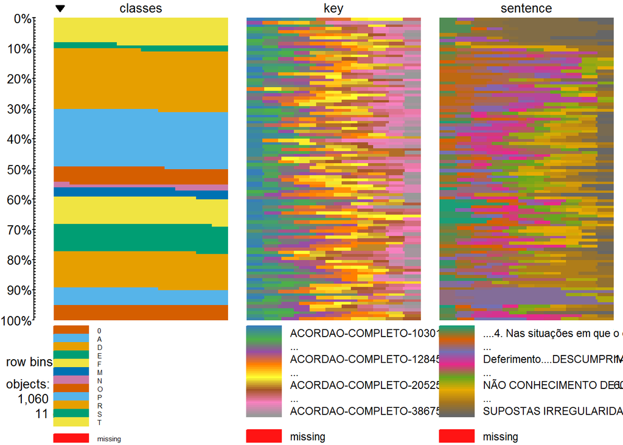

## Classes:

As classes presentes no banco de dados são:

```r
kable(data.frame(table(dados$classes),round(table(dados$classes)/sum(table(dados$classes))*100,2)), "html")%>%
  kable_styling()
```

| Var1 | Freq | Var1.1 | Freq.1 |
| --- | --- | --- | --- |
| 0 | 53 | 0 | 5.00 |
| A | 59 | A | 5.57 |
| D | 130 | D | 12.26 |
| E | 96 | E | 9.06 |
| F | 95 | F | 8.96 |
| M | 30 | M | 2.83 |
| N | 15 | N | 1.42 |
| O | 59 | O | 5.57 |
| P | 201 | P | 18.96 |
| R | 211 | R | 19.91 |
| S | 20 | S | 1.89 |
| T | 91 | T | 8.58 |

## De forma visual

### Frequência das classes:

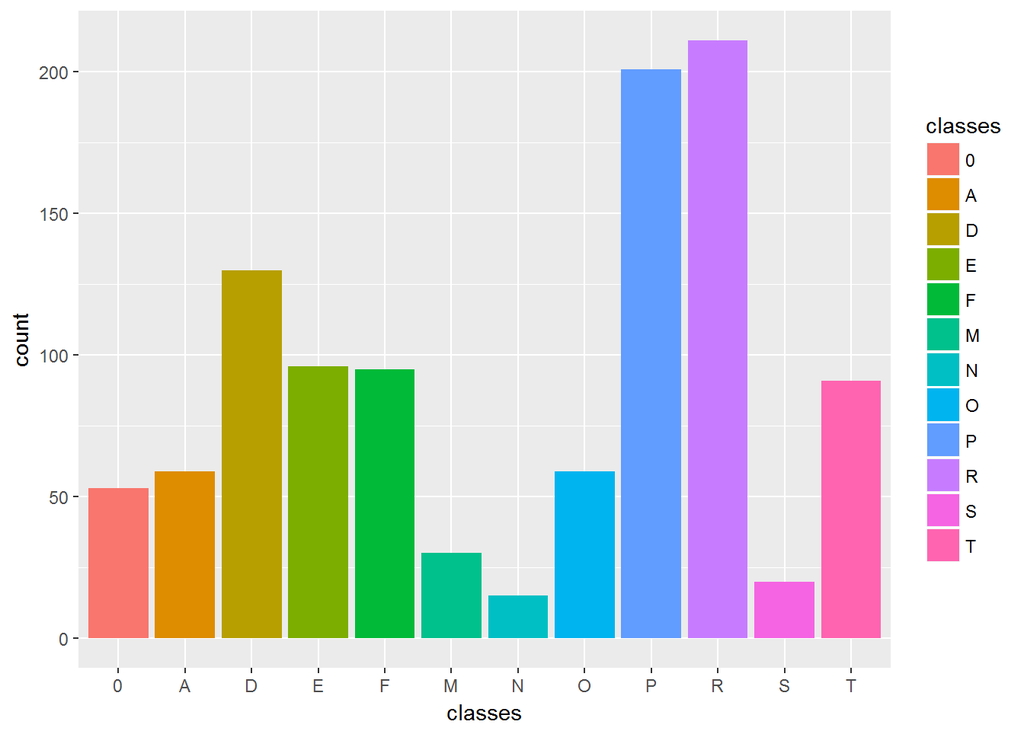

```r
ggplot(aes(x=classes, fill=classes), data=dados)+geom_bar()
```

### Frequência do desfecho por classes:

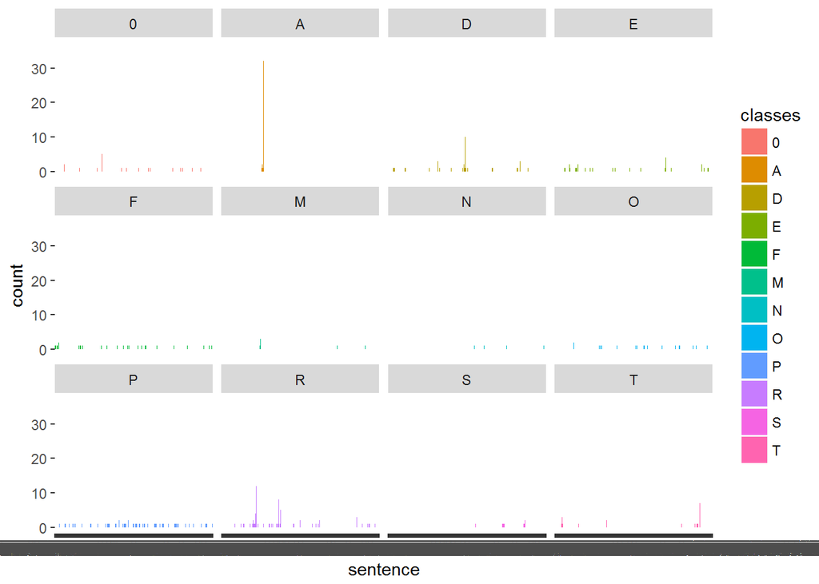

```r
ggplot(data=dados,aes( x=sentence, fill=classes))+
geom_bar()+
facet_wrap(~classes)
```

Como algumas classes possuem muitas observações enquanto outras classes contam com poucas observações.

# Classificação com Naive Bayes

### Modelo sem complemento na base de dados

```r
amostra=sample(1:2, length(dados$classes), replace=T, prob=c(0.7,1-0.7))
  train=dados[amostra==1,]
  test=dados[amostra==2,]


  #Criando o modelo:
  modelo=naiveBayes(train[,-1],train[,1])

  #Fazendo predicao com os dados de teste:
  previsao=predict(modelo, test[,-1], type="class");previsao
```

```
##   [1] A A P P T P P P P P R R R R A P P P P T R R R D R R R R R E P T P P A
##  [36] A D P P P P P R R R A R R R T 0 D D D F P P R P D R R E E E D E E E E
##  [71] 0 P P P P P P D R P A P D P P P P P P R R A R R R D D D D R M E T T T
## [106] T R R P P P P 0 0 D 0 0 A R 0 0 0 R D 0 D R R T A D P D P R R R E O D
## [141] D R D R D D E P P P A P P 0 P P P P R P R R R R F F F F P P P P P P D
## [176] P P P P P P P P P R R R R R R R R R P P P R R T F R F F T T T R P P P
## [211] P P R R R R P P P P R R 0 E E E E P T M D R D A R R R R R R R R F R F
## [246] F R F F A E D F R D D D R D R R R R R R R T P A T T F F F F F F F A E
## [281] E E D E E E E F F F F F F F F R T E E R R R R R E R R R T E E E E E R
## [316] E T P D R A R R T R A D P P P P P R P P P A P E E E E E E P A R P P P
## [351] E D
## Levels: 0 A D E F M N O P R S T
```

```r
  resposta=test[,1]
```

### Matriz de confusao

```r
#Calculando a matrix de confusão:
caret::confusionMatrix(previsao,resposta)
```

```
## Confusion Matrix and Statistics
##
##           Reference
## Prediction  0  A  D  E  F  M  N  O  P  R  S  T
##          0  6  1  0  1  1  0  1  0  0  0  2  0
##          A  0 15  1  0  1  1  0  0  0  1  0  0
##          D  1  0 14  2  2  0  0  2  5  5  2  2
##          E  0  0  1 10  8  1  2  2  7  7  0  1
##          F  0  1  3  4  4  3  1  3  7  2  0  1
##          M  0  0  0  0  0  2  0  0  0  0  0  0
##          N  0  0  0  0  0  0  0  0  0  0  0  0
##          O  0  0  0  0  0  0  0  0  0  1  0  0
##          P  1  0  5  3  6  4  3  6 41 19  2  5
##          R  8  3  6  9  9  3  0  5 15 37  1  3
##          S  0  0  0  0  0  0  0  0  0  0  0  0
##          T  0  0  1  1  0  0  0  1  3  1  0 14
##
## Overall Statistics
##
##                Accuracy : 0.4062
##                  95% CI : (0.3545, 0.4596)
##     No Information Rate : 0.2216
##     P-Value [Acc > NIR] : 6.324e-15
##
##                   Kappa : 0.299
##  Mcnemar's Test P-Value : NA
##
## Statistics by Class:
##
##                      Class: 0 Class: A Class: D Class: E Class: F Class: M
## Sensitivity           0.37500  0.75000  0.45161  0.33333  0.12903 0.142857
## Specificity           0.98214  0.98795  0.93458  0.90994  0.92212 1.000000
## Pos Pred Value        0.50000  0.78947  0.40000  0.25641  0.13793 1.000000
## Neg Pred Value        0.97059  0.98498  0.94637  0.93610  0.91641 0.965714
## Prevalence            0.04545  0.05682  0.08807  0.08523  0.08807 0.039773
## Detection Rate        0.01705  0.04261  0.03977  0.02841  0.01136 0.005682
## Detection Prevalence  0.03409  0.05398  0.09943  0.11080  0.08239 0.005682
## Balanced Accuracy     0.67857  0.86898  0.69310  0.62164  0.52558 0.571429
##                      Class: N Class: O Class: P Class: R Class: S Class: T
## Sensitivity           0.00000 0.000000   0.5256   0.5068  0.00000  0.53846
## Specificity           1.00000 0.996997   0.8029   0.7778  1.00000  0.97853
## Pos Pred Value            NaN 0.000000   0.4316   0.3737      NaN  0.66667
## Neg Pred Value        0.98011 0.945869   0.8560   0.8577  0.98011  0.96375
## Prevalence            0.01989 0.053977   0.2216   0.2074  0.01989  0.07386
## Detection Rate        0.00000 0.000000   0.1165   0.1051  0.00000  0.03977
## Detection Prevalence  0.00000 0.002841   0.2699   0.2812  0.00000  0.05966
## Balanced Accuracy     0.50000 0.498498   0.6643   0.6423  0.50000  0.75849
```

Devido a distribuição dos dados referentes a variável resposta, então toumou-se uma estratégia para ajustar o modelo, veja:

## Novo banco de dados para algorítimo

```r
dados <- readRDS("C:/Users/Fellipe/Dropbox/RPubs/Projeto Estagio/Apresentacao/dados.rds")
dados$classes=as.factor(dados$classes)
dados$sentence=as.factor(dados$sentence)
dados=as.data.frame(dados)

#Comando para print da base de dados:
kable(dados, "html")%>%
  kable_styling()%>%
  scroll_box(width = "1000px", height = "500px")
```

key

sentence

M

1

Pedido de Reexame, em processo de Representação, contra deliberação desta Corte que determinou ao Ministério da Saúde a adoção das medidas necessárias à anulação de Concorrência realizada pelo órgão, devido à quebra de sigilo das propostas de preço.

F

1

Não-apresentação, pela interessada, de elementos suficientes para infirmar os fundamentos da deliberação recorrida.

A

2

Conhecimento.

D

3

Não-provimento.

M

4

CONCORRÊNCIA Nº 09/2012-00.

O

5

SERVIÇO DE CONSERVAÇÃO/RECUPERAÇÃO DA RODOVIA BR-290.

P

6

DESCLASSIFICAÇÃO DE LICITANTE POR FALHAS NAS COMPOSIÇÕES DE CUSTO UNITÁRIO.

T

7

REPRESENTAÇÃO COM PEDIDO DE MEDIDA CAUTELAR.

E

8

AGRAVO CONTRA DECISÃO MONOCRÁTICA QUE DETERMINOU A OITIVA.

F

9

INTEMPESTIVIDADE.

A

10

NÃO CONHECIMENTO.

R

11

PROVIDÊNCIAS INTERNAS.

T

12

REPRESENTAÇÃO.

O

13

EDITAL DE CONCORRÊNCIA PARA OBRAS DE ADEQUAÇÃO DA RODOVIA BR-230/PB.

P

14

REGRA RESTRITIVA À COMPETITIVIDADE DO CERTAME.

P

15

DESCUMPRIMENTO DE DELIBERAÇÃO DO TRIBUNAL DE CONTAS DA UNIÃO.

R

16

MULTA.

R

17

DETERMINAÇÃO AO DNIT.

T

18

DESESTATIZAÇÃO.

O

19

TERCEIRO E QUARTO ESTÁGIOS DA PRIMEIRA RODADA DE CONCORRÊNCIAS PARA A CONTRATAÇÃO DE INSTALAÇÃO E OPERAÇÃO DE AGÊNCIAS DE CORREIOS FRANQUEADAS (AGFs), SOB O REGIME DE FRANQUIA POSTAL.

P

20

DESCUMPRIMENTO DO PRAZO PREVISTO NO ART. 9º, PARÁGRAFO ÚNICO, DA IN-TCU 27/1998.

D

21

APROVAÇÃO DO TERCEIRO ESTÁGIO.

D

22

APROVAÇÃO COM RESSALVA DO QUARTO ESTÁGIO.

R

23

CIÊNCIA À ENTIDADE.

R

24

ENVIO DE CÓPIAS.

R

25

ARQUIVAMENTO.

0

26

EMBARGOS DE DECLARAÇÃO.

T

27

REPRESENTAÇÃO.

M

28

CONCORRÊNCIA.

P

29

PRAZO PARA RECEBIMENTO DE PROPOSTAS INFERIOR AO EXIGIDO NA LEI DE LICITAÇÕES.

D

30

REJEIÇÃO DAS RAZÕES DE JUSTIFICATIVA.

R

31

MULTA.

F

32

AUSÊNCIA DE OMISSÃO, OBSCURIDADE E CONTRADIÇÃO.

R

33

CONHECIMENTO.

R

34

REJEIÇÃO.

R

35

CIÊNCIA.

T

36

REPRESENTAÇÃO ENCAMINHADA PELA OUVIDORIA DO TCU.

P

37

DISPENSA DE LICITAÇÃO PARA PERMUTA DE IMÓVEL.

P

38

VIABILIDADE DE COMPETIÇÃO ENTRE PARTICULARES.

D

39

PROCEDÊNCIA.

R

40

FIXAÇÃO DE PRAZO PARA ANULAÇÃO DO ATO.

F

41

1. A dispensa de licitação com base na alínea c do inciso I do art. 17 da Lei n. 8.666/1993 pressupõe que as especificidades do imóvel adquirido sejam essenciais para atingir a finalidade pública à qual ele será destinado, condicionando a sua escolha.

F

42

2. A permuta de terreno pertencente à entidade da Administração Pública por unidades imobiliárias a serem nele construídas futuramente não se insere na hipótese de dispensa de licitação acima mencionada, devendo ser precedida de procedimento licitatório na modalidade concorrência, uma vez que em tal situação não há falar em imóvel específico que atenda as necessidades do contratante, existindo, portanto, viabilidade de competição entre particulares.

T

43

REPRESENTAÇÃO.

P

44

SUPOSTAS IRREGULARIDADES NA CONCORRÊNCIA PÚBLICA 002/2011.

0

45

SUSPENSÃO DO PROCEDIMENTO LICITATÓRIO.

D

46

PROCEDÊNCIA DOS FATOS APONTADOS.

0

47

SOLUÇÃO DE QUASE TODAS AS OCORRÊNCIAS CONSTATADAS.

R

48

DETERMINAÇÃO.

R

49

COMUNICAÇÃO.

R

50

APENSAMENTO DOS AUTOS AO PROCESSO DE MONITORAMENTE QUE VIER A SER CONSTITUÍDO.

S

51

PEDIDO DE REEXAME.

T

52

REPRESENTAÇÃO DO MINISTÉRIO PÚBLICO FEDERAL - PROCURADORIA DA REPÚBLICA EM GOIÁS - 2º OFÍCIO DO NÚCLEO DE COMBATE À CORRUPÇÃO.

P

53

INDÍCIOS DE IRREGULARIDADES NA CONCORRÊNCIA PÚBLICA OBJETO DO EDITAL 785/2009-12 DNIT-GO.

A

54

CONHECIMENTO DA REPRESENTAÇÃO.

D

55

PROCEDÊNCIA PARCIAL.

R

56

CIÊNCIA À CGU PARA VERIFICAR AS IRREGULARIDADES E COMUNICAR AO TCU SOBRE OS RESULTADOS.

0

57

ACÓRDÃO 1.859/2015 - 1ª CÂMARA.

A

58

CONHECIMENTO DO RECURSO.

D

59

PROVIMENTO.

R

60

ENCAMINHAMENTO DOS AUTOS À SECEX/GO PARA APURAR EVENTUAIS RESPONSABILIDADES DOS SERVIDORES DO DNIT E DAS EMPRESAS ENVOLVIDAS NO CERTAME.

T

61

Denúncia.

P

62

Possíveis irregularidades na Concorrência nº 4/2001 da Empresa de Trens Urbanos de Porto Alegre S.A. - Trensurb.

E

63

Inspeção determinada por decisão anterior.

P

64

Irregularidades decorrentes de restrições ao caráter competitivo do certame, preços orçados superiores aos de mercado e inadequação do orçamento relativo ao fornecimento de sistemas.

R

65

Fixação de prazo para o exato cumprimento da lei, com a anulação da concorrência.

R

66

Determinações.

D

67

Indeferimento de petições.

R

68

Ciência aos Ministros de Estado das Cidades e dos Transportes, à entidade, aos consórcios participantes da licitação, à empresa Andrade Gutierrez S.A., aos Presidentes do Senado Federal, da Câmara dos Deputados, da Comissão Mista de Planos, Orçamentos Públicos e Fiscalização do Congresso Nacional, da Comissão de Fiscalização Financeira e Controle da Câmara dos Deputados e à Procuradoria da República no Rio Grande do Sul.

T

69

REPRESENTAÇÃO.

P

70

IRREGULARIDADES VERIFICADAS NA CONCORRÊNCIA Nº 2/2012, CONDUZIDA PELA PREFEITURA MUNICIPAL DE EMBU DAS ARTES (SP).

A

71

CONHECIMENTO.

E

72

OITIVA.

D

73

PROCEDÊNCIA.

R

74

SUSPENSÃO DO CERTAME.

R

75

CIÊNCIA AOS INTERESSADOS.

T

76

TOMADA DE CONTAS ESPECIAL.

P

77

FRAUDE À LICITAÇÃO.

P

78

EXPEDIÇÃO DE CONVITES A EMPRESAS SEM EXISTÊNCIA FÍSICA E/OU SEM CAPACIDADE ADMINISTRATIVA E OPERACIONAL.

P

79

QUEBRA DO SIGILO DAS PROPOSTAS.

D

80

ILEGALIDADE.

R

81

MULTA.

R

82

INABILITAÇÃO PARA O EXERCÍCIO DE CARGO EM COMISSÃO OU FUNÇÃO DE CONFIANÇA.

R

83

DECLARAÇÃO DE INIDONEIDADE DOS LICITANTES FRAUDADORES.

T

84

TOMADA DE CONTAS ESPECIAL CONVERTIDA DE AUDITORIA.

0

85

VERIFICAÇÃO DA EXECUÇÃO DE CONVÊNIOS E DE PROCEDIMENTOS RELATIVOS A LICITAÇÕES E CONTRATOS.

P

86

PAGAMENTOS POR MATERIAIS NÃO FORNECIDOS.

P

87

CONTRATAÇÕES DIRETAS SEM AMPARO LEGAL.

P

88

AQUISIÇÃO DE PRODUTOS A PREÇOS EXCESSIVAMENTE SUPERIORES AOS DE MERCADO.

P

89

INOBSERVÂNCIA DE NÚMERO MÍNIMO DE PROPOSTAS VÁLIDAS NAS LICITAÇÕES NA MODALIDADE DE CONVITE.

P

90

RECEBIMENTO DE MATERIAIS COM DEFEITOS.

D

91

CONTAS IRREGULARES.

R

92

DÉBITO.

R

93

MULTA.

S

94

RECURSOS DE RECONSIDERAÇÃO.

F

95

INTEMPESTIVIDADE DE UM DOS PEDIDOS.

F

96

AUSÊNCIA DE FATOS NOVOS.

A

97

NÃO CONHECIMENTO.

D

98

ACOLHIMENTO DAS RAZÕES RECURSAIS DE UMA RECORRENTE.

F

99

AUSÊNCIA DE ELEMENTOS PARA JUSTIFICAR SUA CONDENAÇÃO.

A

100

CONHECIMENTO.

D

101

PROVIMENTO.

F

102

INSUFICIÊNCIA DE ARGUMENTOS PARA ALTERAR O ACÓRDÃO RECORRIDO.

A

103

CONHECIMENTO.

D

104

NEGATIVA DE PROVIMENTO.

T

105

REPRESENTAÇÃO.

N

106

CASA DA MOEDA DO BRASIL.

P

107

DIRECIONAMENTO DE CONVITE.

P

108

FRAUDE À LICITAÇÃO.

P

109

REALIZAÇÃO DE DILIGÊNCIA INDEVIDA EM TOMADA DE PREÇOS.

P

110

PRÁTICA DE PREÇOS EXCESSIVOS.

D

111

DÉBITO.

R

112

CONVERSÃO EM TCE.

F

113

CONTRATO AINDA EM ANDAMENTO.

R

114

CONCESSÃO DE MEDIDA CAUTELAR.

R

115

OITIVA DAS EMPRESAS QUE PARTICIPARAM DO CONVITE, PARA FINS DE DECLARAÇÃO DE INIDONEIDADE.

T

116

TOMADA DE CONTAS ESPECIAL.

0

117

CONVÊNIO.

O

118

IRREGULARIDADES NA AQUISIÇÃO DE ÔNIBUS ESCOLAR NO ÂMBITO DO PNTE.

P

119

AFASTAMENTO DO DÉBITO.

P

120

OCORRÊNCIA DE FRAUDE NO PROCEDIMENTO LICITATÓRIO.

P

121

CONTAS IRREGULARES DO EX-PREFEITO.

R

122

MULTA.

S

123

RECURSO DE RECONSIDERAÇÃO.

A

124

CONHECIMENTO.

F

125

ELEMENTOS INCAPAZES DE MODIFICAR O JUÍZO FORMADO.

D

126

NÃO PROVIMENTO.

F

127

A presença de sócios comuns em licitações, especialmente na modalidade convite, afronta o art. 3º da Lei 8.666/1993, pois impede a livre concorrência, comprometendo, ainda, o sigilo das propostas, e, consequentemente, o interesse maior da licitação: a busca da proposta mais vantajosa para a Administração.

T

128

TOMADA DE CONTAS ESPECIAL.

0

129

CONVÊNIO.

P

130

EXECUÇÃO PARCIAL DO OBJETO.

P

131

AUSÊNCIA DE PROVA DE QUE HOUVE APENAS DESVIO DE OBJETO.

P

132

IRREGULARIDADE DAS CONTAS, DÉBITO E MULTA AO RESPONSÁVEL.

S

133

RECURSOS DE RECONSIDERAÇÃO.

A

134

CONHECIMENTO.

D

135

PROVIMENTO NEGADO.

M

136

ILEGALIDADE DO CONVITE PARA CONTRATAÇÃO DA EMPRESA RESPONSÁVEL PELA EXECUÇÃO DO OBJETO.

R

137

MULTA AOS RESPONSÁVEIS PELO CONVITE.

A

138

CONHECIMENTO DO RECURSO.

0

139

FATO ISOLADO NA CONDUÇÃO IRREGULAR DO CONVITE.

0

140

PRESCRIÇÃO DA MULTA.

D

141

PROVIMENTO.

T

142

TOMADA DE CONTAS ESPECIAL.

D

143

DÉBITO.

R

144

MULTA.

S

145

RECURSO DE RECONSIDERAÇÃO.

F

146

ORDENAR A REALIZAÇÃO DE PROCEDIMENTO LICITATÓRIO OU DISPENSÁ-LO É ATO PRÓPRIO DE COMPETÊNCIA DO ORDENADOR DE DESPESAS E NÃO DA CPL.

F

147

A AUSÊNCIA DE DANOS MATERIAIS NÃO AFASTA A ILICITUDE DA SIMULAÇÃO DE PROCEDIMENTO LICITATÓRIO.

F

148

MERAS IRREGULARIDADES FORMAIS NÃO RETIRAM DO DOCUMENTO FISCAL A SUA CAPACIDADE DE COMPROVAR A REGULARIDADE DA DESPESA.

F

149

A AUSÊNCIA DE DESCONTOS PREVIDENCIÁRIOS E DO IMPOSTO DE RENDA POR PARTE DOS MUNICÍPIOS NÃO JUSTIFICA, POR SI, A ATUAÇÃO DO TCU.

F

150

TODO DESEMBOLSO DEVE CORRESPONDER A UMA DESPESA EFETIVA.

F

151

CONTRATAÇÃO DE FIRMA FISICAMENTE INEXISTENTE, POR MEIO DE CONVITE, CONSTITUI IRREGULARIDADE GRAVE.

D

152

PROVIMENTO PARCIAL.

R

153

REDUÇÃO DO DÉBITO E DA MULTA.

T

154

TOMADA DE CONTAS ESPECIAL.

0

155

CONVÊNIO.

P

156

FRAUDE EM PROCEDIMENTO LICITATÓRIO.

P

157

EMPRESAS PARTICIPANTES DE CONVITE GERIDAS POR UM MESMO PROCURADOR.

P

158

PARENTE CONSANGUÍNEO DO EXPREFEITO.

P

159

PARTICIPAÇÃO DE EMPRESAS SEM EXISTÊNCIA FÁTICA.

P

160

INEXECUÇÃO DO OBJETO PREVISTO NO CONVÊNIO.

R

161

DECLARAÇÃO DE INIDONEIDADE.

R

162

INABILITAÇÃO.

D

163

CONTAS IRREGULARES.

R

164

DÉBITO E MULTA.

F

165

1. Considera-se fraude em licitação quando não comprovada a existência fática da empresa vencedora do certame e de sua concorrente, o que leva à declaração de inidoneidade.

F

166

2. É também evidente a comprovação de fraude à licitação quando se constata que duas das três licitantes são representadas por um mesmo procurador, com mandato de poderes ilimitados, sendo esse parente consanguíneo do gestor municipal.

T

167

TOMADA DE CONTAS ESPECIAL.

P

168

FRAUDE À LICITAÇÃO.

P

169

EXPEDIÇÃO DE CONVITES A EMPRESAS SEM EXISTÊNCIA FÍSICA E/OU SEM CAPACIDADE ADMINISTRATIVA E OPERACIONAL.

P

170

QUEBRA DO SIGILO DAS PROPOSTAS.

D

171

ILEGALIDADE.

R

172

MULTA.

R

173

DÉBITO.

R

174

INABILITAÇÃO PARA O EXERCÍCIO DE CARGO EM COMISSÃO OU FUNÇÃO DE CONFIANÇA.

R

175

DECLARAÇÃO DE INIDONEIDADE DOS LICITANTES FRAUDADORES.

T

176

REPRESENTAÇÃO.

N

177

MUNICÍPIO DE ITABI/SE.

E

178

REALIZAÇÃO DE DILIGÊNCIAS.

P

179

ATOS PRATICADOS EM INOBSERVÂNCIA A NORMAS DE DIREITO ADMINISTRATIVO.

0

180

RESPONSABILIDADE DO EX-PREFEITO.

E

181

AUDIÊNCIA.

F

182

RAZÕES DE JUSTIFICATIVA INSUFICIENTES PARA ELIDIR A TOTALIDADE DAS OCORRÊNCIAS.

D

183

PROCEDÊNCIA PARCIAL.

R

184

APLICAÇÃO DE MULTA.

R

185

ARQUIVAMENTO.

F

186

1. A subcontratação é regra de exceção, somente admitida quando não se mostrar viável sob a ótica técnica e/ou econômica a execução integral do objeto por parte da contratada, e desde que mediante autorização formal do ente contratante.

F

187

2. A subcontratação do objeto em sua inteireza não encontra amparo nas normas que disciplinam os contratos administrativos.

F

188

3. O parcelamento é um instrumento de que se deve valer o ente contratante para trazer à competição empresas dos segmentos de mercado aptos a operar com cada uma das parcelas que compõem o objeto licitado.

F

189

4. Nas situações em que o objeto abarca um único segmento de mercado, a finalidade do parcelamento é permitir que empresas desse segmento, conquanto não tenham condições de fazer frente ao objeto em toda a sua integralidade, possam atender a demandas menores, resultantes da sua divisão em parcelas.

F

190

5. Por interpretação analógica, e em homenagem aos princípios da publicidade, da isonomia, da impessoalidade e da economicidade, o orçamento elaborado pelo ente contratante deve ser divulgado como anexo do convite.

T

191

TOMADA DE CONTAS ESPECIAL.

0

192

CONVÊNIO.

P

193

FRAUDE EM PROCEDIMENTO LICITATÓRIO.

P

194

EMPRESAS PARTICIPANTES DE CONVITE GERIDAS POR UM MESMO PROCURADOR.

P

195

PARENTE CONSANGUÍNEO DO EX-PREFEITO.

P

196

PARTICIPAÇÃO DE EMPRESAS SEM EXISTÊNCIA FÁTICA.

P

197

NOTAS FISCAIS INIDÔNEAS.

D

198

CONTAS IRREGULARES.

R

199

DÉBITO E MULTA.

F

200

Julgam-se irregulares as contas, com condenação solidária entre prefeito e empresa supostamente executora do objeto previsto em contrato de repasse quando comprovada a inexistência fática da empresa, presentes ainda notas fiscais inidôneas e indícios de fraude em procedimento licitatório.

T

201

REPRESENTAÇÃO DO § 1º DO ART. 113 DA LEI 8.666/1993.

A

202

CONHECIMENTO.

P

203

SUPOSTA VIOLAÇÃO AO ART. 3º DO DECRETO 7.174/2010.

P

204

NORMA QUE EXTRAPOLA DO PODER REGULAMENTAR E CRIA REQUISITO DE HABILITAÇÃO AO ARREPIO DA LEI 8.666/1993.

P

205

ILEGALIDADE DA REGRA EDITALÍCIA QUE ESTABELECEU A EXIGÊNCIA DE APRESENTAÇÃO DE CERTIFICAÇÕES COM BASE NO MENCIONADO DISPOSITIVO REGULAMENTAR.

P

206

NULIDADE DO PREGÃO ELETRÔNICO REALIZADO PELA ECT.

D

207

PROCEDÊNCIA PARCIAL.

T

208

REPRESENTAÇÃO.

M

209

PREGÃO ELETRÔNICO.

O

210

PRESTAÇÃO DE SERVIÇOS DE VIGILÂNCIA.

A

211

CONHECIMENTO.

D

212

INDEFERIMENTO DE MEDIDA CAUTELAR.

D

213

IMPROCEDÊNCIA.

R

214

CIÊNCIA AOS INTERESSADOS.

R

215

ARQUIVAMENTO.

T

216

REPRESENTAÇÃO.

M

217

PREGÃO ELETRÔNICO.

P

218

DIVERSAS FALHAS.

P

219

INFORMAÇÕES CONTRADITÓRIAS NOS DOCUMENTOS QUE INTEGRAM O EDITAL.

P

220

RESTRIÇÃO AO CARÁTER COMPETITIVO.

P

221

POSSÍVEL DIRECIONAMENTO DO CERTAME.

A

222

CONHECIMENTO.

D

223

ADOÇÃO DE MEDIDA CAUTELAR.

R

224

PREGÃO SUSPENSO.

E

225

OITIVA.

D

226

PROCEDÊNCIA.

R

227

DETERMINAÇÃO PARA ANULAÇÃO DO CERTAME E PARA REALIZAÇÃO DE AUDIÊNCIA DOS RESPONSÁVEIS QUANTO AOS INDÍCIOS DE DIRECIONAMENTO DA LICITAÇÃO.

R

228

CIÊNCIA.

T

229

REPRESENTAÇÃO.

0

230

LICITAÇÃO.

P

231

INOBSERVÂNCIA DO DISPOSTO NO ART. 1º DA LEI Nº 10.520/2002, BEM COMO DO ART. 2º DO DECRETO Nº 3.931/2001 QUE REGULAMENTA O SISTEMA DE REGISTRO DE PREÇOS.

D

232

ANULAÇÃO DO PREGÃO.

T

233

REPRESENTAÇÃO.

M

234

PREGÃO ELETRÔNICO.

P

235

RECEBIMENTO DE LANCE VIA FAX.

P

236

FALHA FORMAL.

D

237

PROCEDÊNCIA.

R

238

DETERMINAÇÕES.

T

239

REPRESENTAÇÃO.

S

240

PEDIDO DE REEXAME.

M

241

PREGÃO.

P

242

EXIGÊNCIAS ATINENTES À HABILITAÇÃO E QUALIFICAÇÃO TÉCNICA.

P

243

MULTA APLICADA AO PREGOEIRO.

P

244

AUSÊNCIA DE RESTRIÇÃO AO CARÁTER COMPETITIVO DO CERTAME.

P

245

ATUAÇÃO COM VISTAS AO ATENDIMENTO DO INTERESSE PÚBLICO.

P

246

BOA-FÉ.

A

247

CONHECIMENTO.

D

248

PROVIMENTO.

P

249

SUPOSTAS IRREGULARIDADES EM PREGÃO ELETRÔNICO REALIZADO PELO NÚCLEO ESTADUAL DO MINISTÉRIO DA SAÚDE.

A

250

CONHECIMENTO.

D

251

IMPROCEDÊNCIA.

R

252

CIÊNCIA À REPRESENTANTE.

R

253

ARQUIVAMENTO.

T

254

REPRESENTAÇÃO COM PEDIDO DE CAUTELAR.

P

255

SUPOSTAS IRREGULARIDADES EM PREGÃO ELETRÔNICO.

P

256

ADJUDICAÇÃO A LICITANTE QUE APRESENTOU MENOR PREÇO GLOBAL POR LOTES.

A

257

CONHECIMENTO.

E

258

OITIVA PRÉVIA.

D

259

PROCEDÊNCIA PARCIAL DA REPRESENTAÇÃO.

0

260

CONSIDERAÇÕES SOBRE O CRITÉRIO DE JULGAMENTO ADOTADO - MENOR PREÇO GLOBAL, COM ADJUDICAÇÃO POR LOTE.

0

261

EXCEÇÃO.

0

262

NECESSIDADE DE JUSTIFICATIVA CIRCUNSTANCIADA.

R

263

PERMISSÃO PARA AQUISIÇÃO DOS ITENS DA LICITANTE VENCEDORA PELA POLÍCIA FEDERAL E PARTICIPANTES.

R

264

DETERMINAÇÃO.

R

265

NÃO AUTORIZAÇÃO DE ADESÕES POR ITENS ESPECÍFICOS, A MENOS QUE O ADERENTE VENHA A CONTRATAR O LOTE TOTAL.

R

266

ARQUIVAMENTO.

T

267

TOMADA DE CONTAS ESPECIAL.

N

268

EMPRESA BRASILEIRA DE CORREIOS E TELÉGRAFOS - ECT.

M

269

PREGÃO 26/2002.

O

270

AQUISIÇÃO DE COFRES.

P

271

CARACTERÍSTICAS DO PRODUTO FORNECIDO DIFEREM DO ESTABELECIDO NO EDITAL E NO CONTRATO.

P

272

VÍCIO OCULTO.

E

273

PERÍCIA.

F

274

DIFERENÇA DE VALOR.

D

275

DÉBITO.

E

276

CITAÇÃO.

D

277

REJEIÇÃO DAS ALEGAÇÕES DE DEFESA.

D

278

CONTAS IRREGULARES.

R

279

DÉBITO.

R

280

MULTA.

F

281

1. O recebimento (provisório ou definitivo) não elimina o dever de o particular responder pela integridade da coisa.

F

282

Mesmo que o vício se revele em momento posterior ao recebimento (sendo impossível sua detecção na ocasião), o particular deverá responder por ele.

F

283

2. Não há necessidade de comprovar que o agente público tenha agido com dolo, ou auferido benefício, para ser condenado a ressarcir o dano causado ao Erário, bastando a caracterização da culpa.

T

284

REPRESENTAÇÃO.

M

285

PREGÃO ELETRÔNICO.

E

286

CONCESSÃO DE MEDIDA CAUTELAR.

E

287

OITIVA.

P

288

INOBSERVÂNCIA DO DISPOSTO NO ART. 15, IV, E ART. 23, § 1º, DA LEI 8.666/1993.

P

289

EXIGÊNCIAS RESTRITIVAS AO CARÁTER COMPETITIVO DA LICITAÇÃO.

P

290

NULIDADE DO CERTAME.

D

291

PROCEDÊNCIA PARCIAL.

T

292

REPRESENTAÇÃO.

P

293

INDÍCIOS DE FRAUDE À LICITAÇÃO E SUPERFATURAMENTO.

D

294

CONHECIMENTO E PROVIMENTO.

R

295

CONVERSÃO DOS AUTOS EM TCE.

F

296

Converte-se em Tomada de Contas Especial processo de Representação em que se constatam indícios de superfaturamento em contrato decorrente de Tomada de Preços realizada por órgão público federal.

M

297

Representação formulada por empresa licitante, noticiando possível ilegalidade em Tomada de Preços.

P

298

Exigência, no Edital, segundo a representante, de data de entrega de mercadorias impossível de ser satisfeita pelos concorrentes, restringindo o caráter competitivo do certame e gerando a desclassificação da empresa que ofereceu o menor preço.

P

299

Constatação, em Inspeção, de outras falhas no processo licitatório e na execução do contrato: início da Tomada de Preços sem crédito orçamentário disponível, emissão de nota de empenho posterior ao prazo de entrega de mercadorias previsto no edital, prorrogação injustificada do contrato, descumprimento do contrato pela empresa vencedora, sem que houvesse a devida repreensão da Administração.

E

300

Audiência.

F

301

Ausência de provas suficientes quanto à alegação da representante, mas confirmação das outras falhas verificadas na Inspeção.

A

302

Conhecimento.

D

303

Improcedência.

R

304

Determinações e juntada às contas do órgão realizador do certame.

T

305

Representação.

P

306

Possíveis irregularidades em tomada de preços realizada pela CODESA.

F

307

Não houve restrição ao caráter competitivo da licitação.

F

308

Ocorrência de falha formal.

A

309

Conhecimento.

D

310

Procedência parcial.

R

311

Determinação à CODESA.

R

312

Arquivamento dos autos.

R

313

Ciência ao interessado e à empresa.

N

314

INSTITUTO BRASILEIRO DO MEIO AMBIENTE E DOS RECURSOS NATURAIS RENOVÁVEIS - IBAMA.

T

315

PRESTAÇÃO DE CONTAS.

0

316

EXERCÍCIO DE 2000.

M

317

TOMADA DE PREÇOS.

0

318

EDITAL E CONTRATO.

0

319

PREVISÃO E EFETIVAÇÃO DE PAGAMENTO ANTECIPADO.

0

320

SIMULAÇÃO DE LIQUIDAÇÃO DE DESPESA.

P

321

DANO AO ERÁRIO EM APURAÇÃO NA PRESTAÇÃO DE CONTAS DO EXERCÍCIO DE 2001.

S

322

RECURSO DE REVISÃO DO MP/TCU.

E

323

IDENTIFICAÇÃO E QUALIFICAÇÃO DOS RESPONSÁVEIS PELO ATO ADMINISTRATIVO IMPUGNADO.

E

324

INDIVIDUALIZAÇÃO DA RESPONSABILIDADE.

S

325

APRESENTAÇÃO DE CONTRARRAZÕES.

D

326

REJEIÇÃO.

A

327

CONHECIMENTO.

D

328

PROVIMENTO.

D

329

CONTAS IRREGULARES.

R

330

MULTA.

E

331

ACÓRDÃO 3.134/2012 - PLENÁRIO.

0

332

EMBARGOS DE DECLARAÇÃO.

A

333

CONHECER.

F

334

AUSÊNCIA DE OMISSÃO, OBSCURIDADE OU CONTRADIÇÃO.

D

335

REJEIÇÃO.

O

336

Representação formulada por licitante apontando irregularidades na Tomada de Preços n.º 001/2000, realizada pelo IBAMA/AM, destinada à contratação de serviços de conservação e limpeza.

A

337

Conhecimento.

D

338

Parcialmente procedente.

R

339

Determinações.

R

340

Ciência à interessada.

R

341

Juntada às contas da Unidade exercício de 2000.

T

342

REPRESENTAÇÃO, COM PEDIDO DE MEDIDA CAUTELAR.

O

343

CONTRATAÇÃO DE EMPRESA PARA EXECUÇÃO DE OBRAS E SERVIÇOS DE CONSTRUÇÃO DE CRECHE NO MUNICÍPIO DE IGACI/AL.

N

344

RECURSOS DO FNDE.

P

345

INABILITAÇÃO INDEVIDA DE LICITANTE POR NÃO SE ENQUADRAR COMO EMPRESA DE PEQUENO PORTE - EPP.

P

346

RISCO DE ILEGALIDADE NA TOMADA DE PREÇOS 08/2015, QUE ORIGINOU O CONTRATO 124/2016.

P

347

NÃO ATENDIMENTO À DILIGÊNCIA DO TRIBUNAL.

R

348

MULTA AO PREFEITO.

F

349

PRESENÇA DOS PRESSUPOSTOS PARA A CONCESSÃO DE MEDIDA CAUTELAR.

R

350

SUSPENSÃO DA EXECUÇÃO DO CONTRATO.

R

351

OITIVAS.

R

352

DILIGÊNCIA.

S

353

RECURSO DE REVISÃO INTERPOSTO PELO MP/TCU.

T

354

PRESTAÇÃO DE CONTAS DO EXERCÍCIO DE 2000.

M

355

TOMADA DE PREÇOS.

0

356

EDITAL E CONTRATO.

0

357

PREVISÃO DE PAGAMENTO ANTECIPADO.

E

358

EMISSÃO DE PARECER JURÍDICO IRREGULAR.

E

359

MULTA.

0

360

EMBARGOS DE DECLARAÇÃO.

D

361

REJEIÇÃO.

S

362

RECURSO DE RECONSIDERAÇÃO.

A

363

CONHECIMENTO.

D

364

PROVIMENTO PARCIAL.

0

365

RECURSO DE REVISÃO PARA REABERTURA DA PRESTAÇÃO DE CONTAS DA FUFAM, EXERCÍCIO DE 2003, JULGADA REGULAR COM RESSALVA, QUITAÇÃO AOS RESPONSÁVEIS E DETERMINAÇÕES.

A

366

CONHECER.

D

367

NEGAR PROVIMENTO.

R

368

MANTER A DELIBERAÇÃO ANTERIOR.

R

369

CIÊNCIA.

T

370

REPRESENTAÇÃO.

O

371

IRREGULARIDADES EM TOMADA DE PREÇOS PARA CONTRATAÇÃO DE EMPRESA DE ENGENHARIA COM VISTA À CONSTRUÇÃO DE ESCOLA MUNICIPAL.

E

372

APLICAÇÃO DE MULTAS.

E

373

PEDIDOS DE REEXAME.

A

374

CONHECIMENTO.

D

375

IMPROVIMENTO.

D

376

EMBARGOS DE DECLARAÇÃO.

A

377

NÃO CONHECIMENTO DE UM.

A

378

CONHECIMENTO DO OUTRO.

D

379

REJEIÇÃO.

O

380

Representação acerca de irregularidades na aplicação de recursos transferidos ao município por meio de contrato de repasse firmado no âmbito do Programa Morar Melhor visando à execução de obras de saneamento.

O

381

Realização de licitações distintas para a contratação das obras e para a aquisição do material hidráulico nas modalidades convite e tomada de preços respectivamente, ao invés de se promover os certames observando a modalidade tomada de preços.

P

382

Infração ao art. 23, § 2°, da Lei n° 8.666/93.

A

383

Conhecimento.

D

384

Procedência.

R

385

Determinação.

R

386

Ciência aos interessados.

R

387

Arquivamento.

T

388

DESESTATIZAÇÃO.

0

389

PRIMEIRO ESTÁGIO DE FISCALIZAÇÃO.

M

390

LEILÃO ANEEL Nº 1/2013.

D

391

APROVAÇÃO COM RESSALVAS.

R

392

RESTITUIÇÃO DOS AUTOS À UNIDADE TÉCNICA PARA ACOMPANHAMENTO DOS DEMAIS ESTÁGIOS.

T

393

ACOMPANHAMENTO.

M

394

LEILÃO ANEEL Nº 001/2010.

O

395

OUTORGA DE CONCESSÃO PARA PRESTAÇÃO DE SERVIÇOS DE TRANSMISSÃO DE ENERGIA ELÉTRICA.

0

396

ANÁLISE DO 1º, 2º, 3º e 4º ESTÁGIOS.

D

397

APROVAÇÃO COM RESSALVA DO 1º E SEM RESSALVA DOS DEMAIS ESTÁGIOS.

R

398

ARQUIVAMENTO.

O

399

ACOMPANHAMENTO DO SEGUNDO E DO TERCEIRO ESTÁGIOS DE FISCALIZAÇÃO DO LEILÃO PARA CONTRATAÇÃO DE ENERGIA PROVENIENTE DE NOVOS EMPREENDIMENTOS DE GERAÇÃO, NO AMBIENTE DE CONTRATAÇÃO REGULADA (A5).

0

400

APROVEITAMENTOS HIDRELÉTRICOS DE GARIBALDI, FERREIRA GOMES E COLÍDER.

D

401

APROVAÇÃO.

O

402

LEILÃO PARA CONTRATAÇÃO DE ENERGIA NOVA.

N

403

UHE DE BELO MONTE.

T

404

ACOMPANHAMENTO DO 1º ESTÁGIO.

E

405

ANÁLISE PRELIMINAR.

E

406

ANÁLISE DOS ESTUDOS ECONÔMICO-FINANCEIROS, DOS ESTUDOS DE IMPACTO E LICENCIAMENTO AMBIENTAL E DE ASPECTOS RELACIONADOS A PROJETO E CUSTOS DAS OBRAS.

O

407

AVALIAÇÃO DO SEGUNDO, TERCEIRO E QUARTO ESTÁGIOS DO ACOMPANHAMENTO DO LEILÃO ANEEL 11/2013, QUE TEM POR OBJETO A CONCESSÃO DA PRESTAÇÃO DE SERVIÇO PÚBLICO DE TRANSMISSÃO DE ENERGIA ELÉTRICA, PRECEDIDA DE OBRA PÚBLICA, INCLUINDO CONSTRUÇÃO, OPERAÇÃO E MANUTENÇÃO DE LINHAS DE TRANSMISSÃO, SUBESTAÇÕES E DEMAIS INSTALAÇÕES A SEREM INTEGRADAS À REDE BÁSICA DO SISTEMA INTERLIGADO NACIONAL (SIN).

D

408

INEXISTÊNCIA DE VÍCIOS RELEVANTES NAS MINUTAS DE CONTRATO, NA EXECUÇÃO DO LEILÃO, NO CONTRATO, NOS RELATÓRIOS DE HABILITAÇÃO E DE RESULTADO E NO ATO DE OUTORGA.

R

409

EXPEDIÇÃO DE DETERMINAÇÃO E RECOMENDAÇÃO À ANEEL, COM O INTUITO DE BALIZAR FUTUROS CERTAMES VISANDO A CONCESSÃO DE PRESTAÇÃO DE SERVIÇO PÚBLICO SOB SUA CONDUÇÃO.

T

410

ACOMPANHAMENTO.

M

411

1º, 2º E 3º ESTÁGIOS DO LEILÃO N. 002/2005-ANEEL.

O

412

OBJETO: CONTRATAÇÃO DE ENERGIA PROVENIENTE DE NOVOS EMPREENDIMENTOS E DAQUELES ENQUADRADOS NO ART. 17 DA LEI N. 10.848, DE 2004, PARA O SISTEMA INTERLIGADO NACIONAL, NO AMBIENTE DE CONTRATAÇÃO REGULADA.

D

413

APROVAÇÃO, COM RESSALVAS DO 1º ESTÁGIO.

D

414

APROVAÇÃO DO 2º E 3º ESTÁGIOS.

F

415

ESTUDOS DE VIABILIDADE PRECÁRIOS.

F

416

IMPROPRIEDADES FORMAIS.

R

417

DETERMINAÇÕES.

R

418

RECOMENDAÇÕES.

R

419

COMUNICAÇÕES.

R

420

RESTITUIÇÃO À SEFID PARA ACOMPANHAR O 4º ESTÁGIO.

O

421

LEILÃO PARA CONTRATAÇÃO DE ENERGIA NOVA, UHE DE SANTO ANTÔNIO (COMPLEXO DO RIO MADEIRA).

T

422

ACOMPANHAMENTO DO 1º ESTÁGIO.

E

423

APRECIAÇÃO DOS ESTUDOS DESTINADOS AO ESTABELECIMENTO DO PREÇO MÁXIMO DO LEILÃO.

D

424

VERIFICADAS IMPROPRIEDADES METODOLÓGICAS NOS ESTUDOS, RESULTANTES EM AUMENTO NO PREÇO MÁXIMO A SER DEFINIDO.

F

425

POSSIBILIDADE DE COMPROMETIMENTO DA MODICIDADE TARIFÁRIA.

F

426

LIMITES DA COMPETÊNCIA DO TCU, NA FISCALIZAÇÃO DAS ATIVIDADES REGULATÓRIAS.

R

427

DETERMINAÇÕES.

R

428

COMUNICAÇÕES.

T

429

Acompanhamento do processo de privatização do Banco do Estado do Piauí - BEP.

D

430

Aprovação dos dois primeiros estágios de que trata a IN TCU nº 27/1998.

E

431

Exame dos relatórios de avaliação econômica encaminhados pelo Banco Central do Brasil.

D

432

Necessidade de nova avaliação caso o período compreendido entre a avaliação realizada e a data em que deverá ser realizado o leilão supere um ano.

R

433

Determinações ao Bacen.

R

434

Autorização de inspeção na sede do BEP.

R

435

Remessa de cópias da Decisão, bem como do Relatório e Voto que a fundamentaram, ao Ministro da Fazenda e aos Presidentes do Conselho Monetário Nacional, do Conselho Nacional de Desestatização, da Comissão de Fiscalização Financeira e Controle da Câmara dos Deputados e da Comissão de Fiscalização e Controle do Senado Federal.

T

436

DESESTATIZAÇÃO.

O

437

LEILÃO ANEEL 11/2013 - TRANSMISSÃO DE ENERGIA ELÉTRICA.

E

438

ACOMPANHAMENTO DO PRIMEIRO ESTÁGIO.

E

439

REMESSA AO TRIBUNAL DOS ESTUDOS DE IMPACTO E DE LICENCIAMENTO AMBIENTAL E DE CUSTOS SOCIOAMBIENTAIS, ASSIM COMO DOS ESTUDOS ACERCA DA VIABILIDADE TÉCNICA E ECONÔMICA DO EMPREENDIMENTO.

E

440

APRESENTAÇÃO DE TAXA DE RETORNO (WACC) PROVISÓRIA.

D

441

NECESSIDADE DE AVALIÇÃO DA TAXA QUE SERÁ EFETIVAMENTE ADOTADA.

F

442

POSSIBILIDADE DE APRIMORAMENTO DA METODOLOGIA ADOTADA PARA A ESTIMAÇÃO DOS CUSTOS SOCIOAMBIENTAIS DE PROJETOS DE SISTEMA DE TRANSMISSÃO DE ENERGIA ELÉTRICA.

R

443

DETERMINAÇÃO À ANEEL, NO SENTIDO DE QUE SE ABSTENHA DE PUBLICAR O EDITAL DA LICITAÇÃO ANTES DE TRANSCORRIDO O PRAZO DE CINCO DIAS ÚTEIS APÓS O COMPROVADO ENVIO AO TRIBUNAL DO CÁLCULO DA TAXA DE RETORNO DEFINITIVA.

R

444

RECOMENDAÇÕES VISANDO O APRIMORAMENTO DA ACIMA REFERIDA METODOLOGIA.

S

445

PEDIDO DE REEXAME.

T

446

DESESTATIZAÇÃO.

M

447

PRIMEIRO ESTÁGIO DO LEILÃO 13/2015-ANEEL.

P

448

COMPETÊNCIA DO TCU PARA DETERMINAR A ADOÇÃO DE PROVIDÊNCIAS PELAS AGÊNCIAS REGULADORAS.

P

449

ADOÇÃO DE PARÂMETRO INCONSISTENTE.

P

450

OFENSA AO PRINCÍPIO DA MODICIDADE TARIFÁRIA.

P

451

DISCRICIONARIEDADE DA AGÊNCIA PARA OPTAR ENTRE ALTERNATIVAS TÉCNICA E JURIDICAMENTE VÁLIDAS.

A

452

CONHECIMENTO.

D

453

PROVIMENTO PARCIAL.

R

454

CONVERSÃO DE DETERMINAÇÃO EM RECOMENDAÇÃO.

T

455

REPRESENTAÇÃO.

M

456

CONCURSO PÚBLICO.

P

457

ALTERAÇÃO INTEMPESTIVA DE GABARITO.

P

458

CRITÉRIOS SUPOSTAMENTE INADEQUADOS PARA AVALIAR TÍTULOS.

R

459

DETERMINAÇÕES CORRETIVAS.

0

460

PESSOAL.

0

461

ADMISSÃO.

E

462

VALIDADE DO CONCURSO PRORROGADA JUDICIALMENTE POR TEMPO INDETERMINADO.

P

463

NEGATIVA DE REGISTRO.

P

464

POSSIBILIDADE DE SUBSISTÊNCIA DAS ADMISSÕES ENQUANTO MANTIDA A DECISÃO JUDICIAL.

R

465

DETERMINAÇÕES.

S

466

Pedido de reexame de Decisão proferida em Relação pela 1ª Câmara.

P

467

Aproveitamento de servidores sem concurso público.

P

468

Recebimento de salários dos órgãos cedentes e do cessionário.

E

469

Determinação do TCU para que fossem apurados os montantes pagos indevidamente.

S

470

Pedido de reexame interposto pelo então Presidente do TRE/GO já apreciado, por meio do Acórdão 158/2001 - Primeira Câmara.

A

471

Conhecimento.

D

472

Não-provimento.

R

473

Ciência ao recorrente.

E

474

EMBARGOS DE DECLARAÇÃO.

0

475

ADMISSÃO.

P

476

CONTRATAÇÃO DE TERCEIRIZADOS SEM CONCURSO PÚBLICO, EM DESOBEDIÊNCIA AO ART. 37, INCISO II, DA CONSTITUIÇÃO FEDERAL DE 1988.

P

477

SUPERVENIÊNCIA DE ACORDOS JUDICIAIS, HOMOLOGADOS PELO SUPREMO TRIBUNAL FEDERAL, QUE GARANTIRAM A PERMANÊNCIA DOS ADMITIDOS ATÉ 21/12/1993 E SUBSTITUIÇÃO GRADATIVA DOS DEMAIS POR EMPREGADOS CONCURSADOS.

D

478

EMBARGOS ACOLHIDOS.

F

479

LEGALIDADE DAS ADMISSÕES.

T

480

Prestação de Contas do exercício de 2000.

P

481

Irregularidades.

P

482

Contratação sem concurso público.

E

483

Audiência de um dos responsáveis.

D

484

Rejeição parcial das razões de justificativa.

F

485

Entendimento no sentido de que somente a partir da publicação da decisão do STF em sede do MS nº 21.797-7 é que se pode exigir dos Conselhos de Fiscalização Profissional a observância da orientação ali contida.

F

486

Contas regulares com ressalva.

R

487

Determinações.

R

488

Ciência ao Conselho Federal de Farmácia.

T

489

DENÚNCIA.

P

490

PERMUTA DE CARGOS DA MESMA NATUREZA VIABILIZADA PELO INSTITUTO DA REDISTRIBUIÇÃO (ART. 37 DA LEI 8.112/1990), COM O OBJETIVO DE REMOVER SERVIDOR PARA A LOCALIDADE DE RESIDÊNCIA DE SEUS FAMILIARES.

P

491

POSSÍVEL PREJUÍZO A CANDIDATO APROVADO EM CONCURSO EM VIGOR.

E

492

DESISTÊNCIA DA AÇÃO POR PARTE DO CANDIDATO SUPOSTAMENTE PREJUDICADO PELA REDISTRIBUIÇÃO.

E

493

EDIÇÃO DE LEI PERMITINDO A REMOÇÃO DE SERVIDORES DO QUADRO DA JUSTIÇA FEDERAL.

A

494

CONHECIMENTO DA DENÚNCIA.

D

495

IMPROCEDÊNCIA.

R

496

COMUNICAÇÃO.

F

497

1. A aprovação em concurso público confere ao candidato apenas a expectativa de direito à nomeação e não ao direito propriamente dito.

F

498

Por isso, a simples existência de candidatos aprovados em concursos, ainda não nomeados, não impede a administração de praticar os atos normais de gestão e movimentação de seu pessoal, ainda que tais atos frustrem momentaneamente a expectativa dos candidatos.

F

499

2. A edição da Lei 11.416/2006 que, em seu art. 20, permitiu a remoção de servidores da Justiça Federal, inclusive entre os quadros de pessoal dos diversos órgãos, tem o condão de convalidar os atos que, materialmente de remoção, tomaram a forma de redistribuição, desde que isentos dos vícios de abuso ou excesso de poder.

T

500

ADMINISTRATIVO.

S

501

RECURSO AO PLENÁRIO.

0

502

CONCURSO PÚBLICO PARA PROVIMENTO DE CARGOS DE ACE/CE.

P

503

PRORROGAÇÃO.

P

504

DISCRICIONARIEDADE DA ADMINISTRAÇÃO.

D

505

NEGADO PROVIMENTO.

P

506

Pedido de Reexame contra a Decisão nº 469/2002 - Primeira Câmara - TCU que julgou ilegal ato de admissão realizada após o vencimento do concurso público.

A

507

Recurso conhecido.

D

508

Negado provimento.

R

509

Manutenção do aresto atacado nos seus exatos termos.

R

510

Ciência ao recorrente e à interessada.

0

511

EMBARGOS DE DECLARAÇÃO EM PROCESSO ORIGINÁRIO DE ADMISSÃO DE PESSOAL.

P

512

NEGATIVA DE REGISTRO DOS ATOS EM FACE DA EXTRAPOLAÇÃO DO PRAZO REGULAMENTAR DE VALIDADE DO RESPECTIVO CONCURSO PÚBLICO, ESTABELECIDA JUDICIALMENTE.

P

513

DETERMINAÇÃO PARA DESLIGAMENTO DOS INTERESSADOS, NA HIPÓTESE DE DESCONSTITUIÇÃO DA DECISÃO JUDICIAL.

P

514

ARGUIÇÃO DE SUPOSTA OMISSÃO NA DELIBERAÇÃO DA CORTE DE CONTAS.

A

515

CONHECIMENTO.

D

516

REJEIÇÃO.

T

517

ACOMPANHAMENTO.

P

518

POSSÍVEIS IRREGULARIDADES EM CONVÊNIOS.

P

519

IDENTIFICAÇÃO DE DOIS CONVÊNIOS FIRMADOS ENTRE A PREFEITURA MUNICIPAL DE MACAPÁ/AP E O MINISTÉRIO DA INTEGRAÇÃO NACIONAL PARA CANALIZAÇÃO DO CANAL JANDIÁ.

P

520

UTILIZAÇÃO DE PROJETO BÁSICO INCOMPLETO NA LICITAÇÃO.

P

521

NÃO ATENDIMENTO DE DILIGÊNCIA PELO EX-PREFEITO.

R

522

MULTAS.

0

523

EXECUÇÃO PARCIAL E SITUAÇÃO DE PARALISAÇÃO DO CONTRATO.

R

524

OITIVA DA PREFEITURA E DO CONSÓRCIO.

R

525

DETERMINAÇÃO.

O

526

ACOMPANHAMENTO DE LEILÃO PARA CONTRATAÇÃO DE ENERGIA.

N

527

USINA HIDROELÉTRICA DE JIRAU.

D

528

APROVAÇÃO COM RESSALVAS DO PRIMEIRO ESTÁGIO.

D

529

APROVAÇÃO PLENA DOS DEMAIS ESTÁGIOS.

R

530

ARQUIVAMENTO.

T

531

ACOMPANHAMENTO.

M

532

PARCERIA PÚBLICO-PRIVADA (PPP), NA MODALIDADE CONCESSÃO PATROCINADA.

0

533

PROJETO DE IRRIGAÇÃO PONTAL.

P

534

NECESSIDADE DE OBTENÇÃO DE LICENCIAMENTO AMBIENTAL PRÉVIO ANTES DO LANÇAMENTO DO EDITAL DA LICITAÇÃO.

P

535

COMPETÊNCIA LEGAL DA SECRETARIA DO TESOURO NACIONAL (STN) PARA NORMATIZAR A CONTABILIZAÇÃO DAS PPP.

P

536

1º ESTÁGIO.

D

537

APROVAÇÃO COM RESSALVAS.

R

538

DETERMINAÇÕES E RECOMENDAÇÃO.

O

539

LEILÃO PARA CONTRATAÇÃO DE ENERGIA NOVA, UHE DE JIRAU (COMPLEXO DO RIO MADEIRA).

T

540

ACOMPANHAMENTO DO 1º ESTÁGIO.

E

541

APRECIAÇÃO DOS ESTUDOS DESTINADOS AO ESTABELECIMENTO DO PREÇO MÁXIMO DO LEILÃO.

D

542

IDENTIFICAÇÃO DE ITENS ORÇAMENTÁRIOS PASSÍVEIS DE REDUÇÃO.

0

543

LIMITES DA COMPETÊNCIA DO TCU, NA FISCALIZAÇÃO DAS ATIVIDADES REGULATÓRIAS.

R

544

RECOMENDAÇÕES.

R

545

COMUNICAÇÕES.

M

546

Representação formulada pelo Exmo Sr. Procurador Regional da República Dr. Luis Cláudio Pereira Leivas, requerendo a suspensão liminar de processo licitatório na modalidade de leilão que seria realizado pela RFFSA em liquidação, tendo em vista a prática de irregularidades.

E

547

Cautelar concedida por este Tribunal.

F

548

Leilões podem ser realizados, desde que se atenda rigorosamente à legislação pertinente ao tema.

P

549

Inadequação de se realizar leilão de material inservível, classificado como sucata, em conjunto com vagões ainda recuperáveis.

P

550

Não deve a RFFSA em liquidação insistir na prática de fracionamento dos Leilões contrariando a legislação.

D

551

Procedência parcial da Representação.

R

552

Conversão deste processo em Acompanhamento.

R

553

Determinação à Segecex para inclusão no Plano de Fiscalização do Primeiro Semestre de 2005 de Auditoria Operacional na RFFSA em liquidação, tendo em vista irregularidades constatadas no processo de liquidação, em função da Representação ora formulada.

F

554

Descontrole do patrimônio da empresa.

F

555

Fortes indícios de favorecimento a empresa potencial compradora de bens alienáveis.

R

556

Determinações à RFFSA em liquidação.

R

557

Comunicações a autoridades competentes.

T

558

Representação.

O

559

Irregularidades em procedimento seletivo, promovido por concessionária, visando à contratação de Produtor Individual de Energia Elétrica.

P

560

A previsão legal da possibilidade de dispensa de licitação não exclui a necessidade de indicação das razões da escolha e a justificativa do preço.

P

561

Impossibilidade de a ora representante se beneficiar do fato de possuir equipamentos já instalados no terreno da concessionária Manaus Energia, em detrimento das demais licitantes.

P

562

Possibilidade de aplicação do instituto da reversão.

D

563

Improcedência das alegações.

R

564

Determinação de acompanhamento do procedimento.

T

565

Acompanhamento de dispensa de licitação.

E

566

Audiência do responsável.

0

567

Fatos relacionados a outras contratações de mesma natureza.

E

568

Nova audiência.

D

569

Rejeição das razões de justificativa.

R

570

Multa.

R

571

Considerações sobre a contratação terceirizada de serviços por empresas públicas e empresas estatais.

R

572

Recomendação.

R

573

Ciência à Secretaria Federal de Controle Interno.

R

574

Apensamento.

T

575

REPRESENTAÇÃO.

N

576

PORTO DE SANTOS.

O

577

CONTRATO DE ARRENDAMENTO DE ÁREA PARA CONSTRUÇÃO E OPERAÇÃO DE TERMINAL TURÍSTICO DE PASSAGEIROS.

P

578

TROCA DA ÁREA INICIALMENTE PREVISTA CONFIGURANDO ALTERAÇÃO DE OBJETO.

P

579

NECESSIDADE DE REALIZAÇÃO DE NOVA LICITAÇÃO.

P

580

INEXISTÊNCIA DE CONSULTA PRÉVIA À RECEITA FEDERAL SOBRE A CONCESSÃO DE ALFANDEGAMENTO AO PROJETO.

F

581

DESCARACTERIZAÇÃO DE IRREGULARIDADES.

A

582

CONHECIMENTO.

D

583

IMPROCEDÊNCIA.

R

584

ARQUIVAMENTO.

F

585

A mera mudança de área para instalação de terminal de passageiros dentro dos limites do porto, provocada por restrições opostas pela Receita Federal e por deficiências na infra-estrutura circundante, não caracteriza a mudança do objeto do arrendamento inicial, não obrigando à realização de nova licitação.

T

586

REPRESENTAÇÃO.

P

587

COMPROMETIMENTO DO CARÁTER COMPETITIVO.

D

588

IMPROCEDÊNCIA.

R

589

ARQUIVAMENTO.

T

590

DENÚNCIA.

P

591

POSSÍVEIS IRREGULARIDADES NO EDITAL DO LEILÃO 02/2014 DA ANEEL.

S

592

PEDIDO DE MEDIDA CAUTELAR.

F

593

AUSÊNCIA DE PRESSUPOSTOS PARA O PROVIMENTO ACAUTELATÓRIO.

F

594

LICITAÇÃO JÁ REALIZADA.

D

595

DENÚNCIA PREJUDICADA.

F

596

PERDA DE OBJETO.

R

597

OPORTUNIDADE PARA SE EXPEDIR DETERMINAÇÃO AO MME.

R

598

ARQUIVAMENTO.

T

599

Denúncia.

O

600

Possíveis irregularidades praticadas na condução de Convite para a contratação de serviços de tradução.

E

601

Audiência dos responsáveis.

D

602

Acatamento das razões de justificativa.

0

603

Considerações sobre a prova indiciária.

D

604

Conhecimento e improcedência.

R

605

Arquivamento.

T

606

Relatório de Inspeção.

P

607

Irregularidades.

P

608

Audiência não sanou os vícios nos procedimentos de dispensa de licitação.

P

609

Não caracterizada a situação de emergência.

P

610

Falta de Projeto Básico adequado.

E

611

Multa aos responsáveis.

P

612

Reincidência de prática de atos irregulares.

P

613

Descumprimento de Decisão do TCU.

P

614

Inabilitação dos responsáveis conforme previsto no art. 60 da Lei Orgânica.

E

615

Instauração de Tomada de Contas Especial pela CISET do Ministério dos Transportes.

E

616

Determinações ao DNER.

S

617

Interposição de Pedidos de Reexame por parte do órgão e dos responsáveis.

A

618

Conhecimento.

D

619

Provimento negado.

F

620

Habilitação de terceiro prejudicado.

S

621

Interposição de Pedido de Reexame.

A

622

Não-conhecimento.

R

623

Ciência aos recorrentes.

O

624

Acompanhamento de processo de outorga de Serviço Telefônico Fixo Comutado destinado ao Uso Público em Geral - STFC.

P

625

Autorizações concedidas sem licitação para prestação do serviço em regime privado.

P

626

Desnecessidade de observância aos estágios definidos na IN/TCU 27/98.

P

627

Necessidade de observância ao disposto no art. 10 da mesma IN.

P

628

Inclusão de cláusula contemplando a obrigatoriedade de a autorizada fazer cumprir o artigo 90, inciso IX, do Regulamento de Licitação para Concessão, Permissão e Autorização de Serviço de Telecomunicações e de uso de Radiofrequência.

R

629

Determinações.

R

630

Arquivamento.

O

631

Monitoramento de licitação promovida com o objetivo de contratar a prestação de serviços de suporte técnico a usuários da rede corporativa do MDIC.

P

632

Indícios de irregularidades na formulação do edital.

E

633

Suspensão cautelar do certame.

E

634

Oitiva dos responsáveis.

E

635

Análise das justificativas.

D

636

Necessidade de proceder-se a correções no edital.

R

637

Determinações.

T

638

AUDITORIA.

0

639

FISCALIZAÇÃO DA ATUAÇÃO DAS ESTATAIS INTEGRANTES DA SPE NORTE ENERGIA S/A, CONCESSIONÁRIA DA USINA HIDRELÉTRICA DE BELO MONTE, SOBRE OS INVESTIMENTOS E CONTRATOS DE EXECUÇÃO DO EMPREENDIMENTO.

P

640

MODELAGEM DO LEILÃO.

P

641

POSSÍVEL PERDA DA CONCORRÊNCIA.

P

642

CONFLITO DE INTERESSES NA ADMISSÃO DOS PRIMEIROS CONSULTORES COMO APTOS A EMPREENDEDORES DA CONCESSÃO.

P

643

DIVISÃO DOS CONTRATOS DA SPE ENTRE OS GRANDES EMPREITEIROS E PROJETISTAS.

P

644

CONSTITUIÇÃO DA SPE.

P

645

INDÍCIOS DO EXERCÍCIO DO PODER DE CONTROLE DA GESTÃO PELO GRUPO ELETROBRAS.

P

646

APONTAMENTO DE EXPRESSIVO SOBREPREÇO NO CONTRATO DE EXECUÇÃO DAS OBRAS CIVIS DA USINA.

P

647

OBSTRUÇÃO À FISCALIZAÇÃO DA EQUIPE DO TRIBUNAL, MEDIANTE A NEGATIVA DE FORNECIMENTO DE DOCUMENTOS.

R

648

OITIVAS.

T

649

RELATÓRIO DE AUDITORIA.

N

650

COMPANHIA HIDRO ELÉTRICA DO SÃO FRANCISCO - Chesf.

O

651

VERIFICAÇÃO DA REGULARIDADE DOS PRÉ-CONTRATOS E CONTRATOS RELATIVOS ÀS OBRAS DAS LINHAS DE TRANSMISSÃO MOSSORÓ IV/MOSSORÓ II, CEARÁ MIRIM II/TOUROS E RUSSAS/BANABUIÚ (OBRAS DECORRENTES DO LEILÃO 3/2012 - Aneel - LOTE B).

0

652

AUSÊNCIA DE ESTIMATIVA DE CUSTOS ELABORADO PARA BALIZAR AS PROPOSTAS COMERCIAIS DAS EMPRESAS PARTICIPANTES DO PROCESSO DE DISPENSA DE LICITAÇÃO E DA DOCUMENTAÇÃO DE QUALIFICAÇÃO TÉCNICA E ECONÔMICO-FINANCEIRA.

0

653

INEXISTÊNCIA, NOS AUTOS, DE INDÍCIOS DA OCORRÊNCIA DE SOBREPREÇO.

R

654

CIÊNCIA À ESTATAL.

0

655

AUDITORIA.

0

656

CONVÊNIO.

O

657

OBRAS DE CONSTRUÇÃO DE HOSPITAL.

P

658

OBRA PARALISADA POR FALTA DE RECURSOS.

P

659

INDÍCIOS DE IRREGULARIDADES NA APROVAÇÃO DO PROJETO.

P

660

LICITAÇÃO E CONTRATAÇÃO SEM PROJETO BÁSICO HÁBIL.

P

661

CONTINUIDADE DA OBRA SEM DISPONIBILIDADE DE RECURSOS.

E

662

AUDIÊNCIA DOS GESTORES DO MINISTÉRIO DA SAÚDE E DOS EXPREFEITOS.

E

663

APRESENTAÇÃO DE JUSTIFICATIVAS PELOS GESTORES DO MINISTÉRIO.

E

664

REVELIA DOS EXPREFEITOS.

D

665

ACOLHIMENTO DAS JUSTIFICATIVAS DOS SERVIDORES DO MINISTÉRIO.

F

666

EXECUÇÃO DE PROJETO NÃO APROVADO PELO MINISTÉRIO.

R

667

MULTA AOS EXPREFEITOS.

T

668

REPRESENTAÇÃO.

P

669

IRREGULARIDADES EM LICITAÇÕES.

P

670

POSSÍVEL INCLUSÃO INDEVIDA DE ITENS EM EDITAL DE LICITAÇÃO.

P

671

POSSÍVEL ADESÃO INADEQUADA À ATA DE REGISTRO DE PREÇOS.

P

672

DEFICIÊNCIAS NA ELABORAÇÃO DO PLANEJAMENTO DA CONTRATAÇÃO.

E

673

AUDIÊNCIA DOS RESPONSÁVEIS.

E

674

PROPOSTA PARA A REJEIÇÃO PARCIAL DAS RAZÕES DE JUSTIFICATIVA.

E

675

APRESENTAÇÃO DE MEMORIAIS.

0

676

POSSÍVEL REALIZAÇÃO DE INSPEÇÃO.

D

677

MANUTENÇÃO DA PROPOSTA ORIGINAL.

A

678

CONHECIMENTO.

D

679

PROCEDÊNCIA PARCIAL.

R

680

DETERMINAÇÕES.

R

681

ACOMPANHAMENTO.

T

682

REPRESENTAÇÃO.

M

683

PREGÃO ELETRÔNICO.

O

684

SOLUÇÃO DE SEGURANÇA DA INFORMAÇÃO.

A

685

CONHECIMENTO.

P

686

DESCLASSIFICAÇÃO DE LICITANTE SEM REALIZAÇÃO DE TESTE DE CONFORMIDADE PREVISTO EM EDITAL.

P

687

TESTE DEFINIDO COMO FACULTATIVO.

D

688

PROCEDÊNCIA PARCIAL.

F

689

EQUIPAMENTO DA REPRESENTANTE REPROVADO EM TESTE DE BANCADA REALIZADO PELO SENADO FEDERAL.

F

690

PERIGO DA DEMORA REVERSO.

D

691

INDEFERIMENTO DE MEDIDA CAUTELAR.

R

692

CIÊNCIA.

R

693

ARQUIVAMENTO.

F

694

Os testes de conformidade ou assemelhados, previstos nos editais dos certames licitatórios promovidos por órgãos e entidades da administração pública federal para aferição da adequação das propostas ofertadas aos requisitos de habilitação, devem ser previstos como procedimentos obrigatórios, inaplicáveis apenas nas situações objetivamente definidas no instrumento convocatório, sob pena de afronta aos princípios da igualdade e do julgamento objetivo, insculpidos no art. 3º, caput, e no art. 44, § 1º, da Lei 8.666/1993.

T

695

REPRESENTAÇÃO COM PEDIDO DE CAUTELAR SUSPENSIVA.

O

696

PREGÃO PRESENCIAL PARA A AQUISIÇÃO DE TUBOS PARA A EXECUÇÃO DE OBRAS DE ADUTORA NO ESTADO DE SANTA CATARINA.

P

697

CONTROVÉRSIA SOBRE O MATERIAL ADMITIDO NO CERTAME LICITATÓRIO.

E

698

OITIVA PRÉVIA.

E

699

CONCESSÃO DA CAUTELAR SUSPENSIVA.

E

700

NOVA OITIVA.

E

701

ESCLARECIMENTOS, POR PARTE DA ENTIDADE LICITANTE, NO SENTIDO DE QUE A ACEITAÇÃO DE MAIS DE UM TIPO DE MATERIAL TERIA RESULTADO EM AMPLIAÇÃO DA COMPETITIVIDADE COM POSSÍVEL REDUÇÃO DOS PREÇOS OFERTADOS NO CERTAME.

P

702

AUSÊNCIA DE ESTUDOS PRÉVIOS SOBRE A VANTAJOSIDADE DA OPÇÃO DE UM OU OUTRO MATERIAL.

A

703

Conhecimento.

D

704

PROCEDÊNCIA PARCIAL.

R

705

REVOGAÇÃO DA CAUTELAR APÓS A APRESENTAÇÃO DOS REFERIDOS ESTUDOS.

R

706

DETERMINAÇÃO.

R

707

ACOMPANHAMENTO DO EMPREENDIMENTO E MONITORAMENTO DA DETERMINAÇÃO PELA SEINFRACOM.

T

708

REPRESENTAÇÃO.

S

709

PEDIDO DE CAUTELAR SUPENSIVA.

O

710

SUPOSTA IRREGULARIDADE NA ACEITAÇÃO DA PROPOSTA DA VENCEDORA DO PREGÃO ELETRÔNICO PARA A CONTRATAÇÃO DE SERVIÇOS DE IMPRESSÃO E DE REPROGRAFIA.

P

711

MERO PATROCÍNIO DE INTERESSE PARTICULAR.

F

712

QUESTÃO ESTRANHA ÀS ATRIBUIÇÕES DO TCU.

F

713

AUSÊNCIA DOS REQUISITOS DE ADMISSIBILIDADE.

A

714

NÃO CONHECIMENTO.

D

715

PREJUÍZO À CONCESSÃO DA CAUTELAR.

R

716

CIÊNCIA.

0

717

.

T

718

Representação.

O

719

contratação de transporte escolar.

P

720

Irregularidades no EDITAL DE pregão presencial.

A

721

conhecimento.

D

722

procedência PARCIAL.

R

723

determinações para não renovação do contrato e não repetição das irregularidades em certames futuros.

R

724

COMUNICAÇÕES.

R

725

ARQUIVAMENTO.

O

726

REPRESENTAÇÃO ACERCA DE POSSÍVEIS IRREGULARIDADES NO EDITAL DE PREGÃO ELETRÔNICO 168/2016, DO DNIT, CUJO OBJETO É A CONTRATAÇÃO DE SERVIÇOS DE DISPONIBILIZAÇÃO, INSTALAÇÃO, OPERAÇÃO E MANUTENÇÃO DE EQUIPAMENTOS ELETRÔNICOS DE CONTROLE DE TRÁFEGO.

E

727

CONCESSÃO DE MEDIDA CAUTELAR PARA SUSPENSÃO DO CERTAME.

0

728

MÉRITO.

D

729

REPRESENTAÇÃO PARCIALMENTE PROCEDENTE.

F

730

IRREGULARIDADES ESCLARECIDAS E RISCOS ATENUADOS.

R

731

REVOGAÇÃO DA CAUTELAR.

R

732

CIÊNCIA.

T

733

REPRESENTAÇÃO COM PEDIDO DE CAUTELAR.

O

734

PREGÃO ELETRÔNICO PARA PRESTAÇÃO DE SERVIÇOS DE TECNOLOGIA DA INFORMAÇÃO EM REGIME DE FÁBRICA DE SOFTWARE.

O

735

BARRAMENTO DE SERVIÇOS E BUSINESS INTELIGENCE (BI).

P

736

EXIGÊNCIAS EDITALÍCIAS RESTRITIVAS À COMPETITIVIDADE DO CERTAME.

A

737

CONHECIMENTO.

E

738

OITIVAS.

E

739

DILIGÊNCIAS.

F

740

EXIGÊNCIAS DE CREDENCIAMENTO DEVIDAMENTE MOTIVADAS.

D

741

PROCEDÊNCIA PARCIAL.

D

742

INDEFERIMENTO DE CAUTELAR.

D

743

INDEFERIMENTO DE INGRESSO COMO PARTE INTERESSADA.

R

744

RECOMENDAÇÕES.

R

745

ARQUIVAMENTO.

F

746

Não se confundem os requisitos atinentes ao acervo técnico das empresas, conhecidos como “qualificação técnica profissional” com aqueles associados à qualidade da empresa como unidade jurídica e econômica, chamada de “capacitação técnico-operacional”, adquirida principalmente pela experiência na entrega de bens e serviços ao longo de sua existência.

F

747

Exigências de qualificação técnica cuja natureza se assemelhem à necessidade de credenciamento de empresas junto a fabricantes inserem-se no conceito de capacitação técnico-operacional, de modo que sua presença no edital não pressupõe, a priori, ofensa ao caráter competitivo das licitações públicas, devendo ser devidamente motivadas pelo órgão ou pela entidade promotora.

T

748

REPRESENTAÇÃO.

O

749

PREGÃO ELETRÔNICO PARA CONTRATAÇÃO DE SERVIÇO DE SOLUÇÃO DE IMPRESSÃO.

O

750

OUTSOURCING.

A

751

CONHECIMENTO.

E

752

OITIVA PRÉVIA.

E

753

ADOÇÃO DE MEDIDA CAUTELAR.

E

754

OITIVA E AUDIÊNCIAS.

F

755

AUSÊNCIA DE ELEMENTOS QUE COMPROVEM OS INDÍCIOS DE SUPERDIMENSIONAMENTO DE EQUIPAMENTOS, EXCESSO DE PADRONIZAÇÃO E SOBREPREÇO.

D

756

IMPROCEDÊNCIA.

F

757

IMPROPRIEDADES QUE NÃO INVALIDAM O CERTAME.

R

758

REVOGAÇÃO DA DECISÃO CAUTELAR.

R

759

CIÊNCIA.

R

760

DETERMINAÇÃO.

T

761

REPRESENTAÇÃO.

0

762

LICITAÇÃO PARA CONCESSÃO DO TERMINAL STM05 NO PORTO ORGANIZADO DE SANTARÉM.

P

763

SUPOSTAS ILEGALIDADES NO LEILÃO 8/2016-ANTAQ.

P

764

NÃO COMPROVAÇÃO DAS FALHAS NOS ESTUDOS DE VIABILIDADE E NO FLUXO DE CAIXA DA CONCESSÃO.

P

765

AUSÊNCIA DE ELEMENTOS QUE PERMITAM A HABILITAÇÃO DA REPRESENTANTE COMO PARTE NOS AUTOS.

D

766

NÃO ACOLHIMENTO DA PRETENSÃO DE SUSPENSÃO CAUTELAR.

D

767

IMPROCEDÊNCIA DA REPRESENTAÇÃO.

R

768

DETERMINAÇÃO À ANTAQ E AO MTPA.

R

769

CIÊNCIA.

R

770

ARQUIVAMENTO.

T

771

REPRESENTAÇÃO.

O

772

PREGÃO ELETRÔNICO PARA AQUISIÇÃO DE MATERIAIS DE INFORMÁTICA.

P

773

IRREGULARIDADE NA DESCLASSIFICAÇÃO DE EMPRESAS.

P

774

INEXISTÊNCIA DE INTERESSE PÚBLICO A TUTELAR.

A

775

CONHECIMENTO.

D

776

INDEFERIMENTO DA CAUTELAR PLEITEADA.

D

777

PROCEDÊNCIA PARCIAL.

R

778

DETERMINAÇÃO.

R

779

ARQUIVAMENTO.

T

780

REPRESENTAÇÃO.

P

781

POSSÍVEIS IRREGULARIDADES NA CONDUÇÃO DE CONVITE.

O

782

AQUISIÇÃO DE MATERIAIS DE EXPEDIENTE.

0

783

RECURSOS ORIUNDOS DO MINISTÉRIO DE DESENVOLVIMENTO SOCIAL E COMBATE À FOME.

E

784

AUDIÊNCIAS.

E

785

REVELIA DE ALGUNS RESPONSÁVEIS.

D

786

REJEIÇÃO DAS RAZÕES DE JUSTIFICATIVA DE OUTROS.

D

787

PROCEDÊNCIA.

R

788

MULTAS.

R

789

DECLARAÇÃO DE INIDONEIDADE DAS EMPRESAS ENVOLVIDAS.

R

790

CIÊNCIA.

T

791

REPRESENTAÇÃO.

M

792

PREGÃO ELETRÔNICO.

O

793

CONTRATAÇÃO DE SERVIÇOS DE VIGILÂNCIA CONTÍNUA EM EDIFÍCIO SEDE DA SUPERINTENDÊNCIA DO IBAMA EM SÃO LUÍS/MA.

P

794

SUPOSTAS IRREGULARIDADES NA INABILITAÇÃO DE EMPRESA LICITANTE.

E

795

OITIVA DA ENTIDADE LICITANTE.

F

796

INSUBSISTÊNCIA DAS IRREGULARIDADES SUSCITADAS PELA REPRESENTANTE.

A

797

CONHECIMENTO.

D

798

IMPROCEDÊNCIA.

R

799

ARQUIVAMENTO.

T

800

REPRESENTAÇÃO.

N

801

MUNICÍPIO DE MIRANTE DA SERRA/RO.

M

802

CONCORRÊNCIA 1/2015.

O

803

IMPLANTAÇÃO DE SISTEMA DE ESGOTAMENTO SANITÁRIO DO MUNICÍPIO.

0

804

RECURSOS ORIUNDOS DA FUNDAÇÃO NACIONAL DE SAÚDE (FUNASA), TRANSFERIDOS POR MEIO DE TERMO DE COMPROMISSO.

P

805

EXIGÊNCIAS EDITALÍCIAS DESCONFORMES COM A LEGISLAÇÃO E A JURISPRUDÊNCIA APLICADA.

E

806

SUSPENSÃO CAUTELAR DA CONCORRÊNCIA.

E

807

OITIVAS.

D

808

PROCEDÊNCIA DA REPRESENTAÇÃO.

R

809

DETERMINAÇÃO PARA ANULAÇÃO DO CERTAME.

R

810

COMUNICAÇÕES.

R

811

ARQUIVAMENTO.

T

812

REPRESENTAÇÃO.

M

813

CONCORRÊNCIA.

O

814

OBRAS DE CONSTRUÇÃO DA NOVA SEDE DO TRIBUNAL REGIONAL DO TRABALHO DA 24ª REGIÃO/MS.

E

815

AUDIÊNCIA DOS GESTORES E TÉCNICOS DO TRT-24/MS EM RELAÇÃO A IRREGULARIDADES NO ORÇAMENTO-BASE DA LICITAÇÃO.

F

816

DEMONSTRAÇÃO, POR PARTE DOS ENVOLVIDOS, DE QUE AGIRAM COM CAUTELA.

F

817

SOBREPREÇO IDENTIFICADO ANTERIORMENTE JÁ FOI OBJETO DE REPACTUAÇÃO.

F

818

FALHAS REMANESCENTES DE MENOR PODER OFENSIVO.

D

819

ACOLHIMENTO PARCIAL DAS RAZÕES DE JUSTIFICATIVA.

R

820

CIÊNCIA AO ÓRGÃO DAS NÃO CONFORMIDADES DETECTADAS PARA ADOÇÃO DAS MEDIDAS CORRETIVAS NECESSÁRIAS.

T

821

REPRESENTAÇÃO.

M

822

TOMADA DE PREÇOS.

N

823

INB.

O

824

CONTRATAÇÃO DE SERVIÇOS DE ENGENHARIA CONSULTIVA.

P

825

ALEGAÇÃO DE EXIGÊNCIA INDEVIDA DE EXPERIÊNCIA ANTERIOR NA EXECUÇÃO DE OBJETO IDÊNTICO AO LICITADO.

P

826

SUPOSTO CERCEAMENTO À COMPETITIVIDADE.

S

827

PEDIDO DE SUSPENSÃO CAUTELAR.

F

828

AUSÊNCIA DE RESTRIÇÃO AO CARÁTER COMPETITIVO DO CERTAME.

F

829

EXIGÊNCIAS DE QUALIFICAÇÃO TÉCNICA E ECONÔMICA INDISPENSÁVEIS À GARANTIA DO CUMPRIMENTO DAS OBRIGAÇÕES CONTRATUAIS DERIVADAS DA LICITAÇÃO.

A

830

CONHECIMENTO.

D

831

IMPROCEDÊNCIA.

D

832

PEDIDO DE MEDIDA CAUTELAR PREJUDICADO.

R

833

CIÊNCIA.

R

834

ARQUIVAMENTO.

F

835

1. De acordo com o art. 37, inciso XXI, da Constituição de 1988, a licitação pública deve sempre assegurar igualdade de condições a todos os concorrentes, mas pode permitir exigências de qualificação técnica e econômica consideradas indispensáveis à garantia do cumprimento das obrigações.

F

836

2. Para a comprovação da capacidade técnico-operacional das licitantes, e desde que limitada, simultaneamente, às parcelas de maior relevância e valor significativo do objeto a ser contratado, é legal a exigência de comprovação da execução de quantitativos mínimos em obras ou serviços com características semelhantes, devendo essa exigência guardar proporção com a dimensão e a complexidade do objeto a ser executado (Súmula TCU 263).

T

837

representação.

N

838

Ministério Público do Estado de São Paulo - Promotoria de Justiça de Várzea Paulista/SP.

P

839

POSSÍVEIS IRREGULARIDADES NO CONCURSO DE PROJETOS Nº 1/2011 E CORRESPONDENTE Termo de parceria Nº 1/2011, firmado entre o Município de Várzea Paulista/SP e o Instituto Brasileiro de Saúde, Tecnologia e Cidadania (Ibrastec).

E

840

DILIGÊNCIA.

E

841

OITIVA.

E

842

AUDIÊNCIAS.

E

843

REVELIA DE ALGUNS RESPONSÁVEIS.

D

844

ACOLHIMENTO DAS RAZÕES DE JUSTIFICATIVA DE OUTROS.

A

845

CONHECIMENTO.

D

846

PROCEDÊNCIA PARCIAL.

R

847

CIÊNCIA.

T

848

REPRESENTAÇÃO COM PEDIDO DE CAUTELAR.

M

849

CONCORRÊNCIA.

O

850

REFORMA DE HOSPITAL.

P

851

INABILITAÇÃO DE LICITANTE.

P

852

EXIGÊNCIA DE APRESENTAÇÃO DE PROCURAÇÃO, MESMO ESTANDO PRESENTE O SÓCIO DA EMPRESA.

P

853

PREVISÃO, NO EDITAL, DE QUE OS ATESTADOS TÉCNICOS TENHAM SIDO EMITIDOS EM DETERMINADO PRAZO, EM CONFRONTO COM OS TERMOS DA LEI.

E

854

SUSPENSÃO CAUTELAR DOS PROCEDIMENTOS.

E

855

POSTERIOR REVOGAÇÃO DA CAUTELAR EM FACE DA ASSINATURA DO CONTRATO.

E

856

AUDIÊNCIA DOS ENVOLVIDOS.

F

857

INEXISTÊNCIA DE DOLO.

D

858

ACATAMENTO DAS RAZÕES DE JUSTIFICATIVAS.

R

859

CIÊNCIA À ENTIDADE DAS IMPROPRIEDADES COMETIDAS PARA CORREÇÃO.

R

860

ARQUIVAMENTO.

T

861

Representação com pedido de medida cautelar.

M

862

Concorrência.

O

863

Obras e serviços de engenharia.

A

864

Conhecimento.

P

865

Indícios de irregularidade.

P

866

Cláusulas restritivas à competitividade do certame.

F

867

Presença dos pressupostos para a concessão da cautelar.

D

868

Deferimento.

E

869

Oitiva.

E

870

Diligência.

F

871

obras em andamento.

F

872

Perigo da demora reverso.

D

873

Revogação da cautelar.

F

874

Justificativas não convincentes para as irregularidades encontradas na licitação.

R

875

Audiência.

T

876

REPRESENTAÇÃO DO MINISTÉRIO PÚBLICO DA PARAÍBA.

O

877

INDÍCIOS DE IRREGULARIDADES OCORRIDAS NO ÂMBITO DO CONVITE 4/2005, SOB RESPONSABILIDADE DA PREFEITURA MUNICIPAL DE PRINCESA ISABEL/PB, CUJO OBJETO É A AQUISIÇÃO DE MATERIAL ODONTOLÓGICO, A CUSTAS DE TRANSFERÊNCIAS DO FUNDO NACIONAL DE SAÚDE (FNS).

P

878

EMPRESAS PARTICIPANTES DO CERTAME LICITATÓRIO COM MESMO SÓCIO MAJORITÁRIO E MESMO PROCURADOR.

F

879

ELEMENTOS NOS AUTOS CORROBORAM A FRUSTRAÇÃO DO CARÁCTER COMPETITIVO DA LICITAÇÃO.

F

880

FRAUDE À LICITAÇÃO.

E

881

AUDIÊNCIA DOS RESPONSÁVEIS.

F

882

RAZÕES DE JUSTIFICATIVA NÃO SUFICIENTES PARA A ELISÃO DAS IRREGULARIDADES.

R

883

MULTA.

R

884

DECLARAÇÃO DE INIDONEIDADE DAS EMPRESAS SAÚDE DENTAL COMÉRCIO E REPRESENTAÇÃO LTDA E SAÚDE MÉDICA COMÉRCIO LTDA PARA PARTICIPAR DE LICITAÇÕES NO ÂMBITO DA ADMINISTRAÇÃO PÚBLICA FEDERAL, NA FORMA ESTABELECIDA NO ART. 46, INCISO III, DA LEI 8.443/92.

T

885

REPRESENTAÇÃO.

O

886

SUPOSTAS IRREGULARIDADES NO EDITAL DE CONCORRÊNCIA PÚBLICA DESTINADA À CONTRATAÇÃO DE EMPRESA PARA CONSTRUÇÃO DO SISTEMA DE ESGOTAMENTO SANITÁRIO NO MUNICÍPIO COM RECURSOS FEDERAIS.

P

887

EXIGÊNCIAS DE QUALIFICAÇÃO TÉCNICA OPERACIONAL E PROFISSIONAL INADEQUADAS.

E

888

CONCEDIDA CAUTELAR PARA DETERMINAR À PREFEITURA DE BOM JESUS DO NORTE QUE SE ABSTIVESSE DE PRATICAR ATOS TENDENTES À FINALIZAÇÃO DA CONCORRÊNCIA ATÉ QUE O TRIBUAL DELIBERASSE A RESPEITO DO MÉRITO DA REPRESENTAÇÃO.

E

889

OITIVA DO MUNICÍPIO.

E

890

SUPENSÃO PROCESSO PELA ATUAL GESTÃO MUNICIPAL ATÉ QUE O TRIBUNAL DELIBERE A RESPEITO.

D

891

ILEGALIDADE DOS PROCEDIMENTOS ADOTADOS NA CONDUÇÃO DO PROCESSO LICITATÓRIO.

R

892

FIXAÇÃO DE PRAZO PARA QUE A PREFEITURA MUNICIPAL ADOTE AS MEDIDAS NECESSÁRIAS AO EXATO CUMPRIMENTO DA LEI.

R

893

DETERMINADA A AUDIÊNCIA DOS RESPONSAVEIS.

T

894

REPRESENTAÇÃO.

O

895

SUPOSTAS IRREGULARIDADES NA CONDUÇÃO DE TOMADA DE PREÇOS REALIZADA PELA UNIVERSIDADE FEDERAL DE CIÊNCIAS DA SAÚDE DE PORTO ALEGRE - UFCSPA PARA CONTRATAÇÃO DE EMPRESA, COM FINALIDADE DE CRIAÇÃO, EDITORAÇÃO, FINALIZAÇÃO E SUPERVISÃO DA PRODUÇÃO DE TRÊS MATERIAIS GRÁFICOS.

E

896

AUDIÊNCIA DE RESPONSÁVEIS.

E

897

APRESENTAÇÃO DE RAZÕES DE JUSTIFICATIVA.

D

898

ACATAMENTO PARCIAL DAS RAZÕES DE JUSTIFICATIVA.

F

899

SUBSISTÊNCIA DE IMPROPRIEDADE NA PONTUAÇÃO DE PROPOSTA TÉCNICA DE UMA DAS LICITANTES.

F

900

VERIFICAÇÃO DE QUE TAL FALHA NÃO FOI DECISIVA PARA A SOLUÇÃO DO CERTAME.

R

901

NÃO APLICAÇÃO DE MULTA ÀS AGENTES OUVIDAS EM AUDIÊNCIA.

R

902

CIÊNCIA À ENTIDADE ACERCA DA IMPROPRIEDADE APURADA.

R

903

ARQUIVAMENTO.

T

904

REPRESENTAÇÃO.

A

905

CONHECIMENTO.

P

906

POSSÍVEIS IRREGULARIDADES OCORRIDAS NO ÂMBITO DE CONVITE ELETRÔNICO PROMOVIDO PELA PETROBRAS.

O

907

AUDITORIA INTERNA E EXTERNA EM SERVIÇOS DE SAÚDE.

P

908

DESCLASSIFICAÇÃO DE PROPOSTAS CONSIDERADAS INEXEQUÍVEIS.

S

909

PEDIDO DE ADOÇÃO DE MEDIDA CAUTELAR.

0

910

PRESENÇA DO PERICULUM IN MORA REVERSO.

E

911

OITIVAS.

E

912

DILIGÊNCIAS.

E

913

INSPEÇÃO.

D

914

PROCEDÊNCIA PARCIAL.

F

915

MEDIDAS CORRETIVAS JÁ RECOMENDADAS PELO TRIBUNAL POR MEIO DO ACÓRDÃO Nº 2.528/2012 - PLENÁRIO.

R

916

DETERMINAÇÃO.

R

917

CIÊNCIA AOS INTERESSADOS.

R

918

ARQUIVAMENTO.

T

919

REPRESENTAÇÃO.

M

920

TOMADA DE PREÇOS.

O

921

CONTRATAÇÃO DA EXECUÇÃO DAS OBRAS DE ADEQUAÇÃO E REFORMA DA ADMINISTRAÇÃO E DIREITORIA DO IFSP.

P

922

INDÍCIOS DE IRREGULARIDADES NO INSTRUMENTO CONVOCATÓRIO.

E

923

CONCESSÃO DE MEDIDA CAUTELAR.

E

924

SUSPENSÃO DO CERTAME.

E

925

OITIVA DA ENTIDADE.

F

926

ESCLARECIMENTOS INCAPAZES DE AFASTAR AS IRREGULARIDADES APURADAS.

F

927

AUSÊNCIA DE DETALHAMENTO DE CUSTOS UNITÁRIOS.

F

928

AUSÊNCIA DE FIXAÇÃO DOS CRITÉRIOS DE ACEITABILIDADE DOS PREÇOS UNITÁRIOS E SEUS VALORES MÁXIMOS.

F

929

OUTRAS IRREGULARIDADES.

A

930

CONHECIMENTO.

D

931

PROCEDÊNCIA.

R

932

FIXAÇÃO DE PRAZO PARA ANULAÇÃO DA LICITAÇÃO.

R

933

OUTRAS MEDIDAS CORRETIVAS.

R

934

CIENTIFICAÇÃO.

R

935

COMUNICAÇÕES.

R

936

AUTORIZAÇÃO PARA O ARQUIVAMENTO.

T

937

REPRESENTAÇÃO.

N

938

PETROBRAS - UO/AMAZONAS.

O

939

INDÍCIOS DE IRREGULARIDADES EM CONVITE PARA LOCAÇÃO DE VEÍCULOS DE TRANSPORTE AQUÁTICO.

P

940

ALEGAÇÃO DE INEXEQUIBILIDADE DA PROPOSTA VENCEDORA E DE “JOGO DE PLANILHAS”.

A

941

CONHECIMENTO.

E

942

DILIGÊNCIAS SANEADORAS.

D

943

IMPROCEDÊNCIA.

R

944

CIÊNCIA AOS INTERESSADOS.

R

945

ARQUIVAMENTO.

T

946

REPRESENTAÇÃO.

M

947

PREGÃO ELETRÔNICO.

O

948

CONTRATAÇÃO DE EMPRESA DE VIGILÂNCIA ARMADA.

P

949

SERVIÇOS DE SEGURANÇA E TRANSPORTE INERENTES A SERVIDORES CONCURSADOS.

P

950

ALEGAÇÃO DE BURLA À REGRA DO CONCURSO PÚBLICO.

E

951

OITIVA PRÉVIA.

A

952

CONHECIMENTO.

D

953

IMPROCEDÊNCIA.

D

954

PEDIDO DE MEDIDA CAUTELAR PREJUDICADO.

R

955

DETERMINAÇÃO.

R

956

CIÊNCIA.

R

957

ARQUIVAMENTO.

T

958

REPRESENTAÇÃO.

0

959

RECURSOS DO FUNDO NACIONAL DE DESENVOLVIMENTO DA EDUCAÇÃO - FNDE.

O

960

AQUISIÇÃO DE MICROÔNIBUS POR MEIO DE CONVITE.

P

961

EMPRESAS CONCORRENTES COM MESMOS SÓCIOS.

P

962

FRAUDE NA LICITAÇÃO.

E

963

AUDIÊNCIAS DOS RESPONSÁVEIS E OITIVAS DAS EMPRESAS.

D

964

REJEIÇÃO DAS RAZÕES DE JUSTIFICATIVA.

A

965

CONHECIMENTO.

R

966

MULTA.

R

967

DECLARAÇÃO DE INIDONEIDADE.

F

968

A comprovação de fraude em processo licitatório importa na aplicação de multa aos responsáveis e na declaração de inidoneidade das empresas envolvidas para participar de licitação realizada no âmbito da Administração Pública Federal.

T

969

REPRESENTAÇÃO.

O

970

POSSÍVEIS IRREGULARIDADES EM CONCORRÊNCIA PROMOVIDA POR FURNAS CENTRAIS ELÉTRICAS S.A. PARA CONTRATAÇÃO DE SERVIÇOS DE CONSULTORIA.

E

971

SOLICITAÇÃO DE MEDIDA CAUTELAR.

0

972

AUSÊNCIA DE FUMUS BONI IURIS E DE PERICULUM IN MORA.

A

973

CONHECIMENTO.

D

974

PROCEDÊNCIA PARCIAL.

F

975

FALHAS QUE NÃO COMPROMETERAM A LISURA DO CERTAME.

R

976

ALERTAS À UNIDADE.

R

977

COMUNICAÇÃO À REPRESENTANTE.

R

978

ARQUIVAMENTO.

T

979

REPRESENTAÇÃO.

0

980

RECURSOS DO FNDE.

O

981

AQUISIÇÃO DE MICROÔNIBUS POR MEIO DE CONVITE.

P

982

EMPRESAS CONCORRENTES COM MESMOS SÓCIOS.

P

983

FRAUDE NA LICITAÇÃO.

E

984

AUDIÊNCIAS DOS RESPONSÁVEIS E OITIVAS DAS EMPRESAS.

D

985

REJEIÇÃO DAS RAZÕES DE JUSTIFICATIVA.

A

986

CONHECIMENTO.

R

987

MULTA.

R

988

DECLARAÇÃO DE INIDONEIDADE.

F

989

A comprovação de fraude em processo licitatório importa na aplicação de multa aos responsáveis e na declaração de inidoneidade das empresas envolvidas para participar de licitação realizada no âmbito da Administração Pública Federal.

T

990

Representação.

M

991

Convite n° 038/2005.

O

992

Contratação de empresa para execução de serviços de manutenção corretiva em máquinas de amarrar e encintar.

E

993

Medida cautelar.

P

994

Aceitação de preço unitário sem a demonstração de sua exeqüibilidade.

P

995

Ausência de pesquisa de preço.

P

996

Ausência de licitação para peças de reposição.

P

997

Fuga ao procedimento licitatório.

P

998

Pagamento de peça substituída por preço até 25% superior ao do fabricante.

P

999

Ofensa aos princípios da isonomia, da impessoalidade, da legalidade, da transparência e da seleção da proposta mais vantajosa.

P

1000

Frustração ao caráter competitivo dos certames.

P

1001

Rescisão do contrato.

P

1002

Ausência de pagamentos.

R

1003

Determinações.

R

1004

Realização de auditoria.

R

1005

Ciência ao interessado e à contratada.

R

1006

Arquivamento.

T

1007

Representação formulada por licitante.

N

1008

Hospital dos Servidores do Estado - HSE/RJ.

O

1009

Possíveis irregularidades na contratação de serviços de remoção de pacientes em ambulância.

P

1010

Rescisão dos contratos então mantidos com a representante sem assegurar o contraditório e a ampla defesa.

P

1011

Não adoção de providências com tempo hábil para celebrar novos contratos antes do vencimento do prazo das contratações emergenciais.

P

1012

Prorrogação de contratos por emergência ao arrepio da vedação contida no art. 24, inciso IV, da Lei nº 8.666/1993.

P

1013

Realização de tomada de preços quando o custo da contratação inicial acrescido das prorrogações previstas no edital requeria a realização de concorrência.

P

1014

Inobservância ao princípio da publicidade pela falta de publicação do aviso da licitação em jornal de grande circulação.

A

1015

Conhecimento.

D

1016

Procedência.

R

1017

Audiência dos responsáveis.

R

1018

Determinações.

R

1019

Apensamento às contas para exame em conjunto.

R

1020

Ciência à interessada.

T

1021

Representação.

P

1022

Infringência a dispositivos da Lei 8.666/93.

O

1023

Renovação de contrato de prestação de serviços de limpeza e conservação, sem considerar que o valor estabelecido no contrato ultrapassava, à época, o valor limite estabelecido para a modalidade licitada (Tomada de Preços).

P

1024

Descumprimento de determinação do controle interno no sentido de que fosse realizada nova licitação.

P

1025

Assinatura de contrato emergencial sem a devida caracterização de emergência.

A

1026

Conhecimento da solicitação como Representação.

E

1027

Audiência do responsável.

E

1028

Revelia.

R

1029

Aplicação de multa.

R

1030

Autorização para cobrança judicial da dívida.

R

1031

Encaminhamento ao Ministério Público Federal.

R

1032

Remessa de cópia do relatório, voto e acórdão ao interessado.

R

1033

Juntada do processo às contas da entidade relativas aos exercícios de 2001 e 2002.

T

1034

Representação.

N

1035

Banco do Brasil S/A.

P

1036

Possível irregularidade no edital da Tomada de Preços Gerie 03/606 (1970).

O

1037

Reforma da agência João Alfredo, em Recife (PE).

P

1038

Alterações contratuais.

A

1039

Conhecimento.

D

1040

Improcedência.

R

1041

Ciência ao interessado.

R

1042

Arquivamento.

T

1043

Representação.

O

1044

Irregularidades em procedimento licitatório para aquisição de alimentos.

P

1045

Ofensa aos princípios constitucionais da publicidade, da igualdade, da isonomia e da impessoalidade, e ao caráter competitivo da licitação.

P

1046

Enquadramento discricionário nas modalidades licitatórias em face da ausência de critérios objetivos.

A

1047

Conhecimento.

D

1048

Procedência.

R

1049

Determinação com vistas à anulação do convite e do contrato.

R

1050

Demais determinações.

R

1051

Alerta à Petrobrás acerca das responsabilidades por atos discricionários contrários aos princípios constitucionais.

T

1052

Tomada de Contas Especial.

P

1053

Irregularidades na alienação de bens da Funasa via leilão.

E

1054

Citação.

E

1055

Revelia.

D

1056

Contas irregulares.

D

1057

Débito.

R

1058

Multa.

R

91

Autorização para cobrança judicial das dívidas.

### Modelo com complemento na base de dados

Algorítimo de treino dos dados até que atinga a acurácia mínima de 50%:

```r
acuracia=0               #Iniciando uma vaiavel q guarda a evolução da acurácia
while(acuracia<0.50){     #Enquanto a acurácia for menor do que 55%
  i=1

  #Separando a amostra em 80% para treino e 20% para teste
  amostra=sample(1:2, length(dados$classes), replace=T, prob=c(0.7,1-0.7))
  train=dados[amostra==1,]
  test=dados[amostra==2,]


  #Criando o modelo:
  modelo=naiveBayes(train[,-1],train[,1])

  #Fazendo predicao com os dados de teste:
  previsao=predict(modelo, test[,-1], type="class");previsao
  resposta=test[,1]

  #Calculando a matrix de confusão:
  matrix_confusao=caret::confusionMatrix(previsao,resposta)
  acuracia=matrix_confusao$overall[1]
  }
```

### Matriz de confusão

```r
matrix_confusao
```

```
## Confusion Matrix and Statistics
##
##           Reference
## Prediction  0  A  D  E  F  M  N  O  P  R  S  T
##          0  2  0  0  1  1  0  0  0  0  0  0  0
##          A  0 17  0  0  0  0  0  0  0  0  0  0
##          D  0  0 16  0  0  0  0  0  0  0  0  0
##          E  0  0  0  9  0  0  0  0  0  3  0  0
##          F  0  0  0  0  1  0  0  0  2  0  0  0
##          M  0  0  0  0  0  8  0  0  0  0  0  0
##          N  1  0  0  0  0  0  0  0  0  0  0  0
##          O  0  0  0  0  0  0  0  0  0  0  0  0
##          P  7  0 18 17 29  5  2 12 53 33  3  2
##          R  1  0  1  2  1  1  0  1  2 36  0  1
##          S  0  0  0  0  0  0  0  0  0  0  1  0
##          T  0  0  0  0  0  0  0  0  0  0  0 20
##
## Overall Statistics
##
##                Accuracy : 0.5275
##                  95% CI : (0.4702, 0.5843)
##     No Information Rate : 0.233
##     P-Value [Acc > NIR] : < 2.2e-16
##
##                   Kappa : 0.4356
##  Mcnemar's Test P-Value : NA
##
## Statistics by Class:
##
##                      Class: 0 Class: A Class: D Class: E Class: F Class: M
## Sensitivity          0.181818  1.00000  0.45714  0.31034 0.031250  0.57143
## Specificity          0.993289  1.00000  1.00000  0.98929 0.992780  1.00000
## Pos Pred Value       0.500000  1.00000  1.00000  0.75000 0.333333  1.00000
## Neg Pred Value       0.970492  1.00000  0.93515  0.93266 0.898693  0.98007
## Prevalence           0.035599  0.05502  0.11327  0.09385 0.103560  0.04531
## Detection Rate       0.006472  0.05502  0.05178  0.02913 0.003236  0.02589
## Detection Prevalence 0.012945  0.05502  0.05178  0.03883 0.009709  0.02589
## Balanced Accuracy    0.587553  1.00000  0.72857  0.64982 0.512015  0.78571
##                      Class: N Class: O Class: P Class: R Class: S Class: T
## Sensitivity          0.000000  0.00000   0.9298   0.5000 0.250000  0.86957
## Specificity          0.996743  1.00000   0.4921   0.9578 1.000000  1.00000
## Pos Pred Value       0.000000      NaN   0.2928   0.7826 1.000000  1.00000
## Neg Pred Value       0.993506  0.95793   0.9688   0.8631 0.990260  0.98962
## Prevalence           0.006472  0.04207   0.1845   0.2330 0.012945  0.07443
## Detection Rate       0.000000  0.00000   0.1715   0.1165 0.003236  0.06472
## Detection Prevalence 0.003236  0.00000   0.5858   0.1489 0.003236  0.06472
## Balanced Accuracy    0.498371  0.50000   0.7109   0.7289 0.625000  0.93478
```

Através da matriz de consusão pode-se obter muitas conclusões sobre o modelo.

A partir desta matriz podemos observar que houve um ganho quanto ao poder de predição, porém este modelo ainda necessita de tratamentos ou será necessáro a escolha de um novo algorítimo de classificação para resoulver este desafio.

# Conclusão

Podemos concluir que a reorganização da base de dados aumentou o poder de predição do modelo, porém muitas medidas ainda devem ser tomadas para que o modelo entre em produção.